# PaleoACES

PaleoACES compares climate-predicted and observed forest composition in Mount Rainier (MORA) and North Cascades (NOCA) National Parks, using forest resurveys and four Holocene macrofossil records. One CCA calibrated on the legacy survey plots provides the shared coordinate system.

This page is the supplementary appendix of the analysis, in the order of the analysis: the research questions, the study area, the forest tree communities, the climate products, climate change, fire dynamics, the climate–community space, and then the four questions in turn (lags, pace and direction contributions, associations with fire, species contributions). It shows every main and supplementary figure, the tables reported in the manuscript and the modelling code, and keeps the text of the Supporting Information: Appendix S1 (age-depth models), Appendix S2 (climate products and the bias correction of the paleoclimate), Appendix S3 (fire histories), Appendix S4 (the analysis without correction of the Holocene climate) and Appendix S5 (the analysis with PRISM and nClimGrid as the Anthropocene climate). Data cleaning is summarized by its figure here. The step-by-step detail sits in `report/details/`, linked from each section.

```bash
Rscript -e 'renv::restore()'    # once: install the package versions recorded in renv.lock
Rscript R/run_all.R --offline   # run the whole analysis from the cached climate (add --age-models to refit Bacon)
Rscript R/build_report.R        # rebuild this page and report/ from the outputs
```

| Folder | Contents |
| --- | --- |
| `R/pipeline/` | The analysis, numbered in run order (01–16); writes `output/` only |
| `R/figures/` | Main and supplementary figures, drawn from `output/` |
| `R/worked_examples.R` | Step-by-step method illustrations |
| `R/sensitivity_paleoclimate.R` | Stages 08 to 16 on the raw paleoclimate (Appendix S4) and with the one-step correction (kept in the outputs, not reported), into `output_paleoclimate_sensitivity/` (run separately) |
| `R/sensitivity_climate_products.R` | Stages 08 to 16 with PRISM and with nClimGrid as the Anthropocene climate, into `output_climate_sensitivity/` (run separately, Appendix S5) |
| `R/tests/` | Scientific regression checks, run last by `R/run_all.R` |
| `R/helpers/` | Shared functions; `paths.R` declares every output file |
| `report/` | Figures, tables and detail pages of this report |
| `data/`, `Cores/`, `output/`, `output_paleoclimate_sensitivity/` | Raw data, Bacon runs and outputs (local, not in git) |

| Every script and output file | **Outputs and workflow →** 11_outputs_and_workflow |
| --- | --- |
| Every analytical decision | **Decisions →** 10_decisions |
| CCA constraints in this build | MSpT, SP |

Software: R 4.6.2 with rbacon 4.0.2, vegan 2.7-8, tapas 0.1.5 and CharAnalysis 2.0.3, every package at the version recorded in `renv.lock` (renv), plus `pdftoppm` (poppler) for the report.

The page is knitted once and split into two documents with the same figures, tables and numbers: this README, and the supplementary appendix of the manuscript (`report/appendix.md` and `report/PaleoACES_appendix.docx`), which leaves out the code, the links to scripts and detail pages, the main-text figures and the running commentary. Markers in `report/README.Rmd` say which text goes where.

# Research questions

The analysis compares forest community reassembly under Holocene and Anthropocene climate change in Mount Rainier (MORA) and North Cascades (NOCA), in one climate–community ordination for both eras (Fig. 1). It asks four questions (manuscript draft, November 2026), each answered in its own section below:

1. Are climate–community lags smaller under slower Holocene climate change than under rapid Anthropocene climate change? (Climate–community lags)
2. When communities fail to track climate, is this because observed community turnover is slower than climate-predicted turnover, because communities reorganize in a different direction from that predicted by climate, or both? (Pace and direction contributions)
3. Is fire associated with differences in the pace and direction of climate tracking? (Associations with fire)
4. Which species contribute the most to the discrepancies between observed and climate-predicted community change? (Species contributions)

# Study area

The study covers Mount Rainier National Park (MORA) and the North Cascades National Park Service Complex (NOCA), Washington, USA. In each park, legacy vegetation plots were resurveyed decades later, and small lakes hold Holocene records in their sediments. Fig. 2 shows the plot pairs that enter the CCA, whether each burned between the two surveys, and the cored lakes by what each record contributes. At MORA, the vegetation comes from Jay Bath, Log Wallow and Reflection Pond (Dunwiddie 1986) and the fire from the Sunrise Ridge lakes of Walsh et al. (2017). At NOCA, vegetation and fire come from the same core at Panther Potholes (Prichard et al. 2009).

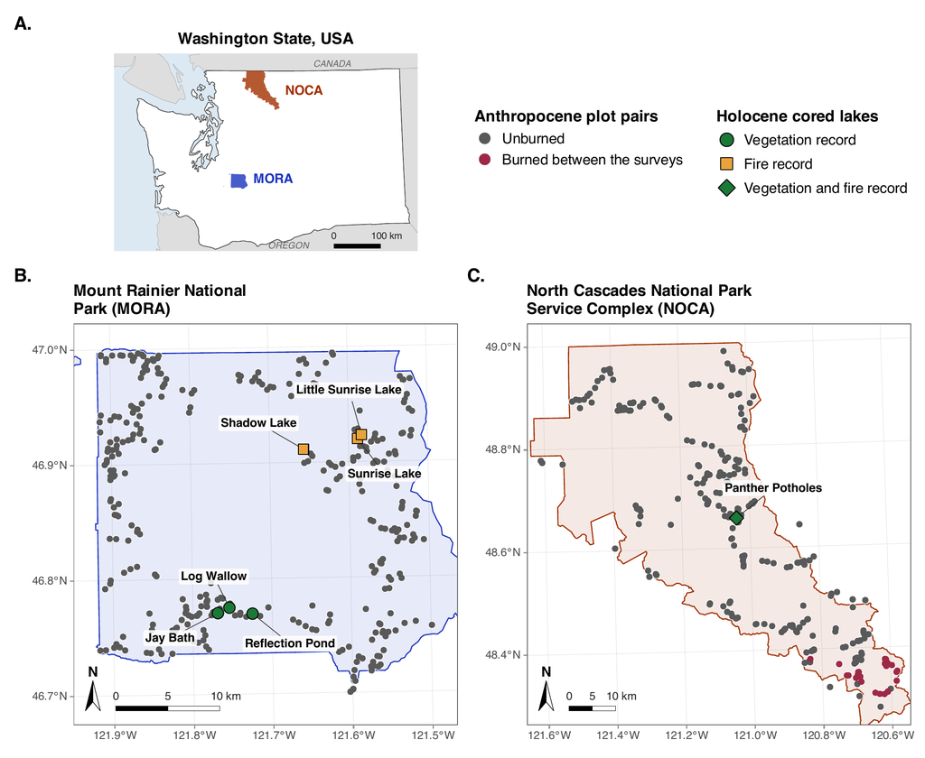

**Fig. 2. Study area.** (A) The two parks in Washington State, USA. (B) Mount Rainier National Park (MORA) and (C) the North Cascades National Park Service Complex (NOCA), which joins the national park with the Ross Lake and Lake Chelan National Recreation Areas. The points are the legacy–resurvey plot pairs that enter the CCA, 328 at MORA and 277 at NOCA. They are grey when unburned and red when burned between the two surveys (0 at MORA and 24 at NOCA). The two MORA plots that burned are left out of the analysis. The large symbols are the cored lakes: vegetation records (green circles, macrofossils, Dunwiddie 1986), fire records (orange squares, charcoal, Walsh et al. 2017) and Panther Potholes, whose core gives both (green diamond, Prichard et al. 2009). The two park maps have the same size and therefore different scales, shown by the same 10 km scale bar on each. Park maps in UTM zone 10N, the Washington map in an equal-area projection. Park boundaries from the National Park Service administrative boundaries, Sunrise Ridge lake coordinates from Walsh et al. (2017, Table 1). Script: `R/figures/main_fig2_study_area.R`.

# Forest tree communities

## Legacy surveys and resurveys

Legacy surveys and resurveys of the same plots at Mount Rainier (MORA) and North Cascades (NOCA) National Parks were matched, cleaned and harmonized to one tree taxonomy (`R/pipeline/01_clean_mora_vegetation.R`, `R/pipeline/02_clean_noca_vegetation.R`).

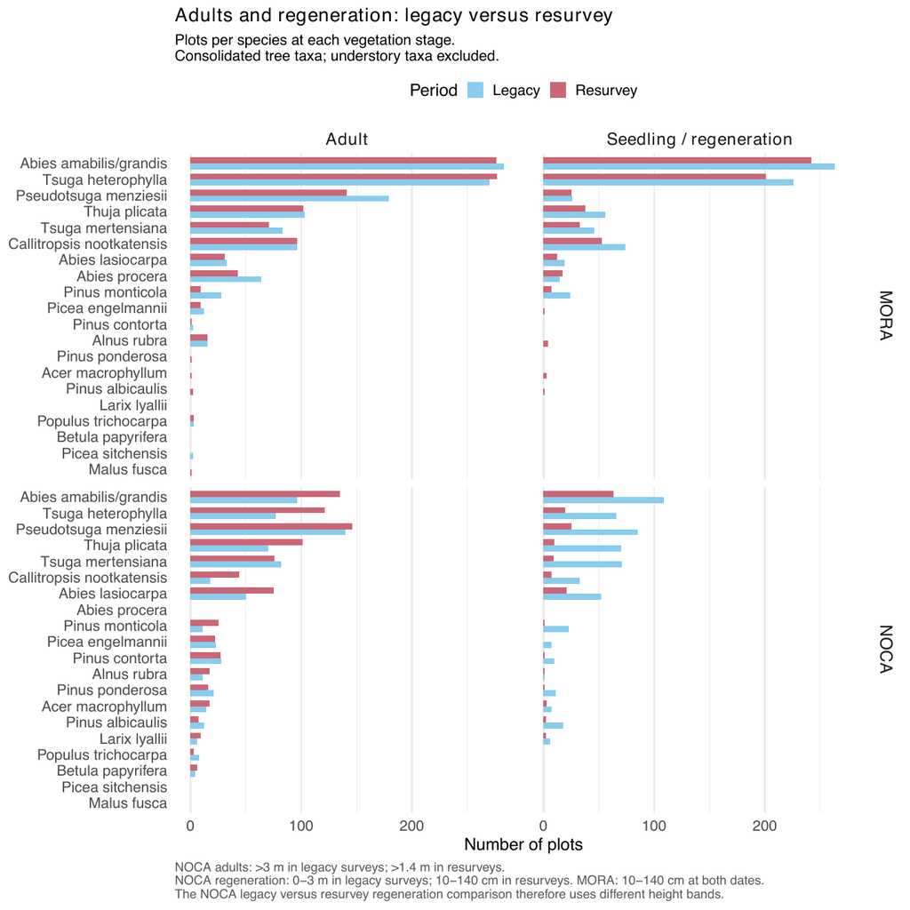

**Fig. S1. Occurrence of tree species as adult trees and as seedlings in the legacy surveys and the resurveys.** Number of plots in which each species was recorded as an adult tree or as a seedling at Mount Rainier (MORA) and North Cascades (NOCA), after taxonomic harmonization and exclusion of understory taxa, but before the selection of species for the CCA. A species could be recorded in both stages in the same plot. At MORA, seedlings were individuals of 10–140 cm height in both surveys. At NOCA, however, the legacy surveys recorded individuals of 0–3 m height as regeneration and taller individuals as adults, whereas the resurveys recorded seedlings of 10–140 cm and adults taller than 1.4 m. Differences between the two stages at NOCA should therefore be interpreted with caution, because the size classes differed between the surveys.

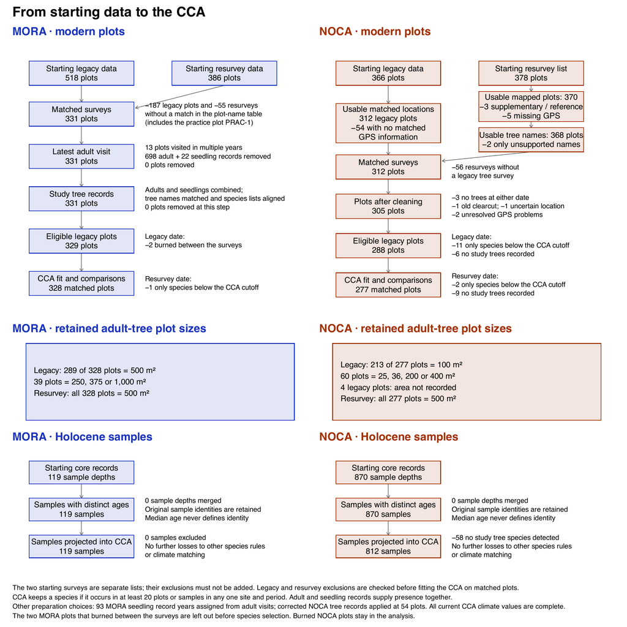

**Fig. S2. Selection of forest plots and macrofossil samples for the canonical correspondence analysis (CCA).** Flowchart of the matching, cleaning, and selection of the plot pairs (legacy survey and resurvey; upper panels) and of the Holocene macrofossil samples (lower panels) at Mount Rainier (MORA, blue) and North Cascades (NOCA, dark red). The plot pairs that remained were used both to fit the CCA (with the legacy surveys) and to quantify community change in the Anthropocene, whereas the Holocene samples were projected into the fitted climate–community space. Plots without any of the retained tree species at one of the two surveys were excluded, because they have no observed position in this space. Sample sizes and reasons for exclusion are given at each step. The middle panels give the plot sizes of the retained plot pairs in each park: the adult-tree plot area of the legacy survey and of the resurvey.

**Legacy plot size at NOCA.** Both parks were resurveyed with 500-m² plots, whereas the legacy plots at NOCA ranged from 25 to 400 m². To test whether the smaller legacy plots missed species, which would be counted as community turnover at the resurvey, we compared species richness, turnover rate, lag, and lag rate among the legacy plot sizes at NOCA (Table S1).

**Table S1. Plot pairs at NOCA by legacy plot size.** Richness is the mean number of the 13 tree species of the analysis that were present in a plot. Turnover rate, lag, and lag rate are means with 95% confidence intervals (t-intervals, no model): the turnover rate and the lag rate in CCA distance per century, and the lag in CCA distance. The single 36-m² plot has no interval.

| Legacy area (m²) | Plots | Richness, legacy | Richness, resurvey | Turnover rate | Lag | Lag rate |
| --- | --- | --- | --- | --- | --- | --- |
| 25 | 37 | 2.89 | 3.05 | 1.741 (1.082 to 2.400) | -0.134 (-0.370 to 0.103) | -0.470 (-1.302 to 0.362) |
| 36 | 1 | 2.00 | 3.00 | 1.728 | -0.498 | -1.812 |
| 100 | 213 | 2.81 | 2.86 | 2.077 (1.834 to 2.321) | -0.041 (-0.119 to 0.038) | -0.140 (-0.416 to 0.136) |
| 200 | 2 | 4.00 | 1.50 | 2.529 (-29.602 to 34.660) | 0.884 (-9.509 to 11.278) | 3.102 (-33.366 to 39.571) |
| 400 | 20 | 2.10 | 2.15 | 2.604 (1.169 to 4.040) | 0.017 (-0.491 to 0.526) | 0.064 (-1.722 to 1.849) |
| not recorded | 4 | 1.50 | 2.00 | 1.657 (-1.614 to 4.928) | 0.325 (-0.185 to 0.834) | 1.171 (-0.675 to 3.016) |
| all NOCA plot pairs | 277 | 2.75 | 2.82 | 2.066 (1.836 to 2.296) | -0.039 (-0.115 to 0.038) | -0.133 (-0.403 to 0.137) |

<sub>Table file: noca_plot_area_responses.csv</sub>

The smallest legacy plots did not hold fewer species than the larger ones (2.89 species per 25-m² plot against 2.81 per 100-m² plot), and their turnover rate was not higher (1.74 against 2.08 CCA distance per century). The confidence intervals of the three most common plot sizes overlapped for all quantities. The Anthropocene results at NOCA therefore do not depend on the small legacy plots.

**Cleaning details →** 01_vegetation_cleaning (plot-by-plot decisions, NOCA tree corrections, survey dates, raw-data provenance).

## Species selection

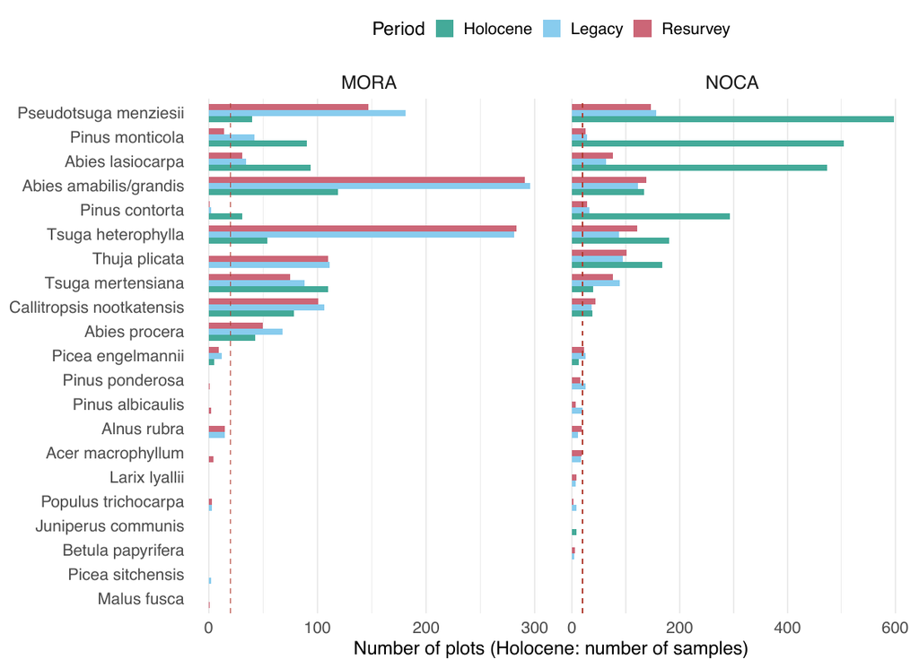

**Fig. S3. Occurrence of tree species in the two parks and the three survey periods, before the selection of species for the CCA.** Number of plots (legacy surveys and resurveys) or macrofossil samples (Holocene) in which each tree species was recorded at MORA and NOCA, after taxonomic harmonization and exclusion of understory and unidentified taxa. A species was counted as present when it was recorded as an adult tree or as a seedling. The dashed red line shows the threshold of 20 plots or samples. We retained the species that reached this threshold in at least one park and period, which gave the 13 species of the CCA.

**The *Abies amabilis/grandis* aggregate.** The needles of *Abies amabilis* and *A. grandis* cannot be told apart, so the macrofossil records cannot separate the two species. In the Panther Potholes record, Prichard et al. (2009) classified them to genus (*Abies* undifferentiated, the *Abies* needles other than *A. lasiocarpa*), and the *A. amabilis* of the MORA records can hold *A. grandis*. We therefore treated the two species as one taxon, *Abies amabilis/grandis*, in both eras and both parks, and aggregated the survey plots in the same way. The aggregate occurs in 134 Panther Potholes samples and 119 MORA samples, and in 296 and 291 MORA plots and 123 and 138 NOCA plots in the legacy surveys and the resurveys.

**Species-selection details →** 05_species_selection (consolidation rules, excluded taxa, occupancy through time).

## Holocene macrofossil records

The Holocene communities come from plant macrofossils in dated lake-sediment cores, three at MORA and one at NOCA (Fig. 2 of the main text). We dated each sample with the age-depth model of its core (Appendix S1).

### Appendix S1. Age-depth models of the Holocene records

#### S1.1 Why new age-depth models were needed

Age-depth models based on calibrated radiocarbon ages were needed for the four cores of the forest records. At MORA, Dunwiddie (1986) reported radiocarbon ages that were not calibrated to calendar years. At NOCA, Prichard et al. (2009) did not publish the age-depth model of Panther Potholes. A Bayesian chronology was later archived in the Neotoma database (Gavin, 2021), with corrected depths of the dates and tephra layers, but without its uncertainty intervals. To make the analysis reproducible, we built a Bayesian age-depth model for each of the four cores with the same method (R package rbacon; Blaauw & Christen, 2011). For the three charcoal records of Sunrise Ridge at MORA (Appendix S3), we used the published age-depth models of Walsh et al. (2017), which are already calibrated.

#### S1.2 Chronological controls

To build the models from the same information as the original studies, we used the published chronological controls of each core, i.e., the depths with a known age: the core surface, radiocarbon dates, tephra layers, and, at Panther Potholes, ²¹⁰Pb ages (Table S2). We entered the radiocarbon ages as uncalibrated ages, which rbacon calibrated with the IntCal20 curve (Reimer et al., 2020), and the other controls as calendar ages. Two decisions differ from the original studies. Reflection Pond has no radiocarbon date of its own, so we gave it the mean basal age of Jay Bath and Log Wallow. For Panther Potholes, we used the depths of the controls archived in the Neotoma database, which correct depth errors in Prichard et al. (2009).

**Table S2. Chronological controls used in the four Bayesian age-depth models.** For cc = 1, the entered age is an uncalibrated ¹⁴C age calibrated with IntCal20. For cc = 0, the entered age is already in calibrated years before present (cal yr BP; present = A.D. 1950).

| Site | Core | Chronological control | Depth (cm) | Age entered ± error | Bacon treatment | Age source | Uncertainty source |
| --- | --- | --- | --- | --- | --- | --- | --- |
| MORA | Jay Bath | Core surface | 0 | −31.5 ± 10 cal yr BP | cc = 0 | Coring date, 1981–1982 | Assumed ±10 yr to account for uncertainty in recovery of the sediment–water interface |
| MORA | Jay Bath | MSH-W tephra | 22 | 470 ± 10 cal yr BP | cc = 0 | Yamaguchi 1983; Walsh et al. 2017 | Assumed ±10 yr around the tree-ring-dated eruption age; no published statistical age error |
| MORA | Jay Bath | QL-1729 | 39.5 | 1320 ± 30 ¹⁴C yr BP | cc = 1, IntCal20 | Dunwiddie 1986 | Published laboratory error |
| MORA | Jay Bath | MR-C tephra | 62 | 2250 ± 100 cal yr BP | cc = 0 | Mullineaux 1974; Walsh et al. 2017 | Assumed ±100 yr; no published statistical age error |
| MORA | Jay Bath | QL-1730 | 70 | 2920 ± 60 ¹⁴C yr BP | cc = 1, IntCal20 | Dunwiddie 1986 | Published laboratory error |
| MORA | Jay Bath | MSH-Y tephra, upper boundary | 87 | 3650 ± 100 cal yr BP | cc = 0 | Mullineaux 1974; Walsh et al. 2017 | ±100 yr derived approximately from radiocarbon dates bracketing the eruption age (bracket half-width ≈103 yr; Mullineaux 1996) |
| MORA | Jay Bath | MSH-Y tephra, lower boundary | 105 | 3650 ± 100 cal yr BP | cc = 0 | Mullineaux 1974; Walsh et al. 2017 | Same uncertainty as upper boundary; both depths represent the same instantaneous tephra deposit |
| MORA | Jay Bath | Beta-6332 | 124.5 | 3740 ± 80 ¹⁴C yr BP | cc = 1, IntCal20 | Dunwiddie 1986 | Published laboratory error |
| MORA | Jay Bath | MR-F tephra | 142 | 5740 ± 100 cal yr BP | cc = 0 | Mullineaux 1974; Walsh et al. 2017 | Assumed ±100 yr; no published statistical age error |
| MORA | Jay Bath | QL-1704 | 152.25 | 6050 ± 110 ¹⁴C yr BP | cc = 1, IntCal20 | Dunwiddie 1986 | Published laboratory error |
| MORA | Log Wallow | Core surface | 0 | −31.5 ± 10 cal yr BP | cc = 0 | Coring date, 1981–1982 | Assumed ±10 yr to account for uncertainty in recovery of the sediment–water interface |
| MORA | Log Wallow | MSH-W tephra | 22 | 470 ± 10 cal yr BP | cc = 0 | Yamaguchi 1983; Walsh et al. 2017 | Assumed ±10 yr around the tree-ring-dated eruption age; no published statistical age error |
| MORA | Log Wallow | QL-1726 | 29 | 1650 ± 80 ¹⁴C yr BP | cc = 1, IntCal20 | Dunwiddie 1986 | Published laboratory error |
| MORA | Log Wallow | MSH-Y tephra, upper boundary | 40 | 3650 ± 100 cal yr BP | cc = 0 | Mullineaux 1974; Walsh et al. 2017 | ±100 yr derived approximately from radiocarbon dates bracketing the eruption age (bracket half-width ≈103 yr; Mullineaux 1996) |
| MORA | Log Wallow | MSH-Y tephra, lower boundary | 98 | 3650 ± 100 cal yr BP | cc = 0 | Mullineaux 1974; Walsh et al. 2017 | Same uncertainty as upper boundary; both depths represent the same instantaneous tephra deposit |
| MORA | Log Wallow | MR-F tephra | 116 | 5740 ± 100 cal yr BP | cc = 0 | Mullineaux 1974; Walsh et al. 2017 | Assumed ±100 yr; no published statistical age error |
| MORA | Log Wallow | QL-1727 | 117 | 4900 ± 80 ¹⁴C yr BP | cc = 1, IntCal20 | Dunwiddie 1986 | Published laboratory error |
| MORA | Log Wallow | QL-1728 | 140 | 5980 ± 60 ¹⁴C yr BP | cc = 1, IntCal20 | Dunwiddie 1986 | Published laboratory error |
| MORA | Reflection Pond | Core surface | 0 | −31.5 ± 10 cal yr BP | cc = 0 | Coring date, 1981–1982 | Assumed ±10 yr to account for uncertainty in recovery of the sediment–water interface |
| MORA | Reflection Pond | MSH-W tephra | 10 | 470 ± 10 cal yr BP | cc = 0 | Yamaguchi 1983; Walsh et al. 2017 | Assumed ±10 yr around the tree-ring-dated eruption age; no published statistical age error |
| MORA | Reflection Pond | MR-C tephra | 26 | 2250 ± 100 cal yr BP | cc = 0 | Mullineaux 1974; Walsh et al. 2017 | Assumed ±100 yr; no published statistical age error |
| MORA | Reflection Pond | MSH-Y tephra, upper boundary | 45 | 3650 ± 100 cal yr BP | cc = 0 | Mullineaux 1974; Walsh et al. 2017 | ±100 yr derived approximately from radiocarbon dates bracketing the eruption age (bracket half-width ≈103 yr; Mullineaux 1996) |
| MORA | Reflection Pond | MSH-Y tephra, lower boundary | 64 | 3650 ± 100 cal yr BP | cc = 0 | Mullineaux 1974; Walsh et al. 2017 | Same uncertainty as upper boundary; both depths represent the same instantaneous tephra deposit |
| MORA | Reflection Pond | MR-F tephra | 82 | 5740 ± 100 cal yr BP | cc = 0 | Mullineaux 1974; Walsh et al. 2017 | Assumed ±100 yr; no published statistical age error |
| MORA | Reflection Pond | Basal sediment, mean of QL-1704 and QL-1728 | 90 | 6015 ± 110 ¹⁴C yr BP | cc = 1, IntCal20 | Dunwiddie 1986; P. Dunwiddie, pers. comm. | Larger of the two laboratory errors (±110 yr), allowing for transfer of the Jay Bath and Log Wallow basal age to Reflection Pond |
| NOCA | Panther Potholes | Core surface | 0.5 | −49 ± 1 cal yr BP | cc = 0 | Gavin 2021 Neotoma chronology; coring year 1999 | ±1 yr retained from the archived chronology |
| NOCA | Panther Potholes | ²¹⁰Pb CRS age | 7 | −36.7; error entered = 3.47 | cc = 0 | Prichard et al. 2009; Gavin 2021 | Value of the archived chronology; 3.47 is numerically the published ²¹⁰Pb activity uncertainty in DPM g⁻¹, not a verified age error in years |
| NOCA | Panther Potholes | ²¹⁰Pb CRS age | 14 | −9; error entered = 1.15 | cc = 0 | Prichard et al. 2009; Gavin 2021 | Value of the archived chronology; 1.15 is numerically the published ²¹⁰Pb activity uncertainty in DPM g⁻¹, not a verified age error in years |
| NOCA | Panther Potholes | ²¹⁰Pb CRS age | 21 | 12; error entered = 0.72 | cc = 0 | Prichard et al. 2009; Gavin 2021 | Value of the archived chronology; 0.72 is numerically the published ²¹⁰Pb activity uncertainty in DPM g⁻¹, not a verified age error in years |
| NOCA | Panther Potholes | ²¹⁰Pb CRS age | 28 | 21; error entered = 0.74 | cc = 0 | Prichard et al. 2009; Gavin 2021 | Value of the archived chronology; 0.74 is numerically the published ²¹⁰Pb activity uncertainty in DPM g⁻¹, not a verified age error in years |
| NOCA | Panther Potholes | ²¹⁰Pb CRS age | 35 | 36; error entered = 0.77 | cc = 0 | Prichard et al. 2009; Gavin 2021 | Value of the archived chronology; 0.77 is numerically the published ²¹⁰Pb activity uncertainty in DPM g⁻¹, not a verified age error in years |
| NOCA | Panther Potholes | Beta-172005, conifer seed | 214 | 1950 ± 50 ¹⁴C yr BP | cc = 1, IntCal20 | Prichard et al. 2009 | Published laboratory error |
| NOCA | Panther Potholes | MSH-P tephra | 305.5 | 2620 ± 70 cal yr BP | cc = 0 | Gavin 2021 Neotoma chronology | Age and ±70-yr uncertainty retained from the archived chronology |
| NOCA | Panther Potholes | Beta-169623, seed | 363 | 3260 ± 40 ¹⁴C yr BP | cc = 1, IntCal20 | Prichard et al. 2009 | Published laboratory error |
| NOCA | Panther Potholes | Beta-169624, pollen cone | 389 | 3520 ± 40 ¹⁴C yr BP | cc = 1, IntCal20 | Prichard et al. 2009 | Published laboratory error |
| NOCA | Panther Potholes | MSH-Y tephra | 401 | 3660 ± 65 cal yr BP | cc = 0 | Gavin 2021 Neotoma chronology | Age and ±65-yr uncertainty retained from the archived chronology |
| NOCA | Panther Potholes | Beta-169207, pollen cone | 479 | 4500 ± 40 ¹⁴C yr BP | cc = 1, IntCal20 | Prichard et al. 2009 | Published laboratory error |
| NOCA | Panther Potholes | Mazama tephra | 629 | 7633 ± 25 cal yr BP | cc = 0 | Gavin 2021 Neotoma chronology; Egan et al. 2015 | Age and ±25-yr uncertainty retained from the archived chronology |
| NOCA | Panther Potholes | Beta-169208, seed | 678 | 7330 ± 40 ¹⁴C yr BP | cc = 1, IntCal20 | Prichard et al. 2009 | Published laboratory error |
| NOCA | Panther Potholes | Beta-169625, Pinus contorta needles | 864 | 9370 ± 40 ¹⁴C yr BP | cc = 1, IntCal20 | Prichard et al. 2009 | Published laboratory error |

<sub>Table file: chronological_controls.csv</sub>

#### S1.3 Age-depth models

To estimate the age of every depth between the controls, rbacon models how fast sediment accumulated along the core and returns many age-depth curves that agree with the controls (Fig. S4; settings in Table S3). The three MORA cores had no Bayesian chronology before, and we used the same settings for all three, mostly the rbacon defaults. For Panther Potholes, we used the settings of the Bacon chronology archived in Neotoma (Gavin, 2021), so that our model reproduces that chronology and also gives its uncertainty intervals. We treated thick tephra layers as instantaneous deposits (grey bands in Fig. S4). From each model, we took the median of the modelled ages at the depth of each macrofossil sample as the age of that sample, and used it to assign the sample to a century (see Methods of the main text).

**Table S3. rbacon parameters used to construct the age-depth models.**

| rbacon argument | What it controls | MORA | Panther Potholes | Rationale |
| --- | --- | --- | --- | --- |
| cc, cc1 | Determines whether a date requires radiocarbon calibration and which calibration curve is used | cc=1, cc1=“IntCal20” for ¹⁴C dates; cc=0 for calendar-age controls | Same | We calibrated the ¹⁴C dates with IntCal20, the curve for Northern Hemisphere terrestrial samples, and entered the other controls as calendar ages. |
| thick | Thickness of the sediment sections for which accumulation rates are estimated | 5 cm | 5 cm | rbacon default; at Panther Potholes, also the value of the archived chronology. |
| acc.mean | Mean of the prior distribution for accumulation time, in yr cm⁻¹ | 50 | 10 | The MORA cores accumulated more slowly. At Panther Potholes, the value of the archived chronology, close to the accumulation of about 12.8 yr cm⁻¹ reported for this core. |
| acc.shape | Shape of the gamma prior around acc.mean; larger values impose a more concentrated accumulation prior | 1.5 | 1.5 | rbacon default (MORA); value of the archived chronology (Panther Potholes). |
| mem.mean | Prior mean dependence between accumulation rates in adjacent sediment sections | 0.5 | 0.7 | rbacon default (MORA); value of the archived chronology (Panther Potholes). |
| mem.strength | Strength of the prior around mem.mean; larger values impose the assumed memory more strongly | 10 | 10 | rbacon default (MORA); value of the archived chronology (Panther Potholes). |
| slump | Depth intervals treated as effectively instantaneous accumulation rather than gradual sedimentation | Jay Bath: 87–105 cm; Log Wallow: 40–98 cm; Reflection Pond: 45–64 cm | 303–308, 396–406, and 623–635 cm | Treats each thick tephra layer as one instantaneous deposit, so that the model does not read its thickness as a long period of accumulation. |
| normal, t.a, t.b | Distribution used to accommodate chronological-control scatter and potential outlying dates | FALSE, 3, 4 | FALSE, 15, 16 | rbacon default (MORA); value of the archived chronology (Panther Potholes). |
| ssize | Number of MCMC iterations retained for the posterior | 4,000 | 10,000 | rbacon default (MORA). Panther Potholes needed more iterations for the chain to mix and to reproduce the archived chronology. |
| prob | Posterior interval reported for the chronology | 0.95 | 0.95 | We summarize ages with 95% posterior intervals. |
| d.max | Maximum core depth included in the model | Jay Bath: 153 cm; no manual extension for Log Wallow or Reflection Pond | 870 cm | We extended Jay Bath to 153 cm to keep its deepest macrofossil sample. At Panther Potholes, the extent of the archived chronology. |

<sub>Table file: rbacon_parameters.csv</sub>

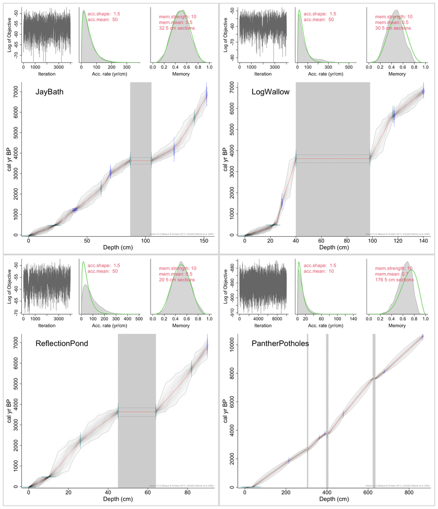

**Fig. S4. Bayesian age-depth models of the four cores of the forest records: Jay Bath, Log Wallow, and Reflection Pond at MORA, and Panther Potholes at NOCA.** Coloured distributions show the chronological controls, the grey field the modelled age-depth curves, the red dotted line their mean, and the grey dotted lines their 95% interval. Grey bands mark the tephra layers treated as instantaneous deposits. Ages are in calibrated years before present. The small upper panels are the standard rbacon diagnostics.

#### S1.4 Check of the ²¹⁰Pb errors at Panther Potholes

In the archived chronology of Panther Potholes, the errors given for the five ²¹⁰Pb ages are the uncertainties of the measured ²¹⁰Pb activity, not age errors in years. To check whether this matters, we fitted a second model with an error of ±10 years for these five ages. The two chronologies differed only in the upper 35 to 40 cm of the core, which is much younger than the youngest lake-period of the analysis (1400 cal BP), so this choice does not affect the results (Fig. S5).

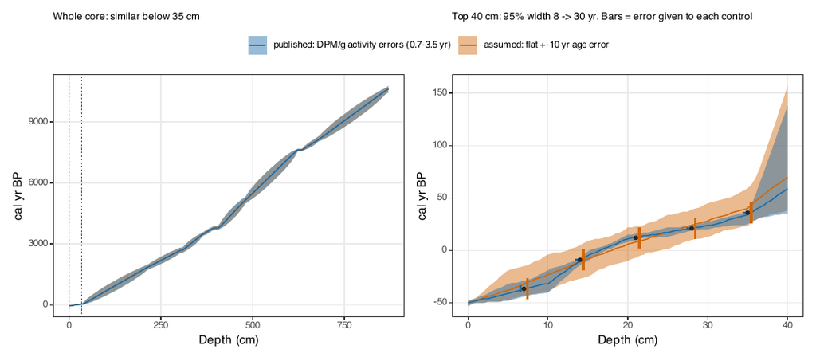

**Fig. S5. Check of the Panther Potholes age-depth chronology to uncertainty assigned to the five ²¹⁰Pb controls in the upper 35 to 40 cm of the core.** The left panel shows that the two posterior chronologies are nearly identical below the ²¹⁰Pb-dated section, whereas the right panel shows the expected increase in uncertainty within the upper 35–40 cm. The uncertainty assigned to the ²¹⁰Pb controls affects the precision of the most recent chronology but does not materially alter the deeper Holocene chronology used in our analyses.

**Chronology details →** 03_chronology (every control and its source).

# Climate products

## Appendix S2. Climate products and the bias correction of the Holocene climate

We fitted the climate–community space with CHELSA V2.1 at the forest plots, whereas the climate-predicted positions of the Holocene communities come from CHELSA-TraCE21k at the lakes. If the two products differ in the level of temperature or precipitation, a Holocene climate is placed elsewhere in the climate–community space than the same climate would be with CHELSA V2.1, and this difference enters every mismatch and every lag. We therefore corrected the Holocene climate to the level of CHELSA V2.1.

To correct it, we followed the change-factor approach that is commonly used for paleoclimate simulations (Lorenz et al., 2016): the difference between two products is calculated over the years that they have in common, and is then applied to all time steps of the product to be corrected. CHELSA-TraCE21k and CHELSA V2.1 cannot be compared directly, because the most recent time step of CHELSA-TraCE21k is the mean of the years 1900 to 1990, whereas CHELSA V2.1 starts in 1979. We therefore used CHELSAcruts (1901 to 2016), which has years in common with both products, as a link between them (Table S4). Over the years that the three products have in common, they differed in the level of temperature and precipitation (Fig. S6).

**Table S4. The three CHELSA products.** All three products have the same grid of 30 arcsec.

| Product | Version | Years read | What it is |
| --- | --- | --- | --- |
| CHELSA-TraCE21k | 1.0 | timeIDs 16 to 20 (1500 to 1990, century means) | Downscaled TraCE-21k transient simulation; timeID 20 is the mean of 1900 to 1990 |
| CHELSAcruts | 1.0 | 1901 to 2016, monthly | CRU TS anomalies downscaled with the CHELSA V1 climatology |
| CHELSA V2.1 | 2.1 | 1979 to 2021, monthly | CHELSA time series, current version; the climate of the climate–community space |

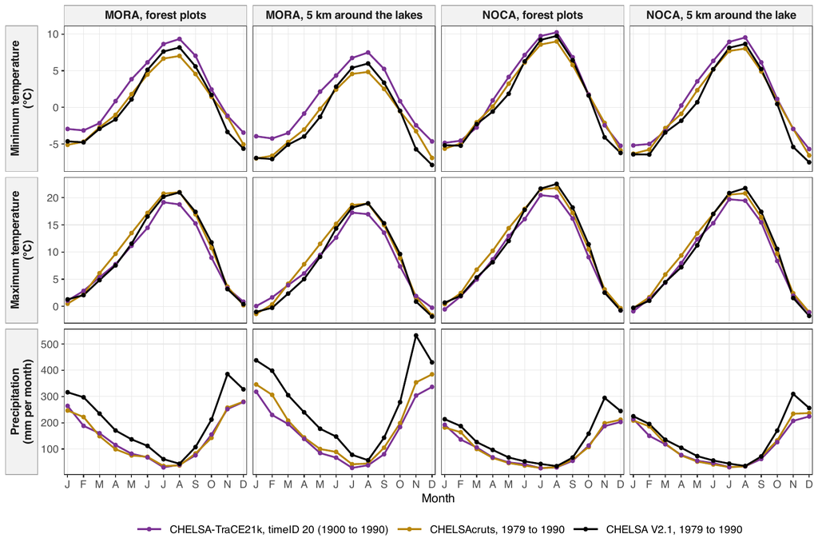

**Fig. S6. The three climate products of the bias correction, without correction.** Monthly minimum temperature, maximum temperature, and precipitation over the years that the three products have in common: the most recent time step of CHELSA-TraCE21k (timeID 20, the mean of 1900 to 1990; purple), and CHELSAcruts (gold) and CHELSA V2.1 (black) over 1979 to 1990. For each point, the values of CHELSAcruts and CHELSA V2.1 were averaged over these years. Each line is the median over the forest plots of a park (331 at MORA and 305 at NOCA) or over the grid cells within 5 km of its lakes (136 at MORA and 136 at NOCA). CHELSA V2.1 has no temperature for January 1979, so that its January temperatures are means over 1980 to 1990. Script: `R/figures/supp_climate_products.R`; medians in `climate_products_point_medians.csv` of `R/pipeline/07_climate_products.R`.

The correction thus has two steps (Fig. S7). In step 1, we corrected CHELSA-TraCE21k to CHELSAcruts over 1900 to 1990, and in step 2, CHELSAcruts to CHELSA V2.1 over 1979 to 2016. For each park and calendar month, each step is an offset that we added to minimum and maximum temperature, and a ratio by which we multiplied precipitation. We calculated both steps from the mean over the grid cells within 5 km of the lakes of each park, and applied them to all time steps of CHELSA-TraCE21k. Step 1 was needed because CHELSA-TraCE21k and CHELSAcruts did not agree over the years that they have in common, although both are downscaled with the same method (Table S5). Scripts: `R/pipeline/07_climate_products.R`, `R/pipeline/08_paleo_climate.R`. The factors of every park, variable and month are written to `climate_bias_correction_factors.csv`. **Climate details →** 02_climate.

This correction assumes that the difference between the products stayed constant through the Holocene. As a sensitivity analysis, we therefore repeated all analyses without correction (Appendix S4).

**Table S5. Comparison of CHELSA-TraCE21k and CHELSAcruts over the years that they have in common, without correction.** The most recent time step of CHELSA-TraCE21k (timeID 20, the mean of 1900 to 1990) and CHELSAcruts (1901 to 1990), on the grid cells within 5 km of the lakes (disc), at the grid cells of the lakes (MORA: mean of the three lakes), and as the mean over the forest plots. Difference: CHELSAcruts subtracted from CHELSA-TraCE21k. Ratio: CHELSA-TraCE21k divided by CHELSAcruts.

| Park | Place | Variable | TraCE21k timeID 20 | CHELSAcruts 1901-1990 | Difference | Ratio |
| --- | --- | --- | --- | --- | --- | --- |
| MORA | MORA disc | Spring temperature (°C) | 2.87 | 2.07 | 0.80 | 1.39 |
| MORA | MORA disc | Summer precipitation (mm) | 135.57 | 161.50 | -25.94 | 0.84 |
| MORA | MORA lakes | Spring temperature (°C) | 3.40 | 2.78 | 0.62 | 1.22 |
| MORA | MORA lakes | Summer precipitation (mm) | 128.00 | 167.13 | -39.13 | 0.77 |
| MORA | MORA plots | Spring temperature (°C) | 4.45 | 4.18 | 0.27 | 1.07 |
| MORA | MORA plots | Summer precipitation (mm) | 140.26 | 140.02 | 0.24 | 1.00 |
| NOCA | NOCA disc | Spring temperature (°C) | 4.05 | 3.73 | 0.32 | 1.08 |
| NOCA | NOCA disc | Summer precipitation (mm) | 112.85 | 95.13 | 17.72 | 1.19 |
| NOCA | NOCA lakes | Spring temperature (°C) | 4.20 | 3.96 | 0.24 | 1.06 |
| NOCA | NOCA lakes | Summer precipitation (mm) | 101.00 | 108.26 | -7.26 | 0.93 |
| NOCA | NOCA plots | Spring temperature (°C) | 4.52 | 4.37 | 0.14 | 1.03 |
| NOCA | NOCA plots | Summer precipitation (mm) | 105.26 | 88.80 | 16.46 | 1.19 |

<sub>Table file: appendix_s2_trace_cruts_check.csv</sub>

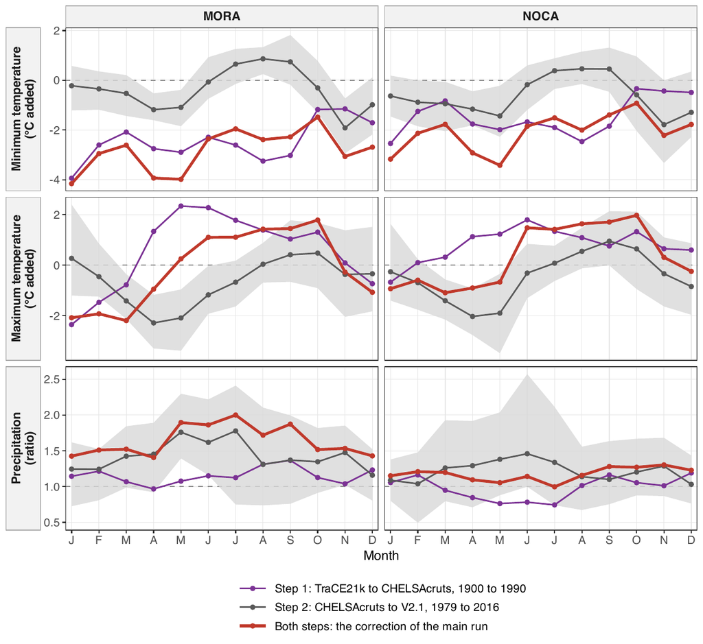

**Fig. S7. The two steps of the bias correction of the Holocene climate.** For each park and calendar month, the offset added to temperature (°C) or the ratio by which precipitation was multiplied, calculated on the grid cells within 5 km of the lakes. Purple: step 1 (CHELSA-TraCE21k to CHELSAcruts, 1900 to 1990). Grey: step 2 (CHELSAcruts to CHELSA V2.1, 1979 to 2016), with the 10th to 90th percentile of the yearly values in light grey. Red: both steps together, i.e., the correction of the main analysis. On the dashed line, a step changes nothing. Script: `R/figures/supp_climate_products.R`.

# Climate change and comparisons within eras

## Climate data

Modern climate is CHELSA V2.1 monthly climate in a survey-specific window for every plot (`R/pipeline/04_modern_climate.R`). Holocene climate is CHELSA-TraCE21k at each lake and century, bias-corrected onto CHELSA V2.1 (Appendix S2; `R/pipeline/08_paleo_climate.R`).

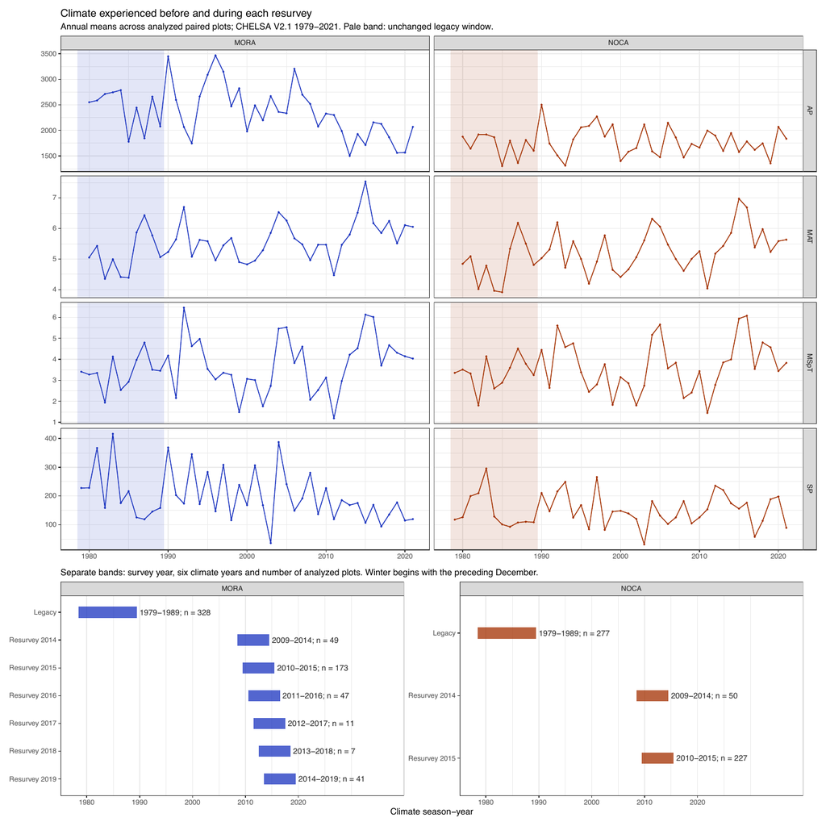

**Fig. S8. Climate of the Anthropocene and the climate windows of the surveys.** Upper panels: annual climate from CHELSA V2.1 (1979–2021), averaged over the plot pairs at Mount Rainier (MORA, blue) and North Cascades (NOCA, dark red), for mean annual temperature (MAT), annual precipitation (AP), mean spring temperature (MSpT), and summer precipitation (SP). Spring temperature and summer precipitation are the two variables of the climate–community space. The shaded area shows the climate window of the legacy surveys (1979–1989), which is the same for all plots. Lower panels: the six-year climate window of each resurvey year (from five years before the resurvey to the year of the resurvey), with the number of plot pairs (n) resurveyed in that year. The climate of the resurvey was therefore calculated separately for each plot, according to the year of its resurvey. CHELSA V2.1 is the product to which the Holocene climate was corrected (Appendix S2), and is itself not corrected.

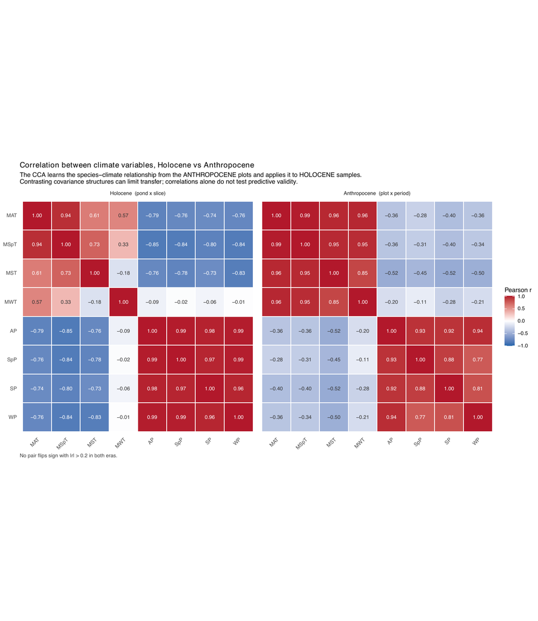

**Fig. S9. Correlations among climate variables in the Holocene and the Anthropocene.** Pearson correlation coefficients (r) across lakes and centuries for the Holocene (CHELSA-TraCE21k after the bias correction of Appendix S2, left), and across forest plots and surveys for the Anthropocene (CHELSA V2.1, right). Red shows positive and blue negative correlations, and the numbers give r. The variables are mean annual (MAT), spring (MSpT), summer (MST), and winter (MWT) temperature, and annual (AP), spring (SpP), summer (SP), and winter (WP) precipitation. Spring is March–May, summer June–August, and winter December–February.

**Climate details →** 02_climate (survey windows, TraCE21k against V2.1, full correlation tables).

## Climate periods

**What and why.** The Holocene is cut into climate-change (C) periods, when the park-average climate of the lakes moved steadily in one direction, and stability (S) periods between them. The rules of the climate-era step are unchanged. Only their input changed: the periods are now drawn from the two CCA variables, MSpT and SP, so that the periods describe change along the same climate axes that the CCA uses. A climate-change period that contains a long internal trough of low change is split into sub-periods (a, b, c). Each period, or sub-period, is one unit for the lake-periods (see Climate–community lags).

**Result.**

**Table S6. Climate periods of the Holocene.** Climate-change (C) and stability (S) periods defined from spring temperature (MSpT) and summer precipitation (SP), which are used in the analysis, and, with the same rules, from the four seasonal variables, for comparison. Both are defined from the Holocene climate after the bias correction (Appendix S2). Drivers: the variables whose change defined a climate-change period.

| Variables | Period | Type | Older (cal BP) | Younger (cal BP) | Duration (years) | Drivers |
| --- | --- | --- | --- | --- | --- | --- |
| Spring temperature and summer precipitation (used) | C1 | Holocene-C | 9650 | 8650 | 1000 | spring cooling, summer drying |
| Spring temperature and summer precipitation (used) | S1 | Holocene-S | 8650 | 8250 | 400 |  |
| Spring temperature and summer precipitation (used) | C2 | Holocene-C | 8250 | 7250 | 1000 | spring warming, summer wetting |
| Spring temperature and summer precipitation (used) | S2 | Holocene-S | 7250 | 6850 | 400 |  |
| Spring temperature and summer precipitation (used) | C3 | Holocene-C | 6850 | 6250 | 600 | spring cooling |
| Spring temperature and summer precipitation (used) | S3 | Holocene-S | 6250 | 5450 | 800 |  |
| Spring temperature and summer precipitation (used) | C4 | Holocene-C | 5450 | 4950 | 500 | spring warming |
| Spring temperature and summer precipitation (used) | S4 | Holocene-S | 4950 | 2250 | 2700 |  |
| Spring temperature and summer precipitation (used) | C5 | Holocene-C | 2250 | 1750 | 500 | spring warming |
| Spring temperature and summer precipitation (used) | S5 | Holocene-S | 1750 | 1350 | 400 |  |
| Four seasonal variables (comparison) | C1a | Holocene-C | 9650 | 8650 | 1000 | spring cooling, winter warming, summer drying |
| Four seasonal variables (comparison) | C1b | Holocene-C | 8650 | 8250 | 400 | winter wetting |
| Four seasonal variables (comparison) | C1c | Holocene-C | 8250 | 7250 | 1000 | spring warming, winter warming, summer wetting |
| Four seasonal variables (comparison) | S1 | Holocene-S | 7250 | 6850 | 400 |  |
| Four seasonal variables (comparison) | C2 | Holocene-C | 6850 | 6250 | 600 | spring cooling |
| Four seasonal variables (comparison) | S2 | Holocene-S | 6250 | 5450 | 800 |  |
| Four seasonal variables (comparison) | C3 | Holocene-C | 5450 | 4950 | 500 | spring warming |
| Four seasonal variables (comparison) | S3 | Holocene-S | 4950 | 2250 | 2700 |  |
| Four seasonal variables (comparison) | C4 | Holocene-C | 2250 | 1750 | 500 | spring warming |
| Four seasonal variables (comparison) | S4 | Holocene-S | 1750 | 1350 | 400 |  |

<sub>Table file: step1_periods.csv</sub>

With MSpT and SP the Holocene from 9650 to 1350 cal BP falls into 5 climate-change periods and 5 stability periods, and no climate-change period is split. The first four-variable climate-change period (C1a to C1c, 9650 to 7250 cal BP) becomes C1, S1 and C2: its middle part (8650 to 8250 cal BP) was driven by winter wetting alone, which is no longer a constraint. From 7250 cal BP onward every boundary is unchanged, and the periods are renumbered.

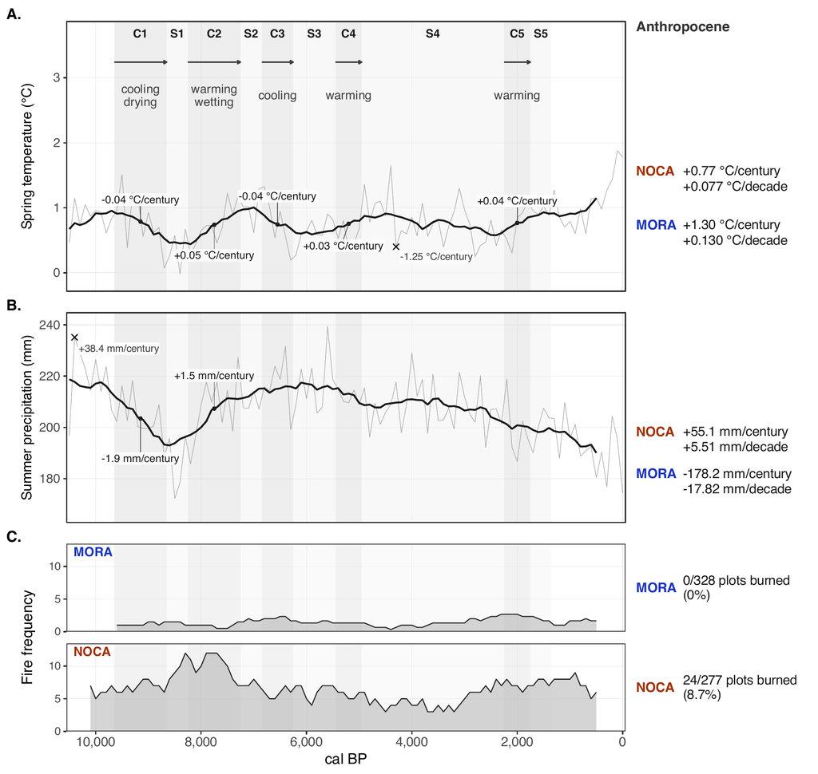

**Fig. 3. Holocene climate and fire.** (A) Spring temperature (°C) and (B) summer precipitation (mm), the two CCA constraints, averaged over the lakes of each park with the two parks weighted equally (CHELSA-TraCE21k after the bias correction of Appendix S2). Bold lines are 1,000-year running means and thin lines the centennial series. Shading marks the climate-change (C) and stability (S) periods, with the change that drove each climate-change period written below its name (cooling or warming of spring temperature, drying or wetting of summer precipitation). Labels linked to the bold lines give the change per century over a period for each variable that drove it. A cross marks the largest step between two consecutive centuries, labelled with its rate. To the right of each panel, the Anthropocene change per century, and beneath it per decade, from the legacy to the resurvey climate window, the median over plots in each park: spring temperature +1.30 °C per century at MORA and +0.77 °C per century at NOCA, summer precipitation -178.2 mm per century at MORA and +55.1 mm per century at NOCA. These come from a change over about 29 years, while each Holocene rate spans a whole period of 400 to 2,700 years. (C) Fire frequency of each park: accepted fire events per 1,000 years, counted in a 1,000-year window centred every 100 years. At MORA it is the mean of the three Sunrise Ridge cores of Walsh et al. (2017) wherever at least two cover the date, at NOCA the Panther Potholes core (Prichard et al. 2009). The two parks share one y axis, but their frequencies are not directly comparable: Panther Potholes is resampled every 12 years and the Sunrise Ridge cores every 42 to 48 years, and a finer record resolves more events, so part of the gap between the parks comes from the records. The MORA cores lie on Sunrise Ridge, away from the vegetation lakes (Fig. S13). The models do not use this curve: their fire activity counts the same accepted events between the two ends of each lake-period, per century and per covered core (see Climate–community lags). To the right, the Anthropocene plot pairs of each park that burned between the two surveys (MORA’s two burned plots are left out of the analysis).

Stages and helpers: `R/pipeline/12_climate_eras_fire_frequency.R`, `R/helpers/holocene_climate_fire_era_functions.R`, `R/figures/main_fig3_climate_eras_fire.R`.

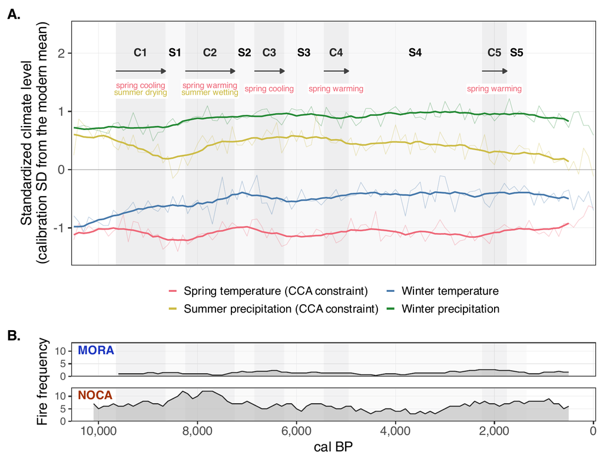

**Fig. S10. Holocene climate for the four seasonal variables.** (A) Standardized levels, in standard deviations of the legacy plots from their mean, of spring temperature, winter temperature, summer precipitation, and winter precipitation: 1,000-year running means (bold) and the centennial series (thin), averaged over the lakes of each park with the two parks weighted equally. The Holocene climate is CHELSA-TraCE21k after the bias correction (Appendix S2). Only spring temperature and summer precipitation are used in the climate–community space and define the climate periods. (B) Fire frequency as in Fig. 3C of the main text.

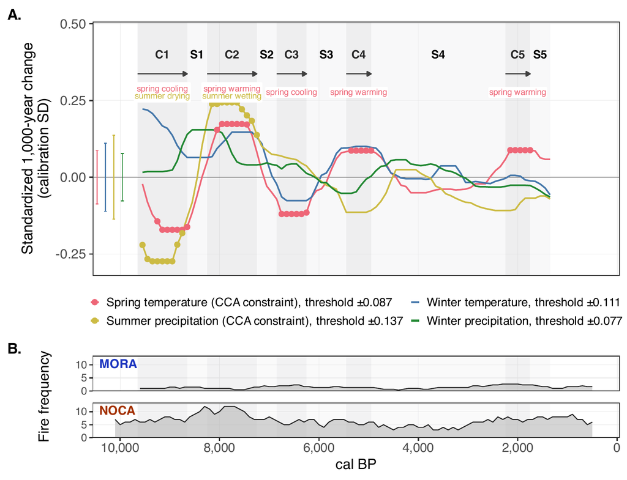

**Fig. S11. How the climate periods were defined.** (A) Change of each of the four seasonal variables over 1,000 years (Holocene climate after the bias correction of Appendix S2), with its sign, as the mean of the two parks (weighted equally), taken as the median over the ten phases of the 1,000-year bins, and standardized by the standard deviation across the legacy plots. Filled points mark the time steps at which one of the two variables of the climate–community space changed in one direction (more than 50% of the maximum change of the variable, with at least 8 of 10 phases in the same direction). We defined the climate periods from these points. Winter temperature and winter precipitation are shown for comparison. Brackets on the left mark the stability range of each variable, whose threshold is given in the legend. (B) Fire frequency as in Fig. 3C of the main text.

# Fire dynamics

## Appendix S3. Fire histories of the Holocene

### S3.1 Charcoal records

To describe fire activity through the Holocene in each park, we used published records of macroscopic charcoal in lake sediments: Sunrise Lake, Shadow Lake, and Little Sunrise Lake at MORA (Walsh et al., 2017), and Panther Potholes at NOCA (Prichard et al., 2009). At MORA, these records come from Sunrise Ridge and not from the lakes of the forest records (see S3.5). At NOCA, the fire record and the forest record come from the same core and have the same chronology (Appendix S1).

### S3.2 Fire events

To identify fire events in the same way in the four records, we repeated the peak detection of the two original studies in one workflow (R package tapas), with the settings of each original study (Table S7). In this workflow, a fire event is a peak in the charcoal accumulation rate that exceeds the background noise of the record and passes a minimum-count test (Fig. S12). Script: `R/pipeline/09_fire_records.R`.

**Table S7. Parameters used to reconstruct individual Holocene fire events.** All records were also screened with the same 75-year minimum-count test (p ≤ 0.05). MORA settings follow Walsh et al. (2017) and Panther Potholes settings Prichard et al. (2009), except its 12-year interpolation interval, the median resolution of our updated chronology.

| Site | Fire record | Interpolation interval (years) | Background window (years) | Peak threshold | Accepted fire events |
| --- | --- | --- | --- | --- | --- |
| MORA | Sunrise Lake | 48 | 800 | 95% | 17 |
| MORA | Shadow Lake | 47 | 1000 | 95% | 14 |
| MORA | Little Sunrise Lake | 42 | 500 | 95% | 13 |
| NOCA | Panther Potholes | 12 | 500 | 99% | 70 |

<sub>Table file: fire_detection_parameters.csv</sub>

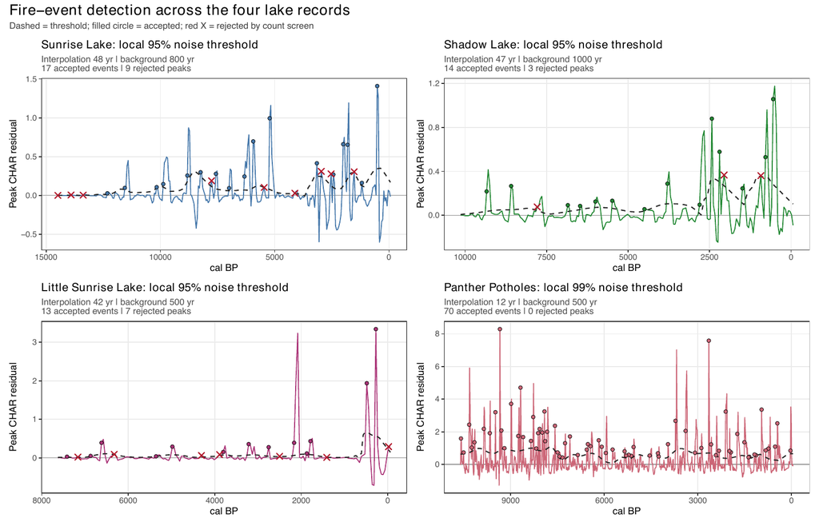

**Fig. S12. Identification of Holocene fire events in the four records.** The residual peak component is the difference between interpolated charcoal accumulation rates (CHAR) and the background estimated with the record’s robust LOWESS window. Candidate events exceed the local noise threshold (dashed line) and are then screened with a 75-year minimum-count test (p ≤ 0.05): filled circles are accepted events, and red crosses are rejected candidates.

### S3.3 Fire frequency

To show how fire activity changed through the Holocene (Fig. 3C of the main text), we counted the fire events of each record in windows of 1,000 years, moved in steps of 100 years. The MORA series is the mean of the three Sunrise Ridge records, and the NOCA series is the Panther Potholes record. The records differ in resolution, so that fire frequencies cannot be compared between the parks. Note that the models do not use this fire frequency, but the number of fire events between t1 and t2 of each lake-period (see Methods of the main text). Script: `R/pipeline/12_climate_eras_fire_frequency.R`.

### S3.4 Comparison with the original studies

To check the workflow, we compared the numbers of fire events that we identified with those of the original studies, and repeated the analysis of the MORA records with a second software (CharAnalysis; Table S8). The numbers differed from the published ones, also with CharAnalysis, which suggests that part of the difference comes from the software. We kept one workflow for the four records, with the settings of the original studies, and did not tune the settings to match the published numbers.

**Table S8. Holocene fire-event counts reported in the original studies and reconstructed with CharAnalysis R 2.0.3 (MORA only) and tapas (all four records).**

| Site | Lake | Published | CharAnalysis R 2.0.3 | tapas | Difference from published |
| --- | --- | --- | --- | --- | --- |
| MORA | Sunrise | 24 | 15 | 17 | -7 (-29%) |
| MORA | Shadow | 18 | 16 | 14 | -4 (-22%) |
| MORA | Little Sunrise | 16 | 14 | 13 | -3 (-19%) |
| MORA total |  | 58 | 45 | 44 | -14 (-24%) |
| NOCA | Panther Potholes | 59 | — | 70 | +11 (+19%) |
| Both sites |  | 117 | — | 114 | -3 (-3%) |

<sub>Table file: fire_event_counts.csv</sub>

**Fire details →** 04_fire (per-record detection, CharAnalysis reproduction, modern fire assignment of the survey plots).

### S3.5 Fire records and forest records at MORA

At MORA, the fire records and the forest records come from different lakes. We did not use the charcoal of the forest records, i.e., the charcoal fragments that Dunwiddie (1986) counted in the macrofossil samples of Jay Bath, Log Wallow, and Reflection Pond, for two reasons. First, to compare the two parks, fire had to be reconstructed in the same way at MORA and at NOCA, i.e., as fire events identified from peaks in charcoal accumulation rates. Second, this is not possible with the forest records. The detection of fire events requires charcoal accumulation rates (fragments per cm² per year), i.e., the charcoal concentration of a sample (fragments per cm³) multiplied by the sedimentation rate (cm per year). Dunwiddie (1986) reported the charcoal as the number of fragments in each sample, and not as accumulation rates. Moreover, each sample covers about 80 to 200 years, so that single fire events could not be separated even with accumulation rates. We therefore used the Sunrise Ridge records, and assessed what they can describe.

Macroscopic charcoal records the fires around a lake, and the records of nearby lakes therefore do not have to agree. This was the case at MORA. The three Sunrise Ridge records were only weakly correlated with one another (Spearman correlations of +0.45, +0.31, and +0.09), and the three forest records were correlated with one another with +0.19, +0.32, and -0.09. The forest records did not follow the Sunrise Ridge records either (Fig. S13). No single record can therefore describe fire in the park. For this reason, we used the mean of the three Sunrise Ridge records, which is high when several watersheds burned in the same period. We interpret this mean as an indication of periods of high fire activity in the region, and not as the fire history at the lakes of the forest records. Note that the comparison with the forest records is coarse, for the same two reasons, so that the lack of agreement may partly come from the records themselves.

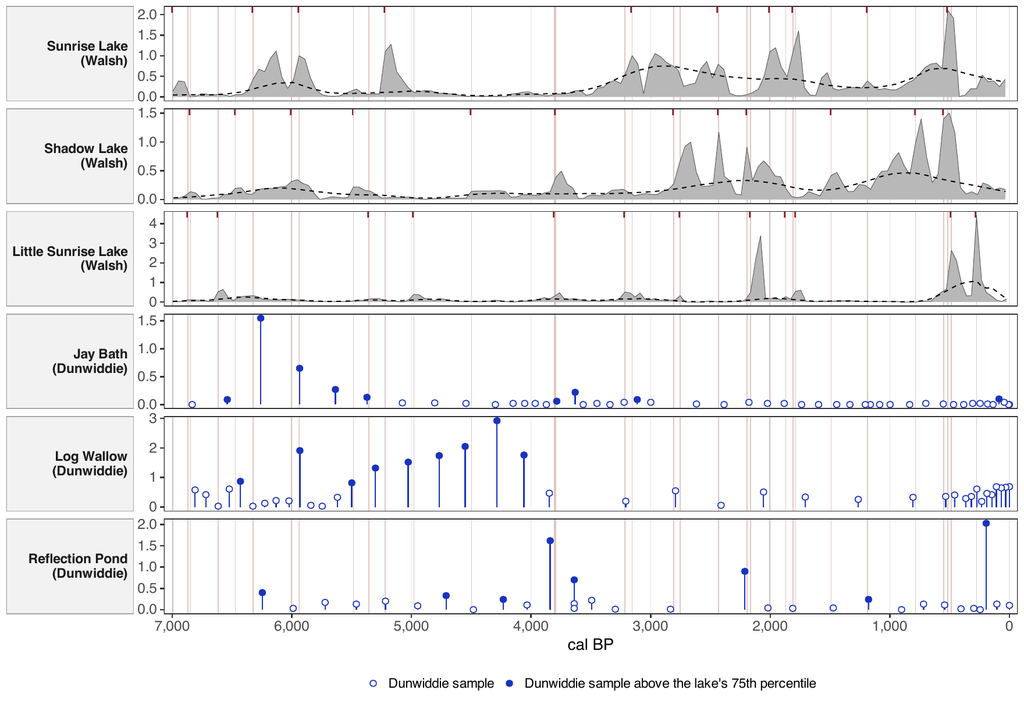

**Fig. S13. Charcoal in the fire records of Sunrise Ridge (Walsh et al., 2017) and in the forest records of MORA (Dunwiddie, 1986).** Upper three rows: charcoal accumulation rate of each Sunrise Ridge record (grey), with its background (dashed) and the fire events that we identified (dark red ticks at the top of each row). Lower three rows: number of charcoal fragments in each macrofossil sample of Dunwiddie (1986). This number is a concentration, because all samples of a core had the same volume, and the samples above the 75th percentile of each lake are filled. Each fire event of the Sunrise Ridge records is drawn as a faint line through all rows. Time runs from 7,000 cal BP to the present, which is the time span of the forest records. The correlations in the text are Spearman correlations of the charcoal of two records over bins of 500 years. Script: `R/figures/supp_charcoal_dunwiddie_walsh.R`.

## Fire between the two surveys

In the Anthropocene a plot pair counts as burned when a fire falls between its two surveys. At MORA this comes from the National Park Service LandTrendr landscape-change polygons of 1987 to 2017 (a fire polygon within 100 m of the plot), at NOCA from the assignment of Wilson et al. (2024). Of the plot pairs in the analysis, 0 at MORA and 24 at NOCA burned (Figs. 2 and 3C). The two MORA plots that burned are left out of the analysis, so the Anthropocene fire comparison is a NOCA comparison.

# Climate–community space

One CCA is fitted to the legacy composition of the 605 matched plots (MORA and NOCA pooled), constrained by the climate variables above (scaling 1, Hill = FALSE). Resurvey plots and Holocene samples are projected into it: their climate gives a predicted (LC) position and their composition an observed (WA) position.

**What and why.** The four seasonal variables come in two tightly linked pairs: spring and winter temperature, and summer and winter precipitation. Inside a pair the CCA cannot tell the two seasons apart, and Holocene lakes reach seasonal combinations the modern plots never show. The CCA is therefore constrained by one variable of each pair. Spring temperature (MSpT) stands for snowmelt timing and the start of the growing season. Summer precipitation (SP) stands for summer drying stress. Because each pair is strongly correlated, the two also carry temperature and precipitation change in general.

**How it is calculated.**

```r
# R/pipeline/11_cca.R
# The CCA is fitted once, on the legacy survey only.
#   species_past_final: one row per calibration plot (605), one column per tree
#     species (13), the presence (1) or absence (0) of each species in the plot.
#   env_past_final: the same 605 plots, two columns, MSpT (mean spring
#     temperature) and SP (summer precipitation) of the plot's legacy climate
#     window.
# The formula reads "species ~ MSpT + SP". vegan::cca finds the two axes,
# each a weighted sum of MSpT and SP, along which species composition changes
# most. With two climate variables there are exactly two axes. All later
# positions (plots at both surveys, lake samples) live in this 2-D space.
cca_formula = reformulate(CCA_VARIABLES, response = "species_past_final")
cca_model = cca(cca_formula, data = env_past_final)
```

```r
# R/pipeline/11_cca.R
# Two positions for every community, both on the fitted axes:
#   type = "lc" (linear combination): where its CLIMATE alone puts it, the
#     predicted position. It uses only MSpT and SP.
#   type = "wa" (weighted average): where its SPECIES put it, the observed
#     position, the average of the scores of the species present.
# The lag M of a community is the distance between the two.
predicted_present = predict(cca_model, newdata = env_present_final, type = "lc", scaling = cca_scaling, hill = cca_hill)
projected_present = predict(cca_model, newdata = species_present_final,
                            type = "wa", scaling = cca_scaling, hill = cca_hill)

predicted_paleo = predict(cca_model, newdata = env_paleo[, CCA_VARIABLES, drop = FALSE],
                          type = "lc", scaling = cca_scaling, hill = cca_hill)
projected_paleo = predict(cca_model, newdata = species_paleo[, keep_species, drop = FALSE],
                          type = "wa", scaling = cca_scaling, hill = cca_hill)
```

**Result.**

**Table S9. Choice of the climate variables of the climate–community space.** CCA fitted to the 605 legacy plots with three sets of climate variables. VIF, variance inflation factor. The last two columns give the percentage of the centuries of the Holocene records (333 at MORA, three lakes, and 111 at NOCA) whose climate, after the bias correction (Appendix S2), was outside the climate of the legacy plots.

| Set | Variables | Largest abs. correlation | VIF | R² | Adjusted R² | MORA lake-centuries outside (%) | NOCA lake-centuries outside (%) |
| --- | --- | --- | --- | --- | --- | --- | --- |
| All four | MSpT, MWT, SP, WP | 0.956 | MSpT 29.6, MWT 26.4, SP 5.2, WP 6.7 | 0.166 | 0.161 | 63.964 | 28.829 |
| MWT + SP | MWT, SP | 0.071 | MWT 1.0, SP 1.0 | 0.141 | 0.138 | 0.000 | 0.000 |
| MSpT + SP | MSpT, SP | 0.286 | MSpT 1.1, SP 1.1 | 0.138 | 0.136 | 0.000 | 0.000 |

<sub>Table file: step0_screening.csv</sub>

With MSpT and SP the CCA explains 13.6% of the variation in composition (adjusted R²), against 16.1% with all four variables. Adding winter temperature and winter precipitation back improves the fit (pseudo-F 9.87, p = 0.0001 unrestricted and p = 0.0061 within parks). That gain comes from the seasonal contrasts within each pair, the same contrasts that make the four-variable fit collinear (VIF up to 29.6) and that place 64% of the MORA lake-centuries outside the calibration climate. With MSpT and SP no lake-century in either park is outside it. The display rotation turns the plane by -20.7 degrees so that rotated axis 1 is spring temperature increasing to the right and rotated axis 2 summer precipitation increasing upward. The pipeline asserts that mismatch, lag, turnover, pace and direction are identical before and after this rotation.

**Choice of CCA constraints.** Candidate variables are screened by their correlations (Fig. S9) and by their variance inflation in the fitted CCA, keeping one temperature and one precipitation variable. With the four seasonal variables MSpT, MWT, SP and WP, the two temperatures had variance inflation factors near 30 and opposite-signed coefficients that are not identifiable. The CCA is therefore constrained by spring temperature, the temperature that changes most through the Holocene, and summer precipitation. Figures in the CCA plane are rotated rigidly by the varimax angle so that the two arrows lie along the axes. Distances and angles, and therefore every tracking metric, are unchanged by the rotation (decision of 2026-11-09 in **Decisions →** 10_decisions). The constraints of this build:

**Table S10. The two climate variables of the climate–community space.** Variance inflation factor (VIF) and biplot score of each variable on the two unrotated CCA axes.

| Variable | Label | VIF | CCA1 score | CCA2 score |
| --- | --- | --- | --- | --- |
| MSpT | Spring temperature | 1.08 | 0.52 | -0.07 |
| SP | Summer precipitation | 1.08 | -0.23 | -0.35 |

<sub>Table file: cca_constraint_vif.csv</sub>

**Table S11. Axes of the CCA.** The two climate variables explained 13.8% of the variation in composition (constrained inertia).

| Axis | Eigenvalue | % total inertia | % constrained inertia |
| --- | --- | --- | --- |
| CCA1 | 0.279 | 9.025 | 65.285 |
| CCA2 | 0.149 | 4.799 | 34.715 |

<sub>Table file: cca_axes.csv</sub>

**Table S12. Permutation tests of the CCA.** 9,999 permutations, unrestricted and restricted within parks. df, degrees of freedom of each component.

| Test | Component | df | Pseudo-F | p (unrestricted) | p (within parks) |
| --- | --- | --- | --- | --- | --- |
| Overall | Model | 2 | 48.284 | < 0.001 | < 0.001 |
| Axis | CCA1 | 1 | 63.044 | < 0.001 | < 0.001 |
| Axis | CCA2 | 1 | 33.594 | < 0.001 | < 0.001 |

<sub>Table file: cca_permutation_tests.csv</sub>

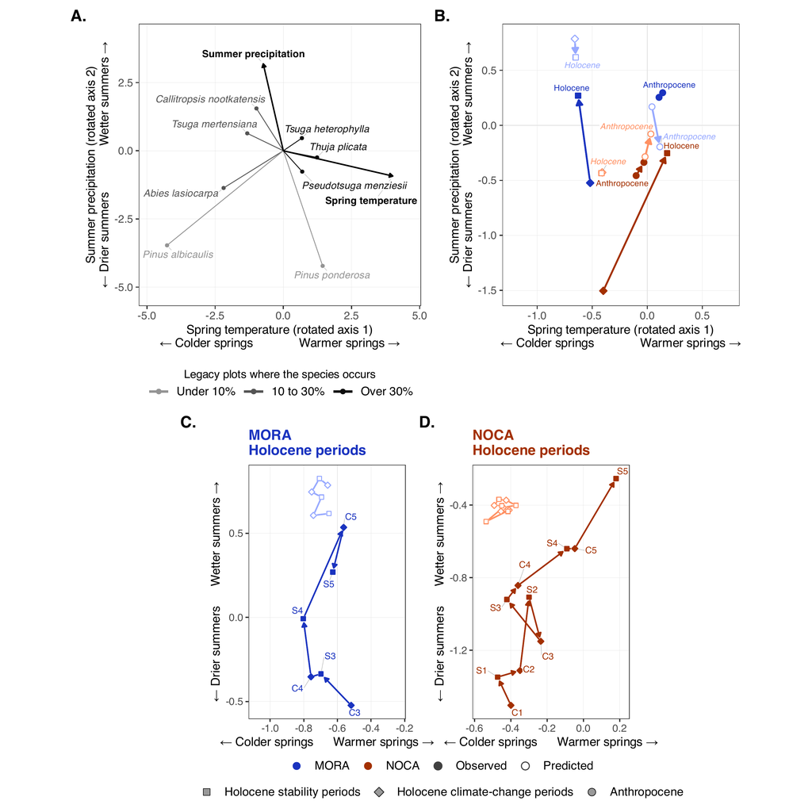

**Fig. 4. Climate and community positions in the CCA plane.** (A) The species that carry more than half an equal share of the constrained inertia (50% divided by the 13 taxa), 8 taxa holding 89% of it (vectors from the centre), and the two climate constraints (bold arrows) of the CCA fitted on 605 legacy plots. The species are shaded by how common they are: the share of the legacy plots in which they occur, under 10%, 10 to 30% or over 30%. All taxa are shown in Fig. S14, and their shares of the inertia against their commonness in Fig. S15. (B) Observed and climate-predicted movement of each park: in the Holocene from the first to the last climate period with samples, in the Anthropocene from the legacy survey to the resurvey (averaged over 328 MORA and 277 NOCA plot pairs). Observed positions are filled symbols in the dark park colour, predicted positions open symbols in the light park colour. The symbol gives the period type: diamonds for Holocene climate-change periods, squares for Holocene stability periods and circles for the Anthropocene. Each line is tagged once with its era, the tags of predicted lines in italics. The MORA arrows run from C3 to S5 (6850 to 1350 cal BP), and the first MORA period rests on 9 samples in 9 lake-centuries. The NOCA arrows run from C1 to S5 (9650 to 1350 cal BP). (C, D) The full Holocene sequence of period centroids at MORA and NOCA, observed and predicted, each period named at its observed centroid (C, climate-change period, S, stability period) and drawn with the symbol of its period type. The steps of the predicted MORA Holocene and the predicted NOCA Holocene sequences are short, and their centroids are joined by plain lines without arrowheads. Where two symbols lie close, the arrowhead is drawn smaller, and where they lie too close for an arrowhead, they are joined by a plain line. Each centroid averages the sampled centuries of each lake within the period, with the lakes weighted equally. MORA C3 (6850 to 6250 cal BP) averages 2 of the 3 lakes, because Reflection Pond has no samples in it. The observed MORA step from C3 to S3 is 0.26 CCA units as drawn and 0.09 over Jay Bath and Log Wallow alone, so it mostly shows a lake joining the mean. Axes orthogonally rotated (varimax, -20.7 degrees) for display, so that axis 1 follows spring temperature and axis 2 summer precipitation. All metrics are rotation-invariant. The unrotated biplot is Fig. S14.

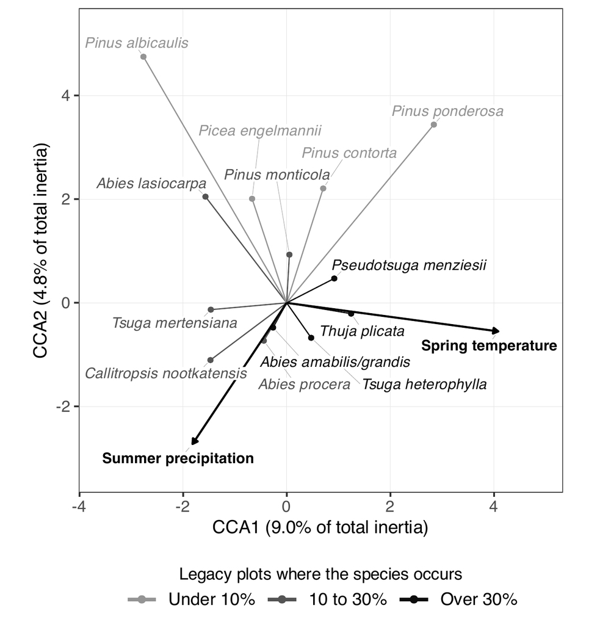

**Fig. S14. The climate–community space on the unrotated CCA axes, with all species.** As Fig. 4A of the main text, on the unrotated axes (labelled with the share of the variation in composition that each axis explained) and with all 13 species.

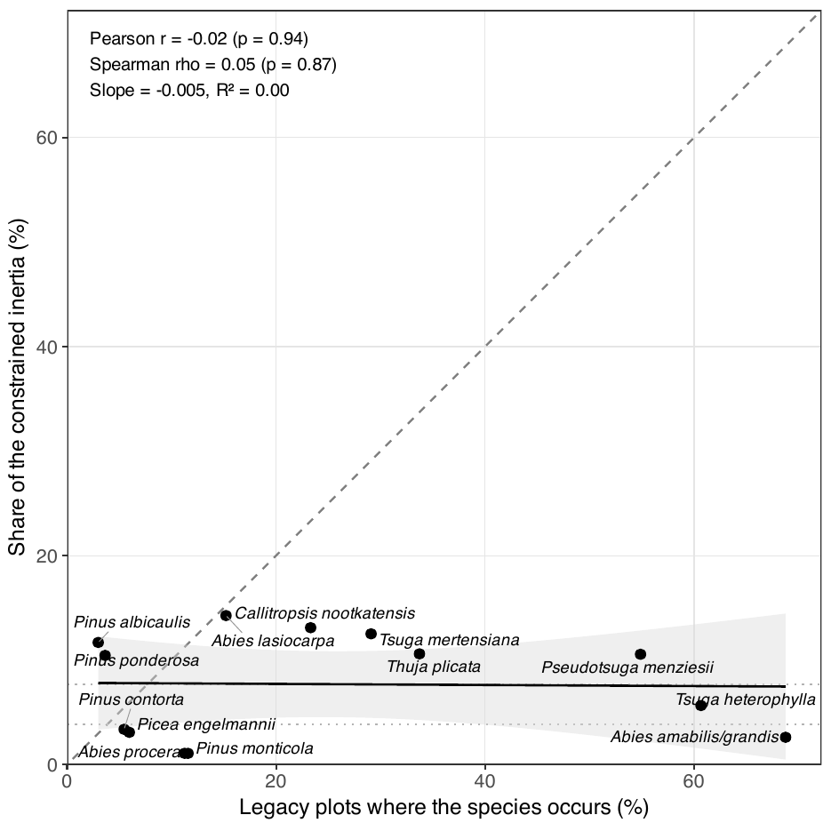

**Fig. S15. Share of the constrained inertia against commonness of the species.** Each point is one of the 13 taxa of the CCA: its share of the constrained inertia against the share of the legacy plots in which it occurs. Dashed line: 1:1. Solid line and band: linear fit with its 95% confidence band. Dotted lines: an equal share of the constrained inertia (7.7%, 100% divided by the number of taxa) and half of it, the threshold above which a species is drawn in Fig. 4A. Share and commonness are not related (Pearson r = -0.02, p = 0.94, and Spearman rho = 0.05, p = 0.87, with a slope of the fit of -0.005 percentage points of inertia per percentage point of plots, R² = 0.00). Only *Pinus albicaulis* and *Pinus ponderosa* carry a larger share of the inertia than of the plots.

Stages and helpers: `R/pipeline/11_cca.R`, `R/helpers/cca_report.R` (screening and add-back test), `R/helpers/cca_display_rotation.R`, `R/pipeline/13_tracking.R` (rotation check), `R/figures/main_fig4_cca_trajectories.R`, `R/figures/supp_cca_inertia_commonness.R` (Fig. S15).

**CCA details →** 06_cca (full model output, species and climate contributions, scaling 1 against scaling 2).

## Holocene samples in the climate–community space

**What and why.** Each macrofossil sample has an observed position in the CCA plane (its WA score, from the taxa it contains). Each lake also has a climate-predicted position for every century (its LC score, from that lake’s own climate cell). Samples are dated by the median of their Bacon ages and grouped by century. The observed position of a century is the centroid of its samples’ WA positions. No vegetation is interpolated between sampled centuries. These century positions feed the lake-periods (Climate–community lags) and the period centroids of Fig. 4. No model is fitted on the century steps any more.

**Table S13. Sampled centuries of each lake.** A sampled century is a century with at least one macrofossil sample.

| Park | Lake | Sampled centuries | Samples | Centuries with one sample | Oldest (cal BP) | Youngest (cal BP) |
| --- | --- | --- | --- | --- | --- | --- |
| MORA | Jay Bath | 42 | 48 | 37 | 6800 | 0 |
| MORA | Log Wallow | 34 | 40 | 29 | 6800 | 0 |
| MORA | Reflection Pond | 28 | 31 | 26 | 6200 | 0 |
| NOCA | Panther Potholes | 107 | 812 | 0 | 10600 | 0 |

<sub>Table file: step1_sampled_centuries.csv</sub>

The records of the three MORA lakes start between 6,200 and 6,800 cal BP, and most of their sampled centuries hold a single sample. The Panther Potholes record (NOCA) covers the whole Holocene, with several samples per century.

Stages and helpers: `R/pipeline/13_tracking.R`, `R/helpers/century_tracking.R`, `R/helpers/tracking_metrics.R`.

# Climate–community lags (Q1)

## Lake-periods

**What and why.** Two scoops of sediment from the same forest in the same century differ by about as much as the forest drifts in many centuries, because one needle caught or missed moves a sample’s position. A lag computed between consecutive centuries is therefore mostly that noise. Comparing the two ends of a whole climate period lets the drift outgrow it. A lake-period is one lake within one climate period. Its start (t1) is the oldest and its end (t2) the youngest sampled century of that lake in that period, and a lake needs samples in at least two centuries of a period to have a lake-period there. The centuries in between enter no model.

At each end the mismatch M is the distance between the observed and the climate-predicted positions. The lag rate is the change in M per century. The turnover rate is the length of the observed movement per century. The pace and direction contributions ask how much smaller the final mismatch would have been if the community had moved the predicted distance in its own direction (pace) or its own distance in the predicted direction (direction). The climate change rate is the standardized end-to-end change of MSpT and SP in the lake’s own climate cell, per century. Fire activity is the number of accepted fire events between t1 and t2, per century and per charcoal core, averaged over the cores of the park that cover the whole lake-period.

**How it is calculated.** The code below computes every quantity from the two ends of a unit, a Holocene lake-period or an Anthropocene plot pair. The comments say what each step means.

```r
# R/helpers/tracking_metrics.R
  # One row per unit (a Holocene lake-period or an Anthropocene plot pair),
  # with two ends, t1 (older) and t2 (younger). At each end the community has
  # an observed position (o1, o2: from its species) and a predicted position
  # (p1, p2: from its climate) on the two CCA axes. The suffix _2 marks t2.
  # Movement from t1 to t2: observed (ox, oy), predicted (px, py), and their
  # lengths a (observed distance) and b (predicted distance).
  ox = x$o1_2-x$o1; oy = x$o2_2-x$o2
  px = x$p1_2-x$p1; py = x$p2_2-x$p2
  a = sqrt(ox^2+oy^2); b = sqrt(px^2+py^2)
  # A movement shorter than epsilon has no direction, so the angle, the pace
  # and direction contributions and the tracking ratio are left undefined there.
  x$finite_endpoints = rowSums(!is.finite(as.matrix(x[coords]))) == 0L
  x$small_observed_movement = is.finite(a) & a <= epsilon
  x$small_predicted_movement = is.finite(b) & b <= epsilon
  observed_direction = x$finite_endpoints & is.finite(a) & a > epsilon
  predicted_direction = x$finite_endpoints & is.finite(b) & b > epsilon
  x$angle_valid = observed_direction & predicted_direction
  x$pace_counterfactual_valid = observed_direction
  x$direction_counterfactual_valid = predicted_direction
  x$tracking_ratio_valid = predicted_direction
  x$delta_observed_CCA1 = ox; x$delta_observed_CCA2 = oy
  x$delta_predicted_CCA1 = px; x$delta_predicted_CCA2 = py
  x$observed_vegetation_displacement = a
  x$predicted_vegetation_displacement = b
  # Turnover rate: observed distance moved, per century. Tracking ratio:
  # observed over predicted distance (1 = moved as far as climate asked).
  # Angle: between the observed and the predicted movement (0 = same way).
  x$observed_turnover_rate = a/x$vegetation_dt_years*100
  x$predicted_vegetation_change_rate = b/x$climate_dt_years*100
  x$magnitude_tracking_ratio = ifelse(predicted_direction, a/b, NA_real_)
  x$rate_tracking_ratio = ifelse(predicted_direction,
    x$observed_turnover_rate/x$predicted_vegetation_change_rate, NA_real_)
  x$angle_degrees = acos(safe_cosine_2d(ox, oy, px, py, epsilon))*180/pi
  # Lag M at each end: the distance between observed and predicted position,
  # how far the community is from where its climate would put it. The lag is
  # M at t2 minus M at t1 (positive: the gap grew), the lag rate the same per
  # century.
  x$lag_t1 = sqrt((x$o1-x$p1)^2+(x$o2-x$p2)^2)
  x$lag_t2 = sqrt((x$o1_2-x$p1_2)^2+(x$o2_2-x$p2_2)^2)
  x$change_in_lag = x$lag_t2-x$lag_t1
  x$lag_rate_per_century = x$change_in_lag/x$climate_dt_years*100
```

```r
# R/helpers/tracking_metrics.R
  # Two "what if" end points at t2, both starting from the observed t1 position:
  #   pace-corrected: the community's own direction, but the predicted
  #     distance b (as if it had moved at the climate's pace);
  #   direction-corrected: the predicted direction, but its own distance a
  #     (as if it had moved the climate's way).
  # Each contribution is the observed lag at t2 minus the lag at that "what if" end
  # point, per century. Positive: the community's own pace (or direction)
  # widened the lag. Negative: it narrowed the lag.
  x$pace_corrected_CCA1 = x$pace_corrected_CCA2 = rep(NA_real_, nrow(x))
  x$direction_corrected_CCA1 = x$direction_corrected_CCA2 = rep(NA_real_, nrow(x))
  i = observed_direction
  x$pace_corrected_CCA1[i] = x$o1[i]+b[i]*ox[i]/a[i]
  x$pace_corrected_CCA2[i] = x$o2[i]+b[i]*oy[i]/a[i]
  i = predicted_direction
  x$direction_corrected_CCA1[i] = x$o1[i]+a[i]*px[i]/b[i]
  x$direction_corrected_CCA2[i] = x$o2[i]+a[i]*py[i]/b[i]
  x$lag_t2_pace_corrected = sqrt((x$pace_corrected_CCA1-x$p1_2)^2+
    (x$pace_corrected_CCA2-x$p2_2)^2)
  x$lag_t2_direction_corrected = sqrt((x$direction_corrected_CCA1-x$p1_2)^2+
    (x$direction_corrected_CCA2-x$p2_2)^2)
  x$pace_effect_on_lag = x$lag_t2-x$lag_t2_pace_corrected
  x$direction_effect_on_lag = x$lag_t2-x$lag_t2_direction_corrected
  x$pace_effect_on_lag_per_century = x$pace_effect_on_lag/x$climate_dt_years*100
  x$direction_effect_on_lag_per_century = x$direction_effect_on_lag/x$climate_dt_years*100
```

**Result.**

**Table S14. Lake-periods.** One row for each lake within each climate period, from its oldest (t1) to its youngest (t2) sampled century. The climate is the Holocene climate after the bias correction (Appendix S2). M, climate–community mismatch. Rates are per century: the climate change rate in SD of the legacy plots, fire activity in fire events per charcoal record, and the other rates in CCA distance. The pace contribution and the direction contribution are undefined when the observed or the climate-predicted position did not move.

| Park | Lake | Period | t1 (cal BP) | t2 (cal BP) | Years | Samples t1 | Samples t2 | Climate change rate | MSpT change (°C) | SP change (mm) | Fire activity | M t1 | M t2 | Lag rate | Turnover rate | Pace contribution | Direction contribution |
| --- | --- | --- | --- | --- | --- | --- | --- | --- | --- | --- | --- | --- | --- | --- | --- | --- | --- |
| MORA | Jay Bath | C3 | 6800 | 6300 | 500 | 1 | 1 | 0.129 | -1.183 | -25.777 | 0.200 | 1.259 | 1.283 | 0.005 | 0.055 | -0.007 | 0.010 |
| MORA | Jay Bath | S3 | 5900 | 5600 | 300 | 1 | 1 | 0.136 | 0.083 | 25.040 | 0.000 | 1.539 | 1.566 | 0.009 | 0.073 | -0.009 | 0.023 |
| MORA | Jay Bath | C4 | 5400 | 5100 | 300 | 1 | 1 | 0.021 | -0.150 | -1.000 | 0.222 | 1.490 | 1.491 | 0.000 | 0.000 | — | — |
| MORA | Jay Bath | S4 | 4800 | 2400 | 2400 | 1 | 1 | 0.011 | -0.267 | 14.312 | 0.125 | 0.762 | 0.347 | -0.017 | 0.025 | -0.017 | 0.002 |
| MORA | Jay Bath | C5 | 2200 | 1900 | 300 | 1 | 1 | 0.155 | 0.417 | -26.621 | 0.333 | 0.638 | 0.395 | -0.081 | 0.140 | 0.008 | -0.153 |
| MORA | Jay Bath | S5 | 1700 | 1400 | 300 | 1 | 1 | 0.084 | -0.167 | 14.908 | 0.111 | 0.428 | 0.532 | 0.035 | 0.000 | — | — |
| MORA | Log Wallow | C3 | 6800 | 6300 | 500 | 1 | 1 | 0.126 | -1.133 | -25.777 | 0.200 | 1.443 | 1.174 | -0.054 | 0.030 | 0.033 | -0.038 |
| MORA | Log Wallow | S3 | 6200 | 5500 | 700 | 1 | 1 | 0.048 | 0.550 | 15.318 | 0.095 | 1.262 | 0.983 | -0.040 | 0.058 | -0.028 | -0.031 |
| MORA | Log Wallow | C4 | 5300 | 5000 | 300 | 1 | 1 | 0.015 | -0.067 | -2.139 | 0.111 | 1.060 | 1.114 | 0.018 | 0.076 | 0.022 | -0.033 |
| MORA | Log Wallow | S4 | 4800 | 2400 | 2400 | 1 | 1 | 0.012 | -0.267 | 16.032 | 0.125 | 0.741 | 0.633 | -0.004 | 0.014 | -0.005 | 0.004 |
| MORA | Reflection Pond | S3 | 6200 | 5500 | 700 | 1 | 1 | 0.045 | 0.550 | 13.456 | 0.095 | 0.811 | 0.949 | 0.020 | 0.000 | — | — |
| MORA | Reflection Pond | S4 | 4900 | 2800 | 2100 | 1 | 1 | 0.024 | -0.900 | -20.338 | 0.095 | 1.069 | 0.275 | -0.038 | 0.032 | -0.017 | -0.053 |
| MORA | Reflection Pond | C5 | 2200 | 1800 | 400 | 1 | 1 | 0.130 | 0.483 | -29.506 | 0.417 | 0.234 | 0.337 | 0.026 | 0.084 | 0.028 | -0.002 |
| NOCA | Panther Potholes | C1 | 9600 | 8700 | 900 | 7 | 7 | 0.044 | -0.933 | -5.983 | 0.667 | 1.063 | 1.457 | 0.044 | 0.050 | 0.023 | 0.036 |
| NOCA | Panther Potholes | S1 | 8600 | 8300 | 300 | 8 | 7 | 0.076 | 0.517 | 4.614 | 0.333 | 1.015 | 1.175 | 0.053 | 0.140 | 0.030 | 0.078 |
| NOCA | Panther Potholes | C2 | 8200 | 7300 | 900 | 8 | 6 | 0.060 | 0.967 | 22.242 | 1.222 | 0.829 | 0.652 | -0.020 | 0.033 | -0.001 | -0.019 |
| NOCA | Panther Potholes | S2 | 7200 | 6900 | 300 | 5 | 6 | 0.039 | 0.283 | -0.409 | 0.333 | 0.476 | 0.604 | 0.042 | 0.046 | 0.023 | 0.039 |
| NOCA | Panther Potholes | C3 | 6800 | 6300 | 500 | 5 | 6 | 0.096 | -1.100 | -8.894 | 0.600 | 1.169 | 0.732 | -0.087 | 0.103 | -0.022 | -0.122 |
| NOCA | Panther Potholes | S3 | 6200 | 5500 | 700 | 5 | 6 | 0.033 | 0.533 | 4.093 | 0.571 | 0.588 | 0.378 | -0.030 | 0.073 | -0.019 | -0.044 |
| NOCA | Panther Potholes | C4 | 5400 | 5000 | 400 | 6 | 6 | 0.013 | 0.117 | -1.185 | 1.250 | 0.469 | 0.399 | -0.017 | 0.095 | -0.008 | -0.095 |
| NOCA | Panther Potholes | S4 | 4900 | 2300 | 2600 | 5 | 11 | 0.014 | -0.783 | -9.468 | 0.462 | 0.268 | 0.561 | 0.011 | 0.017 | 0.008 | 0.005 |
| NOCA | Panther Potholes | C5 | 2200 | 1800 | 400 | 10 | 10 | 0.091 | 0.633 | -15.620 | 0.750 | 0.445 | 0.415 | -0.008 | 0.077 | 0.022 | -0.041 |
| NOCA | Panther Potholes | S5 | 1700 | 1400 | 300 | 8 | 9 | 0.049 | -0.017 | 9.144 | 0.333 | 0.273 | 1.087 | 0.271 | 0.281 | 0.259 | 0.047 |

<sub>Table file: step24_lake_periods.csv</sub>

Of the 27 combinations of lake and climate period with at least one sampled century, 23 had samples in two or more centuries and are therefore lake-periods (13 at MORA and 10 at NOCA, of which 11 in climate-change periods and 12 in stability periods). The lake-periods span 300 to 2600 years. At MORA, t1 and t2 of every lake-period hold a single sample, and 3 lake-periods have no pace or direction contribution, because the observed or the climate-predicted position did not move. The charcoal records cover all lake-periods.

Stages and helpers: `R/pipeline/13_tracking.R`, `R/helpers/lake_periods.R`, `R/helpers/tracking_metrics.R`, `R/helpers/century_tracking.R` (fire per interval), `R/tests/test_lake_periods.R`.

## Comparison among period types

**What and why.** Each response is compared between the Holocene stability periods, the Holocene climate-change periods and the Anthropocene, within each park. The two Holocene types are never pooled, so back-and-forth change in the stability periods cannot cancel the directional change of the climate-change periods, and the parks are never pooled. The Holocene rows are the lake-periods and the Anthropocene rows are the plot pairs, in one model per response with group-specific residual spread, the endpoint weights and the AR(1) within each lake. Fire stays out of these models, because it is measured differently in the two eras. Rates over a few decades and over centuries are not on equal footing, since longer windows give lower rates, and every comparison states both time spans. The three contrasts between period types in each park are tested together for both parks, so each response has six contrasts, and their p-values are Holm-adjusted within that family. Significance is read from the adjusted p-values. The intervals are the unadjusted 95% intervals.

**How it is calculated.**

```r
# R/pipeline/14_era_models.R
  # One model per response (climate change rate, climate change, turnover rate,
  # displacement, lag rate, lag, pace contribution, direction contribution and their totals).
  # Climate change, displacement, lag and the contribution totals are totals between
  # the two ends, the others per century.
  # Each row is a Holocene lake-period or an
  # Anthropocene plot pair; `estimate` is its value of the response.
  # Mean part, period_type * site: one mean for each period type (Holocene-S,
  # Holocene-C, Anthropocene) in each park. The era means, the contrasts
  # (Anthropocene minus each Holocene type) and the folds come from these.
  # gls (generalized least squares, nlme) is a regression whose errors may be
  # correlated and unequal:
  #   correlation: lake-periods of one lake are correlated, AR(1) within each
  #     series (a lake; each Anthropocene plot is a series of one unit).
  #     unit_index is the position of the lake-period's climate period (C1 = 1
  #     to S5 = 10), so two lake-periods k periods apart correlate by phi^k,
  #     also where the periods between them are missing;
  #   weights: each period type in each park has its own spread (varIdent), and
  #     ends that rest on few samples are noisier, in proportion to
  #     endpoint_var = 1/n_start + 1/n_end (varFixed).
  captured = reconstruction_capture(function() gls(estimate ~ period_type * site,
    correlation = corAR1(form = ~ unit_index | series),
    weights = varComb(varIdent(form = ~ 1 | period_type_site), varFixed(~ endpoint_var)),
    data = d, method = 'REML', control = glsControl(msMaxIter = 500)))
```

**Result.**

**Table S15. Comparison among period types: estimated means for each period type and park.** Generalized least-squares models with period type, park, and their interaction as fixed effects (see Methods of the main text). The Holocene climate is CHELSA-TraCE21k after the bias correction (Appendix S2). SE, standard error. df, residual degrees of freedom of the model, used for the 95% confidence interval (CI). Climate change is in SD of the legacy plots, and turnover, lag, pace contribution, and direction contribution are in CCA distance. Quantities named rate, and the two contributions, are per century, unless marked not divided by time. The lake-periods span 300 to 900 years in the Holocene climate-change periods and 300 to 2600 years in the Holocene stability periods, and the Anthropocene plot pairs span 27.5 to 32.5 years.

| Quantity | Park | Period type | n | Estimated mean | SE | df | 95% CI |
| --- | --- | --- | --- | --- | --- | --- | --- |
| Climate change rate | MORA | Holocene-S | 7 | 0.052 | 0.017 | 622 | 0.018 to 0.085 |
| Climate change rate | MORA | Holocene-C | 6 | 0.096 | 0.025 | 622 | 0.047 to 0.145 |
| Climate change rate | MORA | Anthropocene | 328 | 3.102 | 0.053 | 622 | 2.999 to 3.205 |
| Climate change rate | NOCA | Holocene-S | 5 | 0.044 | 0.010 | 622 | 0.023 to 0.064 |
| Climate change rate | NOCA | Holocene-C | 5 | 0.063 | 0.015 | 622 | 0.034 to 0.093 |
| Climate change rate | NOCA | Anthropocene | 277 | 2.104 | 0.100 | 622 | 1.907 to 2.300 |
| Climate change (not divided by time) | MORA | Holocene-S | 7 | 0.329 | 0.037 | 622 | 0.256 to 0.401 |
| Climate change (not divided by time) | MORA | Holocene-C | 6 | 0.398 | 0.121 | 622 | 0.162 to 0.635 |
| Climate change (not divided by time) | MORA | Anthropocene | 328 | 0.913 | 0.018 | 622 | 0.878 to 0.948 |
| Climate change (not divided by time) | NOCA | Holocene-S | 5 | 0.216 | 0.040 | 622 | 0.137 to 0.294 |
| Climate change (not divided by time) | NOCA | Holocene-C | 5 | 0.378 | 0.076 | 622 | 0.230 to 0.526 |
| Climate change (not divided by time) | NOCA | Anthropocene | 277 | 0.597 | 0.029 | 622 | 0.541 to 0.653 |
| Turnover rate | MORA | Holocene-S | 7 | 0.029 | 0.012 | 622 | 0.006 to 0.052 |
| Turnover rate | MORA | Holocene-C | 6 | 0.080 | 0.022 | 622 | 0.037 to 0.123 |
| Turnover rate | MORA | Anthropocene | 328 | 0.936 | 0.046 | 622 | 0.847 to 1.026 |
| Turnover rate | NOCA | Holocene-S | 5 | 0.146 | 0.070 | 622 | 0.009 to 0.284 |
| Turnover rate | NOCA | Holocene-C | 5 | 0.061 | 0.019 | 622 | 0.024 to 0.099 |
| Turnover rate | NOCA | Anthropocene | 277 | 2.066 | 0.117 | 622 | 1.837 to 2.296 |
| Turnover (not divided by time) | MORA | Holocene-S | 7 | 0.315 | 0.103 | 622 | 0.113 to 0.517 |
| Turnover (not divided by time) | MORA | Holocene-C | 6 | 0.245 | 0.062 | 622 | 0.124 to 0.366 |
| Turnover (not divided by time) | MORA | Anthropocene | 328 | 0.356 | 0.017 | 622 | 0.322 to 0.390 |
| Turnover (not divided by time) | NOCA | Holocene-S | 5 | 0.495 | 0.116 | 622 | 0.267 to 0.723 |
| Turnover (not divided by time) | NOCA | Holocene-C | 5 | 0.373 | 0.042 | 622 | 0.291 to 0.454 |
| Turnover (not divided by time) | NOCA | Anthropocene | 277 | 0.659 | 0.037 | 622 | 0.585 to 0.732 |
| Lag rate | MORA | Holocene-S | 7 | -0.005 | 0.011 | 622 | -0.026 to 0.016 |
| Lag rate | MORA | Holocene-C | 6 | -0.015 | 0.017 | 622 | -0.049 to 0.019 |
| Lag rate | MORA | Anthropocene | 328 | 0.687 | 0.062 | 622 | 0.565 to 0.810 |
| Lag rate | NOCA | Holocene-S | 5 | 0.083 | 0.057 | 622 | -0.029 to 0.194 |
| Lag rate | NOCA | Holocene-C | 5 | -0.015 | 0.020 | 622 | -0.053 to 0.024 |
| Lag rate | NOCA | Anthropocene | 277 | -0.133 | 0.137 | 622 | -0.402 to 0.137 |
| Lag | MORA | Holocene-S | 7 | -0.189 | 0.128 | 622 | -0.440 to 0.062 |
| Lag | MORA | Holocene-C | 6 | -0.053 | 0.066 | 622 | -0.182 to 0.077 |
| Lag | MORA | Anthropocene | 328 | 0.201 | 0.018 | 622 | 0.165 to 0.237 |
| Lag | NOCA | Holocene-S | 5 | 0.293 | 0.170 | 622 | -0.041 to 0.626 |
| Lag | NOCA | Holocene-C | 5 | -0.039 | 0.127 | 622 | -0.288 to 0.210 |
| Lag | NOCA | Anthropocene | 277 | -0.039 | 0.039 | 622 | -0.115 to 0.038 |
| Pace contribution | MORA | Holocene-S | 5 | -0.016 | 0.004 | 474 | -0.024 to -0.007 |
| Pace contribution | MORA | Holocene-C | 5 | 0.018 | 0.008 | 474 | 0.002 to 0.033 |
| Pace contribution | MORA | Anthropocene | 252 | 0.125 | 0.047 | 474 | 0.032 to 0.218 |
| Pace contribution | NOCA | Holocene-S | 5 | 0.081 | 0.052 | 474 | -0.022 to 0.184 |
| Pace contribution | NOCA | Holocene-C | 5 | 0.007 | 0.008 | 474 | -0.009 to 0.024 |
| Pace contribution | NOCA | Anthropocene | 208 | -0.226 | 0.154 | 474 | -0.528 to 0.076 |
| Direction contribution | MORA | Holocene-S | 5 | -0.016 | 0.023 | 474 | -0.060 to 0.029 |
| Direction contribution | MORA | Holocene-C | 5 | -0.044 | 0.046 | 474 | -0.135 to 0.048 |
| Direction contribution | MORA | Anthropocene | 252 | 0.531 | 0.081 | 474 | 0.372 to 0.691 |
| Direction contribution | NOCA | Holocene-S | 5 | 0.048 | 0.026 | 474 | -0.003 to 0.098 |
| Direction contribution | NOCA | Holocene-C | 5 | -0.025 | 0.031 | 474 | -0.086 to 0.036 |
| Direction contribution | NOCA | Anthropocene | 208 | -0.347 | 0.147 | 474 | -0.637 to -0.058 |
| Pace contribution (not divided by time) | MORA | Holocene-S | 5 | -0.227 | 0.082 | 474 | -0.388 to -0.067 |
| Pace contribution (not divided by time) | MORA | Holocene-C | 5 | 0.065 | 0.038 | 474 | -0.009 to 0.139 |
| Pace contribution (not divided by time) | MORA | Anthropocene | 252 | 0.034 | 0.014 | 474 | 0.007 to 0.062 |
| Pace contribution (not divided by time) | NOCA | Holocene-S | 5 | 0.281 | 0.162 | 474 | -0.038 to 0.599 |
| Pace contribution (not divided by time) | NOCA | Holocene-C | 5 | 0.055 | 0.053 | 474 | -0.049 to 0.159 |
| Pace contribution (not divided by time) | NOCA | Anthropocene | 208 | -0.065 | 0.044 | 474 | -0.151 to 0.021 |
| Direction contribution (not divided by time) | MORA | Holocene-S | 5 | -0.266 | 0.303 | 474 | -0.862 to 0.330 |
| Direction contribution (not divided by time) | MORA | Holocene-C | 5 | -0.148 | 0.116 | 474 | -0.377 to 0.080 |
| Direction contribution (not divided by time) | MORA | Anthropocene | 252 | 0.155 | 0.024 | 474 | 0.108 to 0.201 |
| Direction contribution (not divided by time) | NOCA | Holocene-S | 5 | 0.126 | 0.102 | 474 | -0.075 to 0.327 |
| Direction contribution (not divided by time) | NOCA | Holocene-C | 5 | -0.135 | 0.157 | 474 | -0.443 to 0.173 |
| Direction contribution (not divided by time) | NOCA | Anthropocene | 208 | -0.099 | 0.042 | 474 | -0.181 to -0.016 |

<sub>Table file: step5a_era_means.csv</sub>

**Table S16. Comparison among period types: differences between period types within each park.** Models and units as in Table S15. Two-sided t-tests on the residual degrees of freedom (df) of the model, with 95% confidence intervals (CI, not adjusted). p (Holm) is adjusted with the Holm method across the six differences of each quantity, three per park. The lake-periods span 300 to 900 years in the Holocene climate-change periods and 300 to 2600 years in the Holocene stability periods, and the Anthropocene plot pairs span 27.5 to 32.5 years.

| Quantity | Park | Contrast | Estimate | SE | df | t | 95% CI | p | p (Holm) |
| --- | --- | --- | --- | --- | --- | --- | --- | --- | --- |
| Climate change (not divided by time) | MORA | Anthropocene - Holocene-C | 0.515 | 0.122 | 622 | 4.224 | 0.275 to 0.754 | 0.000 | 0.000 |
| Climate change (not divided by time) | MORA | Anthropocene - Holocene-S | 0.584 | 0.041 | 622 | 14.308 | 0.504 to 0.665 | 0.000 | 0.000 |
| Climate change (not divided by time) | MORA | Holocene-C - Holocene-S | 0.070 | 0.136 | 622 | 0.513 | -0.197 to 0.336 | 0.608 | 0.608 |
| Climate change (not divided by time) | NOCA | Anthropocene - Holocene-C | 0.219 | 0.081 | 622 | 2.707 | 0.060 to 0.377 | 0.007 | 0.021 |
| Climate change (not divided by time) | NOCA | Anthropocene - Holocene-S | 0.381 | 0.049 | 622 | 7.754 | 0.284 to 0.477 | 0.000 | 0.000 |
| Climate change (not divided by time) | NOCA | Holocene-C - Holocene-S | 0.162 | 0.097 | 622 | 1.665 | -0.029 to 0.353 | 0.096 | 0.193 |
| Climate change rate | MORA | Anthropocene - Holocene-C | 3.007 | 0.058 | 622 | 51.700 | 2.892 to 3.121 | 0.000 | 0.000 |
| Climate change rate | MORA | Anthropocene - Holocene-S | 3.051 | 0.055 | 622 | 55.255 | 2.942 to 3.159 | 0.000 | 0.000 |
| Climate change rate | MORA | Holocene-C - Holocene-S | 0.044 | 0.030 | 622 | 1.485 | -0.014 to 0.103 | 0.138 | 0.276 |
| Climate change rate | NOCA | Anthropocene - Holocene-C | 2.040 | 0.101 | 622 | 20.127 | 1.841 to 2.239 | 0.000 | 0.000 |
| Climate change rate | NOCA | Anthropocene - Holocene-S | 2.060 | 0.101 | 622 | 20.434 | 1.862 to 2.258 | 0.000 | 0.000 |
| Climate change rate | NOCA | Holocene-C - Holocene-S | 0.020 | 0.018 | 622 | 1.106 | -0.015 to 0.055 | 0.269 | 0.276 |
| Direction contribution | MORA | Anthropocene - Holocene-C | 0.575 | 0.093 | 474 | 6.158 | 0.392 to 0.759 | 0.000 | 0.000 |
| Direction contribution | MORA | Anthropocene - Holocene-S | 0.547 | 0.084 | 474 | 6.498 | 0.382 to 0.712 | 0.000 | 0.000 |
| Direction contribution | MORA | Holocene-C - Holocene-S | -0.028 | 0.032 | 474 | -0.880 | -0.091 to 0.035 | 0.380 | 0.380 |
| Direction contribution | NOCA | Anthropocene - Holocene-C | -0.322 | 0.151 | 474 | -2.138 | -0.618 to -0.026 | 0.033 | 0.066 |
| Direction contribution | NOCA | Anthropocene - Holocene-S | -0.395 | 0.150 | 474 | -2.639 | -0.689 to -0.101 | 0.009 | 0.026 |
| Direction contribution | NOCA | Holocene-C - Holocene-S | -0.073 | 0.014 | 474 | -5.099 | -0.101 to -0.045 | 0.000 | 0.000 |
| Direction contribution (not divided by time) | MORA | Anthropocene - Holocene-C | 0.303 | 0.119 | 474 | 2.554 | 0.070 to 0.536 | 0.011 | 0.066 |
| Direction contribution (not divided by time) | MORA | Anthropocene - Holocene-S | 0.420 | 0.304 | 474 | 1.382 | -0.177 to 1.018 | 0.168 | 0.503 |
| Direction contribution (not divided by time) | MORA | Holocene-C - Holocene-S | 0.117 | 0.253 | 474 | 0.464 | -0.379 to 0.614 | 0.643 | 1.000 |
| Direction contribution (not divided by time) | NOCA | Anthropocene - Holocene-C | 0.036 | 0.162 | 474 | 0.225 | -0.282 to 0.355 | 0.822 | 1.000 |
| Direction contribution (not divided by time) | NOCA | Anthropocene - Holocene-S | -0.225 | 0.111 | 474 | -2.033 | -0.442 to -0.008 | 0.043 | 0.170 |
| Direction contribution (not divided by time) | NOCA | Holocene-C - Holocene-S | -0.261 | 0.106 | 474 | -2.467 | -0.469 to -0.053 | 0.014 | 0.070 |
| Turnover (not divided by time) | MORA | Anthropocene - Holocene-C | 0.111 | 0.064 | 622 | 1.729 | -0.015 to 0.236 | 0.084 | 0.422 |
| Turnover (not divided by time) | MORA | Anthropocene - Holocene-S | 0.041 | 0.104 | 622 | 0.394 | -0.164 to 0.246 | 0.694 | 1.000 |
| Turnover (not divided by time) | MORA | Holocene-C - Holocene-S | -0.070 | 0.132 | 622 | -0.526 | -0.329 to 0.190 | 0.599 | 1.000 |
| Turnover (not divided by time) | NOCA | Anthropocene - Holocene-C | 0.286 | 0.056 | 622 | 5.118 | 0.176 to 0.396 | 0.000 | 0.000 |
| Turnover (not divided by time) | NOCA | Anthropocene - Holocene-S | 0.164 | 0.122 | 622 | 1.342 | -0.076 to 0.403 | 0.180 | 0.720 |
| Turnover (not divided by time) | NOCA | Holocene-C - Holocene-S | -0.123 | 0.135 | 622 | -0.910 | -0.387 to 0.142 | 0.363 | 1.000 |
| Lag | MORA | Anthropocene - Holocene-C | 0.254 | 0.068 | 622 | 3.719 | 0.120 to 0.388 | 0.000 | 0.001 |
| Lag | MORA | Anthropocene - Holocene-S | 0.390 | 0.129 | 622 | 3.024 | 0.137 to 0.643 | 0.003 | 0.013 |
| Lag | MORA | Holocene-C - Holocene-S | 0.136 | 0.139 | 622 | 0.979 | -0.137 to 0.409 | 0.328 | 0.656 |
| Lag | NOCA | Anthropocene - Holocene-C | 0.000 | 0.133 | 622 | 0.002 | -0.260 to 0.261 | 0.998 | 0.998 |
| Lag | NOCA | Anthropocene - Holocene-S | -0.332 | 0.174 | 622 | -1.903 | -0.674 to 0.011 | 0.058 | 0.230 |
| Lag | NOCA | Holocene-C - Holocene-S | -0.332 | 0.202 | 622 | -1.646 | -0.728 to 0.064 | 0.100 | 0.301 |
| Lag rate | MORA | Anthropocene - Holocene-C | 0.702 | 0.065 | 622 | 10.850 | 0.575 to 0.829 | 0.000 | 0.000 |
| Lag rate | MORA | Anthropocene - Holocene-S | 0.693 | 0.063 | 622 | 10.949 | 0.568 to 0.817 | 0.000 | 0.000 |
| Lag rate | MORA | Holocene-C - Holocene-S | -0.010 | 0.021 | 622 | -0.463 | -0.051 to 0.032 | 0.644 | 0.787 |
| Lag rate | NOCA | Anthropocene - Holocene-C | -0.118 | 0.139 | 622 | -0.854 | -0.391 to 0.154 | 0.394 | 0.787 |
| Lag rate | NOCA | Anthropocene - Holocene-S | -0.216 | 0.148 | 622 | -1.451 | -0.507 to 0.076 | 0.147 | 0.462 |
| Lag rate | NOCA | Holocene-C - Holocene-S | -0.097 | 0.062 | 622 | -1.577 | -0.218 to 0.024 | 0.115 | 0.462 |
| Pace contribution | MORA | Anthropocene - Holocene-C | 0.108 | 0.048 | 474 | 2.236 | 0.013 to 0.202 | 0.026 | 0.103 |
| Pace contribution | MORA | Anthropocene - Holocene-S | 0.141 | 0.048 | 474 | 2.953 | 0.047 to 0.234 | 0.003 | 0.017 |
| Pace contribution | MORA | Holocene-C - Holocene-S | 0.033 | 0.008 | 474 | 4.080 | 0.017 to 0.049 | 0.000 | 0.000 |
| Pace contribution | NOCA | Anthropocene - Holocene-C | -0.233 | 0.154 | 474 | -1.516 | -0.536 to 0.069 | 0.130 | 0.260 |
| Pace contribution | NOCA | Anthropocene - Holocene-S | -0.307 | 0.162 | 474 | -1.891 | -0.626 to 0.012 | 0.059 | 0.178 |
| Pace contribution | NOCA | Holocene-C - Holocene-S | -0.074 | 0.050 | 474 | -1.475 | -0.172 to 0.025 | 0.141 | 0.260 |
| Pace contribution (not divided by time) | MORA | Anthropocene - Holocene-C | -0.031 | 0.040 | 474 | -0.766 | -0.110 to 0.048 | 0.444 | 0.444 |
| Pace contribution (not divided by time) | MORA | Anthropocene - Holocene-S | 0.262 | 0.083 | 474 | 3.152 | 0.099 to 0.425 | 0.002 | 0.009 |
| Pace contribution (not divided by time) | MORA | Holocene-C - Holocene-S | 0.292 | 0.079 | 474 | 3.719 | 0.138 to 0.447 | 0.000 | 0.001 |
| Pace contribution (not divided by time) | NOCA | Anthropocene - Holocene-C | -0.120 | 0.069 | 474 | -1.744 | -0.255 to 0.015 | 0.082 | 0.245 |
| Pace contribution (not divided by time) | NOCA | Anthropocene - Holocene-S | -0.346 | 0.168 | 474 | -2.061 | -0.675 to -0.016 | 0.040 | 0.160 |
| Pace contribution (not divided by time) | NOCA | Holocene-C - Holocene-S | -0.226 | 0.147 | 474 | -1.540 | -0.514 to 0.062 | 0.124 | 0.248 |
| Turnover rate | MORA | Anthropocene - Holocene-C | 0.857 | 0.051 | 622 | 16.872 | 0.757 to 0.956 | 0.000 | 0.000 |
| Turnover rate | MORA | Anthropocene - Holocene-S | 0.908 | 0.047 | 622 | 19.201 | 0.815 to 1.001 | 0.000 | 0.000 |
| Turnover rate | MORA | Holocene-C - Holocene-S | 0.051 | 0.031 | 622 | 1.633 | -0.010 to 0.113 | 0.103 | 0.206 |
| Turnover rate | NOCA | Anthropocene - Holocene-C | 2.005 | 0.118 | 622 | 16.936 | 1.773 to 2.238 | 0.000 | 0.000 |
| Turnover rate | NOCA | Anthropocene - Holocene-S | 1.920 | 0.136 | 622 | 14.106 | 1.653 to 2.187 | 0.000 | 0.000 |
| Turnover rate | NOCA | Holocene-C - Holocene-S | -0.085 | 0.086 | 622 | -0.990 | -0.253 to 0.084 | 0.323 | 0.323 |

<sub>Table file: step5a_era_contrasts.csv</sub>

**Table S17. How many times higher the rates were in the Anthropocene than in the Holocene.** The estimated mean of the Anthropocene divided by the estimated mean of each Holocene period type (Table S15). The lake-periods span 300 to 900 years in the Holocene climate-change periods and 300 to 2600 years in the Holocene stability periods, and the Anthropocene plot pairs span 27.5 to 32.5 years.

| Quantity | Park | Anthropocene over | Fold | Quoted as speed |
| --- | --- | --- | --- | --- |
| Climate change rate | MORA | Holocene-C | 32.415 | yes |
| Climate change rate | MORA | Holocene-S | 60.154 | no |
| Climate change rate | NOCA | Holocene-C | 33.163 | yes |
| Climate change rate | NOCA | Holocene-S | 48.133 | no |
| Turnover rate | MORA | Holocene-C | 11.722 | yes |
| Turnover rate | MORA | Holocene-S | 32.653 | no |
| Turnover rate | NOCA | Holocene-C | 33.642 | yes |
| Turnover rate | NOCA | Holocene-S | 14.117 | no |
| Lag rate | MORA | Holocene-C | -45.945 | no |
| Lag rate | MORA | Holocene-S | -131.451 | no |
| Lag rate | NOCA | Holocene-C | 9.139 | no |
| Lag rate | NOCA | Holocene-S | -1.609 | no |

<sub>Table file: step5a_era_folds.csv</sub>

Climate changed 32 times faster at MORA and 33 times faster at NOCA in the Anthropocene than in the Holocene climate-change periods. The forest turned over 12 times faster at MORA and 34 times faster at NOCA (Fig. 5A, B). At MORA the lag grew in the Anthropocene and did not grow in either Holocene type (Anthropocene minus Holocene-C +0.70 (0.58 to 0.83, Holm p < 0.001), minus Holocene-S +0.69 (0.57 to 0.82, Holm p < 0.001) CCA distance per century, Fig. 5C). At NOCA the lag rate did not differ between the period types (-0.12 (-0.39 to 0.15, Holm p = 0.787) against Holocene-C). Within the Holocene, the C and S lake-periods differed in the direction contribution at NOCA (-0.07 (-0.10 to -0.04, Holm p < 0.001)), the pace contribution at MORA (+0.03 (0.02 to 0.05, Holm p < 0.001)) and the pace contribution (not divided by time) at MORA (+0.29 (0.14 to 0.45, Holm p = 0.001)), and in no other lag, pace or direction response. The lake-periods span 300 to 900 years in the Holocene climate-change periods and 300 to 2600 years in the Holocene stability periods, and the Anthropocene plot pairs span 27.5 to 32.5 years.

Not divided by time (Fig. S16), the climate still shifted further in the few decades of the Anthropocene than over a whole Holocene lake-period (Anthropocene minus Holocene-C +0.51 (0.28 to 0.75, Holm p < 0.001) calibration SD at MORA, +0.22 (0.06 to 0.38, Holm p = 0.021) at NOCA). The distance the community moved (the displacement) tells a different story from its rate: in a few decades the plots moved about as far as, or further than, the Holocene communities did over whole lake-periods (Anthropocene minus Holocene, in CCA distance). At MORA the plots did not differ significantly from the climate-change periods (+0.11 (-0.02 to 0.24, Holm p = 0.422)) and did not differ significantly from the stability periods (+0.04 (-0.16 to 0.25, Holm p = 1.000)). At NOCA the plots moved further than in the climate-change periods (+0.29 (0.18 to 0.40, Holm p < 0.001)) and did not differ significantly from the stability periods (+0.16 (-0.08 to 0.40, Holm p = 0.720)).

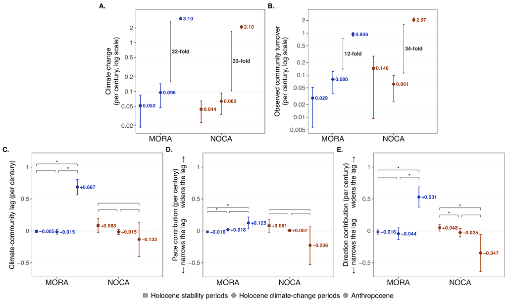

**Fig. 5. Rates of climate change, community turnover and climate–community lag, and the pace and direction contributions to the lag, in the Holocene and the Anthropocene.** For each park, the fitted mean and 95% confidence interval per century of the Holocene stability periods (squares), the Holocene climate-change periods (diamonds) and the Anthropocene plot pairs (circles), with the fitted mean printed beside each point: (A) the standardized climate change, the distance between the climates at the two ends of a lake-period or plot pair; (B) the observed community turnover, the distance the community moved in CCA space; (C) the climate-community lag, the change in mismatch between the two ends (M at t2 minus M at t1); (D) the pace contribution and (E) the direction contribution to the lag. Each contribution is the lag at the end of the period minus the lag the community would have had at the climate-predicted pace (D, keeping its own direction) or in the climate-predicted direction (E, keeping its own distance). A positive contribution means that the community’s own pace or direction widened the lag, a negative one that it narrowed the lag. C, D and E share one y scale, because all three are a change in mismatch in CCA distance per century over the same interval. A and B are on log axes, where equal distances are equal folds, and the arrow gives the fold between the Anthropocene and the Holocene climate-change means. C, D and E are on linear axes without folds. Their connectors show the three differences between period types within each park: on the lower level, the Holocene stability against the Holocene climate-change periods (left) and the Holocene climate-change periods against the Anthropocene (right), and on the upper level, the Holocene stability periods against the Anthropocene. A star marks a difference that differs from zero (two-sided t test, Holm-adjusted p < 0.05 across the six differences of each response, three per park). The intervals are unadjusted. Means come from the model response ~ period type × site, with an AR(1) correlation within each lake and weights for the number of samples at each end, fitted on 6 climate-change and 7 stability lake-periods and 328 plot pairs at MORA, and 5, 5 and 277 at NOCA. Lake-periods and plots whose observed or predicted position did not move have no pace or direction contribution: D and E hold 5 climate-change and 5 stability lake-periods at MORA. The lake-periods of the Holocene climate-change periods span 300 to 900 years, and those of the stability periods 300 to 2600 years, between t1 and t2. The Anthropocene plot pairs span 27.5 to 32.5 years between the midpoints of their two climate windows (about 29 years). Longer windows give lower rates, so the rates of the two eras are not on equal footing. The same quantities not divided by time are in Fig. S16. Units: the climate change in calibration standard deviations per century, the others in CCA distance per century. The Holocene climate is CHELSA-TraCE21k after the bias correction of Appendix S2.

**Quantities not divided by time.** The main text compares the rates per century (Fig. 5). The same models fitted on the quantities not divided by time give the means and differences in Fig. S16 (Tables S15 and S16).

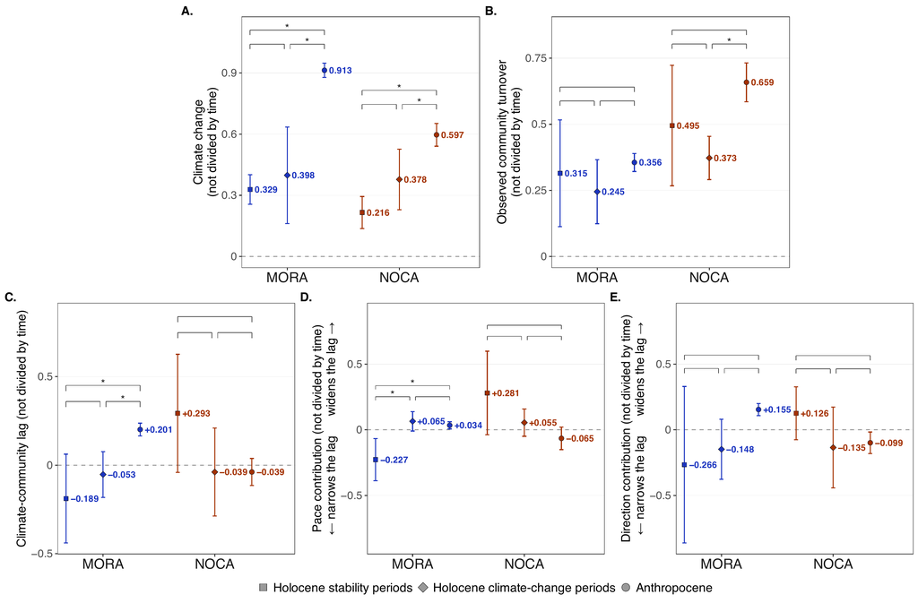

**Fig. S16. Climate change, community turnover, climate–community lag, and the pace and direction contributions not divided by time.** As Fig. 5 of the main text, not divided by time, i.e., between t1 and t2 of a lake-period or plot pair: (A) the standardized climate change between the two ends, (B) the observed community turnover, (C) the climate–community lag, (D) the pace contribution, and (E) the direction contribution to the lag. For each park, the fitted mean and 95% confidence interval of the Holocene stability periods (squares), the Holocene climate-change periods (diamonds), and the Anthropocene plot pairs (circles), with the fitted mean printed beside each point. All panels are on linear axes, and D and E share one y scale. Connectors show the three differences between period types within each park, and a star marks a difference that differs from zero (two-sided t test, Holm-adjusted p < 0.05 across the six differences of each quantity, three per park). The intervals are unadjusted. These quantities build up over a whole lake-period in the Holocene and over the few decades between the two surveys in the Anthropocene. The lake-periods of the Holocene climate-change periods span 300 to 900 years, and those of the stability periods 300 to 2600 years, between t1 and t2. The Anthropocene plot pairs span 27.5 to 32.5 years between the midpoints of their two climate windows (about 29 years). Units: the climate change in standard deviations of the legacy plots, the others in CCA distance.

**Turnover and lag by the duration of the lake-periods.** To test whether longer lake-periods had more turnover and larger lags only because they are longer, we compared the lake-periods among three classes of duration (Table S18).

**Table S18. Turnover and lag of the lake-periods by duration.** Means over the Holocene lake-periods of each park and class of duration. Turnover is the distance that the community moved in the climate–community space between t1 and t2. The size of the lag is the change in mismatch between t1 and t2 without its sign, and the lag is the same change with its sign. All three are in CCA distance and not divided by time.

| Park | Duration | Lake-periods | Stability / climate-change | Years | Mean turnover | Mean size of the lag | Mean lag |
| --- | --- | --- | --- | --- | --- | --- | --- |
| MORA | 1,000 years or more | 3 | 3 / 0 | 2100 to 2400 | 0.535 | 0.439 | -0.439 |
| MORA | 200 to 400 years | 6 | 2 / 4 | 300 to 400 | 0.200 | 0.089 | 0.008 |
| MORA | 500 to 900 years | 4 | 2 / 2 | 500 to 700 | 0.209 | 0.178 | -0.096 |
| NOCA | 1,000 years or more | 1 | 1 / 0 | 2600 to 2600 | 0.430 | 0.293 | 0.293 |
| NOCA | 200 to 400 years | 5 | 3 / 2 | 300 to 400 | 0.418 | 0.240 | 0.200 |
| NOCA | 500 to 900 years | 4 | 1 / 3 | 500 to 900 | 0.442 | 0.304 | -0.108 |

<sub>Table file: step5a_duration_classes.csv</sub>

At MORA, the 3 longest lake-periods (2,100 to 2,400 years) had a higher turnover than the shorter ones (mean of 0.535 against 0.200 for 200 to 400 years and 0.209 for 500 to 900 years). At NOCA, turnover did not increase with duration (0.418, 0.442, and 0.430, the last from a single lake-period). The size of the lag ranged from 0.089 to 0.439 at MORA and from 0.240 to 0.304 at NOCA among the classes. Turnover is the net movement of the community between t1 and t2, so movements back and forth within a lake-period do not add to it, and it does not increase in proportion to time. This is one reason why the rates of the long lake-periods are low.

**Model checks.** To check the models of the comparison among period types (see Methods of the main text), we report their fit (Table S19) and their residuals (Fig. S17). The coefficients of every model are on the **model details page →** 08_models.

**Table S19. Comparison among period types: fit of the models.** Units, number of lake-periods and plot pairs. AR(1), parameter of the first-order autoregressive correlation between successive lake-periods of a lake. The residual standard deviation (SD) of each period type and park is relative to that of the Anthropocene at MORA, and is multiplied by the square root of the variance from the number of samples at t1 and t2. Residual df, units with the coefficients subtracted. The residual SE is that of the Anthropocene at MORA for a variance of 1. The models were fitted with restricted maximum likelihood (REML), so that the log-likelihood and the AIC can only be compared among models with the same fixed effects. R² is descriptive (the residual sum of squares divided by the total sum of squares, subtracted from 1).

| Quantity | Units | Coefficients | Residual df | Residual SE | AR(1) | Residual SD by period type and park | Log-likelihood (REML) | AIC | Descriptive R² | Warnings |
| --- | --- | --- | --- | --- | --- | --- | --- | --- | --- | --- |
| Climate change rate | 628 | 6 | 622 | 0.672 | 0.026 | Anthropocene NOCA=1.754, Holocene-C MORA=0.064, Holocene-S MORA=0.047, Holocene-C NOCA=0.093, Holocene-S NOCA=0.064 | -955.567 | 1937.134 | 0.218 | none |
| Climate change (not divided by time) | 628 | 6 | 622 | 0.227 | -0.211 | Anthropocene NOCA=1.480, Holocene-C MORA=0.912, Holocene-S MORA=0.298, Holocene-C NOCA=1.360, Holocene-S NOCA=0.702 | -276.583 | 579.166 | 0.167 | none |
| Turnover rate | 628 | 6 | 622 | 0.586 | -0.558 | Anthropocene NOCA=2.345, Holocene-C MORA=0.059, Holocene-S MORA=0.033, Holocene-C NOCA=0.112, Holocene-S NOCA=0.397 | -952.621 | 1931.242 | 0.156 | none |
| Turnover (not divided by time) | 628 | 6 | 622 | 0.222 | -0.178 | Anthropocene NOCA=1.979, Holocene-C MORA=0.477, Holocene-S MORA=0.853, Holocene-C NOCA=0.770, Holocene-S NOCA=2.096 | -349.593 | 725.186 | 0.094 | none |
| Lag rate | 628 | 6 | 622 | 0.798 | -0.051 | Anthropocene NOCA=2.023, Holocene-C MORA=0.038, Holocene-S MORA=0.025, Holocene-C NOCA=0.104, Holocene-S NOCA=0.291 | -1101.602 | 2229.204 | 0.053 | none |
| Lag | 628 | 6 | 622 | 0.234 | 0.056 | Anthropocene NOCA=1.960, Holocene-C MORA=0.486, Holocene-S MORA=1.018, Holocene-C NOCA=2.268, Holocene-S NOCA=2.969 | -386.945 | 799.891 | 0.058 | none |
| Pace contribution | 480 | 6 | 474 | 0.532 | 0.203 | Anthropocene NOCA=2.945, Holocene-C MORA=0.024, Holocene-S MORA=0.013, Holocene-C NOCA=0.064, Holocene-S NOCA=0.392 | -715.246 | 1456.492 | 0.012 | none |
| Direction contribution | 480 | 6 | 474 | 0.909 | 0.686 | Anthropocene NOCA=1.652, Holocene-C MORA=0.073, Holocene-S MORA=0.035, Holocene-C NOCA=0.106, Holocene-S NOCA=0.085 | -849.535 | 1725.070 | 0.061 | none |
| Pace contribution (not divided by time) | 480 | 6 | 474 | 0.156 | 0.262 | Anthropocene NOCA=2.867, Holocene-C MORA=0.380, Holocene-S MORA=0.814, Holocene-C NOCA=1.371, Holocene-S NOCA=4.079 | -175.569 | 377.137 | 0.016 | none |
| Direction contribution (not divided by time) | 480 | 6 | 474 | 0.264 | 0.501 | Anthropocene NOCA=1.615, Holocene-C MORA=0.665, Holocene-S MORA=1.684, Holocene-C NOCA=2.113, Holocene-S NOCA=1.341 | -309.252 | 644.504 | 0.067 | none |

<sub>Table file: era_model_summary.csv</sub>

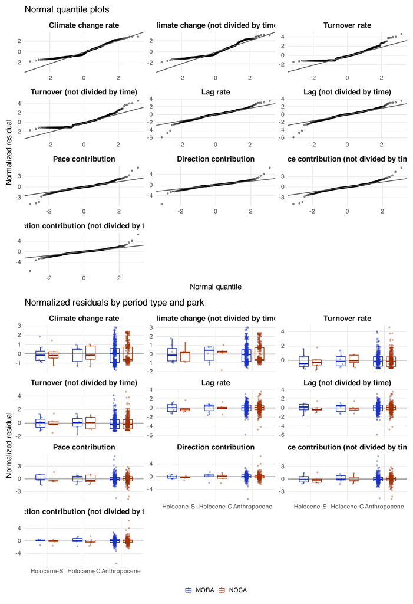

**Fig. S17. Residuals of the ten models of the comparison among period types.** Top: normal quantile plots of the normalized residuals, one for each quantity. Bottom: normalized residuals for each period type and park (points, with boxes for the quartiles). The models have no continuous explanatory variable, so the fitted values take one value for each period type and park, and the residuals for each group show what a plot against the fitted values would show. Turnover and turnover rate are positive by construction, and their residuals are skewed to the right. The residuals of the lag, the lag rate, and the pace and direction contributions have heavy tails, which come from a few Anthropocene plot pairs.

Stages and helpers: `R/pipeline/14_era_models.R`, `R/helpers/tracking_model_reporting.R` (period types), `R/helpers/reconstruction_models.R`, `R/figures/main_fig5_era_contrasts.R`.

# Pace and direction contributions (Q2)

**What and why.** The pace contribution and the direction contribution, defined with the lake-periods above, ask whether a lag comes from how far the community moved or from the direction it took. They are compared between the period types with the same era models as the lag (code, fit statistics and residuals in Q1: Table S19, Fig. S17).

**Result.**

Per century (Fig. 5D, E), the MORA pace contribution of the Anthropocene does not differ from Holocene-C (+0.11 (0.01 to 0.20, Holm p = 0.103)) and exceeds that of Holocene-S (+0.14 (0.05 to 0.23, Holm p = 0.017)), and the MORA direction contribution exceeds that of Holocene-C (+0.58 (0.39 to 0.76, Holm p < 0.001)) and exceeds that of Holocene-S (+0.55 (0.38 to 0.71, Holm p < 0.001)). At NOCA the per-century pace contribution does not differ from either Holocene type (-0.23 (-0.54 to 0.07, Holm p = 0.260) against Holocene-C, -0.31 (-0.63 to 0.01, Holm p = 0.178) against Holocene-S), and the direction contribution does not differ from Holocene-C (-0.32 (-0.62 to -0.03, Holm p = 0.066)) and falls below that of Holocene-S (-0.39 (-0.69 to -0.10, Holm p = 0.026)). Not divided by time (Fig. S16D, E), 1 of the 8 contrasts between the Anthropocene and a Holocene period type is significant after the adjustment: pace contribution (not divided by time) at MORA, Anthropocene - Holocene-S (+0.26 (0.10 to 0.42, Holm p = 0.009)). The Anthropocene contributions are large per century mainly because they build up over a few decades.

Stages and helpers: `R/pipeline/14_era_models.R`, `R/helpers/tracking_model_reporting.R` (period types), `R/figures/main_fig5_era_contrasts.R`.

# Associations with fire (Q3)

**What and why.** Within the Holocene lake-periods, does a period with more climate change, or more fire, end with a larger lag, and with better or worse pace and direction? Each response is modelled on the park, the climate change rate and fire activity together. The lake-periods of one lake come from the same core and catchment, so their errors can be related. An AR(1) term within each lake carries that, counted in climate periods: two lake-periods one period apart are correlated by φ, two periods apart by φ², also where the period between them has no lake-period. Ends that rest on a single sample are noisier, so each row is weighted by the sampling variance of its two ends, and the parks keep different residual spread. In the Anthropocene the same responses are compared between burned and unburned plots, in a model with the park and fire (burned or not). Only NOCA plots burned between the two surveys, so the fire comparison is a NOCA comparison.

**How it is calculated.**

```r
# R/pipeline/15_predictor_models.R
  # Holocene lake-periods only. Does the response go with more climate change
  # or more fire? Fitted twice: per century (lag rate, pace contribution, direction
  # contribution) with climate = climate_rate, the climate change rate, and as totals
  # not divided by time (lag, pace and direction contribution totals) with
  # climate = climate_change, the climate change between the two ends.
  #   site: a separate level for each park;
  #   climate: the slope per unit of climate change (rate or total);
  #   fire_activity: the slope per accepted fire event per century per core.
  # Lake-periods of a lake are correlated, AR(1) within lake on unit_index, the
  # position of the lake-period's climate period (C1 = 1 to S5 = 10): two
  # lake-periods k periods apart correlate by phi^k, also across missing periods.
  # varIdent lets the parks keep a different spread, and varFixed gives ends
  # resting on single samples less weight (endpoint_var = 1/n_start + 1/n_end).
  model = reformulate(c('site', climate, 'fire_activity'), response = 'estimate')
  captured = reconstruction_capture(function() gls(model,
    correlation = corAR1(form = ~ unit_index | lake),
    weights = varComb(varIdent(form = ~ 1 | site), varFixed(~ endpoint_var)),
    data = d, method = 'REML', control = glsControl(msMaxIter = 500)))
```

```r
# R/pipeline/15_predictor_models.R
  # Anthropocene plot pairs only: the same responses against site and burned
  # (whether the plot burned between the two surveys). Plots are independent,
  # each park keeps its own spread.
  captured = reconstruction_capture(function() gls(estimate ~ site + burned,
    weights = varIdent(form = ~ 1 | site), data = da, method = 'REML'))
```

**Result.**

**Table S20. Associations with fire: coefficients of the models.** Holocene: models of the lake-periods with park, climate change rate (or climate change, for the quantities not divided by time), and fire activity as fixed effects, a first-order autoregressive correlation within each lake, and weights for the number of samples at t1 and t2. Anthropocene: models of the plot pairs with park and fire (burned or unburned) as fixed effects (see Methods of the main text). Terms: Park (NOCA), difference between NOCA and MORA; Burned, difference between burned and unburned plot pairs. Estimates are in CCA distance (per century for the rates) for one unit of the term. SE, standard error. Two-sided t-tests on the residual degrees of freedom (df) of the model, with 95% confidence intervals (CI). n, number of lake-periods or plot pairs. R² is descriptive. The fit of the models is given in Table S21.

| Quantity | Era | Term | Estimate | SE | df | t | 95% CI | p | n | R² |
| --- | --- | --- | --- | --- | --- | --- | --- | --- | --- | --- |
| Lag rate | Holocene | (Intercept) | 0.010 | 0.018 | 19 | 0.536 | -0.028 to 0.047 | 0.598 | 23 | 0.228 |
| Lag rate | Holocene | Park (NOCA) | 0.091 | 0.046 | 19 | 1.991 | -0.005 to 0.187 | 0.061 | 23 | 0.228 |
| Lag rate | Holocene | climate_rate | -0.036 | 0.190 | 19 | -0.191 | -0.435 to 0.362 | 0.850 | 23 | 0.228 |
| Lag rate | Holocene | fire_activity | -0.103 | 0.071 | 19 | -1.451 | -0.252 to 0.046 | 0.163 | 23 | 0.228 |
| Lag rate | Anthropocene | (Intercept) | 0.687 | 0.062 | 602 | 11.024 | 0.565 to 0.810 | 0.000 | 605 | 0.052 |
| Lag rate | Anthropocene | Park (NOCA) | -0.798 | 0.157 | 602 | -5.089 | -1.105 to -0.490 | 0.000 | 605 | 0.052 |
| Lag rate | Anthropocene | Burned | -0.260 | 0.489 | 602 | -0.533 | -1.220 to 0.699 | 0.594 | 605 | 0.052 |
| Pace contribution | Holocene | (Intercept) | -0.006 | 0.009 | 16 | -0.672 | -0.025 to 0.013 | 0.511 | 20 | -0.032 |
| Pace contribution | Holocene | Park (NOCA) | 0.014 | 0.031 | 16 | 0.452 | -0.052 to 0.080 | 0.657 | 20 | -0.032 |
| Pace contribution | Holocene | climate_rate | 0.016 | 0.083 | 16 | 0.193 | -0.161 to 0.193 | 0.849 | 20 | -0.032 |
| Pace contribution | Holocene | fire_activity | 0.033 | 0.044 | 16 | 0.741 | -0.061 to 0.127 | 0.470 | 20 | -0.032 |
| Pace contribution | Anthropocene | (Intercept) | 0.125 | 0.047 | 457 | 2.638 | 0.032 to 0.218 | 0.009 | 460 | 0.034 |
| Pace contribution | Anthropocene | Park (NOCA) | -0.246 | 0.166 | 457 | -1.482 | -0.571 to 0.080 | 0.139 | 460 | 0.034 |
| Pace contribution | Anthropocene | Burned | -1.292 | 0.555 | 457 | -2.325 | -2.383 to -0.200 | 0.020 | 460 | 0.034 |
| Direction contribution | Holocene | (Intercept) | 0.018 | 0.032 | 16 | 0.570 | -0.049 to 0.086 | 0.576 | 20 | 0.245 |
| Direction contribution | Holocene | Park (NOCA) | 0.068 | 0.039 | 16 | 1.761 | -0.014 to 0.151 | 0.097 | 20 | 0.245 |
| Direction contribution | Holocene | climate_rate | -0.324 | 0.232 | 16 | -1.398 | -0.816 to 0.168 | 0.181 | 20 | 0.245 |
| Direction contribution | Holocene | fire_activity | -0.109 | 0.032 | 16 | -3.416 | -0.176 to -0.041 | 0.004 | 20 | 0.245 |
| Direction contribution | Anthropocene | (Intercept) | 0.531 | 0.081 | 457 | 6.559 | 0.372 to 0.691 | 0.000 | 460 | 0.062 |
| Direction contribution | Anthropocene | Park (NOCA) | -0.894 | 0.174 | 457 | -5.136 | -1.236 to -0.552 | 0.000 | 460 | 0.062 |
| Direction contribution | Anthropocene | Burned | 0.189 | 0.539 | 457 | 0.350 | -0.870 to 1.248 | 0.727 | 460 | 0.062 |
| Lag (not divided by time) | Holocene | (Intercept) | 0.074 | 0.152 | 19 | 0.486 | -0.244 to 0.391 | 0.633 | 23 | 0.240 |
| Lag (not divided by time) | Holocene | Park (NOCA) | 0.381 | 0.201 | 19 | 1.895 | -0.040 to 0.802 | 0.073 | 23 | 0.240 |
| Lag (not divided by time) | Holocene | climate_change | -0.404 | 0.372 | 19 | -1.086 | -1.183 to 0.375 | 0.291 | 23 | 0.240 |
| Lag (not divided by time) | Holocene | fire_activity | -0.343 | 0.311 | 19 | -1.102 | -0.994 to 0.308 | 0.284 | 23 | 0.240 |
| Lag (not divided by time) | Anthropocene | (Intercept) | 0.201 | 0.018 | 602 | 11.004 | 0.165 to 0.237 | 0.000 | 605 | 0.054 |
| Lag (not divided by time) | Anthropocene | Park (NOCA) | -0.234 | 0.045 | 602 | -5.215 | -0.322 to -0.146 | 0.000 | 605 | 0.054 |
| Lag (not divided by time) | Anthropocene | Burned | -0.073 | 0.139 | 602 | -0.529 | -0.346 to 0.199 | 0.597 | 605 | 0.054 |
| Pace contribution (not divided by time) | Holocene | (Intercept) | -0.064 | 0.117 | 16 | -0.551 | -0.312 to 0.183 | 0.589 | 20 | 0.192 |
| Pace contribution (not divided by time) | Holocene | Park (NOCA) | 0.360 | 0.166 | 16 | 2.170 | 0.008 to 0.713 | 0.045 | 20 | 0.192 |
| Pace contribution (not divided by time) | Holocene | climate_change | 0.106 | 0.269 | 16 | 0.393 | -0.464 to 0.675 | 0.700 | 20 | 0.192 |
| Pace contribution (not divided by time) | Holocene | fire_activity | -0.324 | 0.286 | 16 | -1.133 | -0.930 to 0.282 | 0.274 | 20 | 0.192 |
| Pace contribution (not divided by time) | Anthropocene | (Intercept) | 0.034 | 0.014 | 457 | 2.473 | 0.007 to 0.062 | 0.014 | 460 | 0.034 |
| Pace contribution (not divided by time) | Anthropocene | Park (NOCA) | -0.069 | 0.047 | 457 | -1.468 | -0.162 to 0.023 | 0.143 | 460 | 0.034 |
| Pace contribution (not divided by time) | Anthropocene | Burned | -0.367 | 0.158 | 457 | -2.326 | -0.678 to -0.057 | 0.020 | 460 | 0.034 |
| Direction contribution (not divided by time) | Holocene | (Intercept) | -0.031 | 0.228 | 16 | -0.137 | -0.515 to 0.452 | 0.892 | 20 | 0.121 |
| Direction contribution (not divided by time) | Holocene | Park (NOCA) | 0.312 | 0.229 | 16 | 1.360 | -0.174 to 0.798 | 0.193 | 20 | 0.121 |
| Direction contribution (not divided by time) | Holocene | climate_change | -0.216 | 0.422 | 16 | -0.511 | -1.111 to 0.680 | 0.616 | 20 | 0.121 |
| Direction contribution (not divided by time) | Holocene | fire_activity | -0.385 | 0.225 | 16 | -1.716 | -0.862 to 0.091 | 0.105 | 20 | 0.121 |
| Direction contribution (not divided by time) | Anthropocene | (Intercept) | 0.155 | 0.024 | 457 | 6.563 | 0.108 to 0.201 | 0.000 | 460 | 0.062 |
| Direction contribution (not divided by time) | Anthropocene | Park (NOCA) | -0.258 | 0.050 | 457 | -5.182 | -0.355 to -0.160 | 0.000 | 460 | 0.062 |
| Direction contribution (not divided by time) | Anthropocene | Burned | 0.054 | 0.153 | 457 | 0.349 | -0.248 to 0.355 | 0.727 | 460 | 0.062 |

<sub>Table file: step5_explanatory_models.csv</sub>

In the Holocene, faster climate change did not go with the lag rate (-0.04 (-0.43 to 0.36)) and did not go with the pace contribution (+0.02 (-0.16 to 0.19)). More frequent fire did not go with the lag rate (-0.10 (-0.25 to 0.05)) and went with a smaller direction contribution (-0.11 (-0.18 to -0.04)). The slopes are in CCA distance per century for one more standardized unit of climate change per century, or for one more event per century per core. The fire values of the two parks overlap in 5 of the 23 lake-periods. The site term absorbs the difference between the parks, so the fire slope comes from the variation within each park (MORA 0.00 to 0.42, NOCA 0.33 to 1.25 events per century per core).

The same models on the responses not divided by time (Fig. S18) use the climate change between the two ends in place of its rate, and the slopes are in CCA distance per standardized unit of climate change or per event per century per core. More climate change did not go with the lag (-0.40 (-1.18 to 0.37)), did not go with the pace contribution (+0.11 (-0.46 to 0.68)) and did not go with the direction contribution (-0.22 (-1.11 to 0.68)). More fire did not go with the lag (-0.34 (-0.99 to 0.31)), did not go with the pace contribution (-0.32 (-0.93 to 0.28)) and did not go with the direction contribution (-0.39 (-0.86 to 0.09)). Of the 12 Holocene climate and fire slopes, 1 has an interval that excludes zero. They rest on 23 lake-periods (20 for the pace and direction contributions). Without the correction of the Holocene climate, the one slope whose interval excludes zero changes its sign (Appendix S4), so it is fragile. In the Anthropocene (burned minus unburned plots), burned plots had lower values for the pace contribution (-1.29, -2.38 to -0.20), the pace contribution (not divided by time) (-0.37, -0.68 to -0.06). In addition, burned and unburned plots did not differ in the lag rate (-0.26, -1.22 to 0.70), the direction contribution (+0.19, -0.87 to 1.25), the lag (not divided by time) (-0.07, -0.35 to 0.20), the direction contribution (not divided by time) (+0.05, -0.25 to 0.35). Fire activity stays a frequency in both forms, because a count of events would grow with the length of the lake-period.

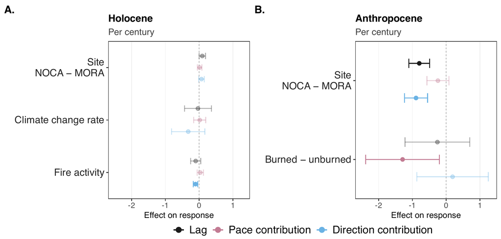

**Fig. 6. Climate and fire associations.** Model slopes with conditional 95% confidence intervals for the lag (black), the pace contribution (pink) and the direction contribution (blue) per century, side by side for each term, in the colours of Fig. 1. Faded estimates have intervals that include zero. The two panels share one x scale. (A) Holocene lake-periods, model response ~ site + climate change rate + fire activity with an AR(1) correlation within each lake and weights for the number of samples at each end: 13 MORA and 10 NOCA lake-periods for the lag, and 10 and 10 for pace and direction. The climate slope is per standardized unit of climate change per century, and the fire slope per accepted event per century per covered core. (B) Anthropocene plot pairs, model response ~ site + burned with park-specific variances: 605 plot pairs for the lag and 460 for pace and direction. The descriptive R² and the degrees of freedom of each model are in Tables S20 and S21. The same models on the responses not divided by time are in Fig. S18. Both panels also show the site term (NOCA minus MORA). The lake-periods of the Holocene climate-change periods span 300 to 900 years, and those of the stability periods 300 to 2600 years, between t1 and t2. The Anthropocene plot pairs span 27.5 to 32.5 years between the midpoints of their two climate windows (about 29 years). Slopes are in CCA distance per century per unit of the term.

**Associations not divided by time.** The main text gives the associations per century (Fig. 6). The same models on the responses not divided by time, with the climate change between the two ends in place of its rate, give the slopes in Fig. S18.

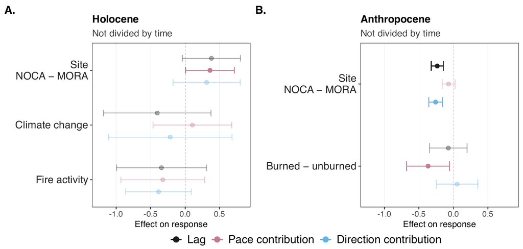

**Fig. S18. Climate and fire associations not divided by time.** As Fig. 6 of the main text, for the lag, the pace contribution, and the direction contribution not divided by time: the change in mismatch between the two ends, or the observed mismatch at t2, from which the mismatch with the climate-predicted distance (pace) or the climate-predicted direction (direction) was subtracted. Model slopes with conditional 95% confidence intervals, the lag in black, the pace contribution in pink, and the direction contribution in blue. Faded estimates have intervals that include zero, and the two panels share one x scale. (A) Holocene lake-periods, models with park, climate change, and fire activity as explanatory variables, where climate change is the standardized climate change between the two ends, with an AR(1) correlation within each lake and weights for the number of samples at each end. (B) Anthropocene plot pairs, models with park and burning (burned or unburned) as explanatory variables, with park-specific variances. The climate slope is per standardized unit of climate change, and the fire slope per fire event per century and per charcoal record. Both panels also show the park (the difference between NOCA and MORA). Slopes are in CCA distance per unit of the term. The lake-periods of the Holocene climate-change periods span 300 to 900 years, and those of the stability periods 300 to 2600 years, between t1 and t2. The Anthropocene plot pairs span 27.5 to 32.5 years between the midpoints of their two climate windows (about 29 years).

**Model checks.** The fit of these models is given in Table S21. The rows left out are on the **model details page →** 08_models.

**Table S21. Associations with fire: fit of the models.** MORA and NOCA, number of lake-periods or plot pairs of each park. AR(1), parameter of the first-order autoregressive correlation within each lake. Residual df, lake-periods or plot pairs with the coefficients subtracted. The residual SE is that of MORA (for a variance of 1 in the Holocene models). The models were fitted with restricted maximum likelihood (REML), so that the log-likelihood and the AIC can only be compared among models with the same fixed effects. R² is descriptive.

| Quantity | Era | Model | MORA | NOCA | Coefficients | Residual df | Residual SE | AR(1) | SD ratio NOCA/MORA | Log-likelihood (REML) | AIC | Descriptive R² | Warnings |
| --- | --- | --- | --- | --- | --- | --- | --- | --- | --- | --- | --- | --- | --- |
| Lag rate | Holocene | site + climate_rate + fire_activity | 13 | 10 | 4 | 19 | 0.026 | -0.089 | 6.780 | 27.332 | -40.664 | 0.228 | none |
| Lag rate | Anthropocene | site + burned | 328 | 277 | 3 | 602 | 1.129 | — | 2.026 | -1128.711 | 2267.422 | 0.052 | none |
| Pace contribution | Holocene | site + climate_rate + fire_activity | 10 | 10 | 4 | 16 | 0.012 | -0.495 | 16.592 | 26.595 | -39.190 | -0.032 | none |
| Pace contribution | Anthropocene | site + burned | 252 | 208 | 3 | 457 | 0.753 | — | 2.914 | -745.940 | 1501.879 | 0.034 | none |
| Direction contribution | Holocene | site + climate_rate + fire_activity | 10 | 10 | 4 | 16 | 0.042 | 0.494 | 2.149 | 25.267 | -36.533 | 0.245 | none |
| Direction contribution | Anthropocene | site + burned | 252 | 208 | 3 | 457 | 1.286 | — | 1.656 | -874.090 | 1758.179 | 0.062 | none |
| Lag | Holocene | site + climate_change + fire_activity | 13 | 10 | 4 | 19 | 0.196 | -0.045 | 3.082 | -6.260 | 26.520 | 0.240 | none |
| Lag | Anthropocene | site + burned | 328 | 277 | 3 | 602 | 0.331 | — | 1.962 | -381.940 | 773.880 | 0.054 | none |
| Pace contribution (not divided by time) | Holocene | site + climate_change + fire_activity | 10 | 10 | 4 | 16 | 0.139 | -0.446 | 4.147 | -1.638 | 17.276 | 0.192 | none |
| Pace contribution (not divided by time) | Anthropocene | site + burned | 252 | 208 | 3 | 457 | 0.220 | — | 2.837 | -178.059 | 366.118 | 0.034 | none |
| Direction contribution (not divided by time) | Holocene | site + climate_change + fire_activity | 10 | 10 | 4 | 16 | 0.292 | 0.279 | 1.666 | -6.511 | 27.022 | 0.121 | none |
| Direction contribution (not divided by time) | Anthropocene | site + burned | 252 | 208 | 3 | 457 | 0.374 | — | 1.619 | -305.018 | 620.036 | 0.062 | none |

<sub>Table file: explanatory_model_performance.csv</sub>

Stages and helpers: `R/pipeline/15_predictor_models.R`, `R/helpers/reconstruction_models.R`, `R/figures/main_fig6_climate_fire_associations.R`.

# Species contributions (Q4)

**What and why.** The observed movement of a community between t1 and t2 is the sum of one vector per species: the change in the species’ share times the species’ fixed position in the CCA plane (asserted). Projecting each species’ vector on the direction in which the climate-predicted position moved says how far that species carried the community along with the climate. This is `contrib_climate`, per century of the interval between the two vegetation samples. A positive value means the species moved the community in the climate-predicted direction, a negative value that it moved it against that direction. Where the observed or the climate-predicted position did not move, the direction is undefined, and so is the contribution, so those lake-periods and plot pairs are left out.

**How it is calculated.**

```r
# R/helpers/cca_transition_contributions.R
step6_species_contributions = function(context, first, last, positions, endpoints, dt, lag_dt) {
  # rows: one row per unit (a Holocene lake-period or an Anthropocene plot pair)
  # and species. A species' vector is its change in share between t1 and t2
  # times its fixed position in the CCA plane; the vectors of a unit add up to
  # the observed movement (checked). parallel_contribution is the vector
  # projected on the direction in which the climate-predicted position moved.
  # (step6_lag_contributions also adds contrib_lag, which is not reported.)
  rows = step6_lag_contributions(context, first, last, positions, endpoints, lag_dt)
  index = rep(seq_len(nrow(context)), each = ncol(first))
  # Where the observed or the predicted position did not move, the direction is
  # undefined (epsilon rule), and so is the contribution.
  defined = endpoints$direction_defined[index]
  # contrib_climate, per century of the vegetation interval dt: positive, the
  # species moved the community in the climate-predicted direction; negative,
  # against it.
  rows$contrib_climate = ifelse(defined, rows$parallel_contribution * 100 / dt[index], NA_real_)
  lag_columns = c('lag_projection', 'contrib_lag')
  rows[c(setdiff(names(rows), c(lag_columns, 'contrib_climate')), 'contrib_climate', lag_columns)]
}
```

```r
# R/pipeline/16_contributions.R
# For one species in one park and period type, x holds its contribution in
# every lake-period (or plot pair). The result is the plain mean with a 95%
# t-interval: mean plus or minus t(0.975, n - 1) times the standard error
# sd / sqrt(n). With a single value the interval is undefined.
group_mean = function(x) {
  n = length(x); m = mean(x); se = if (n > 1) sd(x) / sqrt(n) else NA_real_
  q = if (n > 1) qt(.975, n - 1) else NA_real_
  tibble(n, estimate = m, std_error = se, conf_low = m - q * se, conf_high = m + q * se,
    interval_defined = n > 1 && is.finite(se) && se > 0)
}
```

**Result.**

**Table S22. Species contributions in the climate-predicted direction per century.** Mean and 95% confidence interval (t-interval) in CCA distance per century, for each species, park, and period type: how far the species moved the community in the climate-predicted direction (positive values) or against it (negative values). “absent”: the species was not found in that park and period type. Lake-periods and plot pairs in which the observed or the climate-predicted position did not move are left out.

| Species | Park | Holocene-S | Holocene-C | Anthropocene |
| --- | --- | --- | --- | --- |
| Abies amabilis/grandis | MORA | -0.000 (-0.003 to 0.003) | +0.005 (-0.007 to 0.017) | -0.032 (-0.061 to -0.003) |
| Abies amabilis/grandis | NOCA | +0.001 (-0.002 to 0.004) | +0.001 (-0.002 to 0.004) | +0.023 (-0.008 to 0.054) |
| Abies lasiocarpa | MORA | +0.002 (-0.008 to 0.011) | -0.000 (-0.023 to 0.023) | -0.009 (-0.044 to 0.026) |
| Abies lasiocarpa | NOCA | +0.061 (-0.042 to 0.163) | -0.029 (-0.075 to 0.018) | -0.028 (-0.168 to 0.112) |
| Abies procera | MORA | -0.003 (-0.007 to 0.001) | +0.002 (-0.005 to 0.009) | +0.030 (-0.001 to 0.061) |
| Abies procera | NOCA | absent | absent | absent |
| Callitropsis nootkatensis | MORA | +0.003 (-0.001 to 0.006) | -0.030 (-0.114 to 0.054) | -0.003 (-0.072 to 0.065) |
| Callitropsis nootkatensis | NOCA | -0.007 (-0.024 to 0.011) | -0.008 (-0.030 to 0.014) | +0.061 (0.002 to 0.119) |
| Picea engelmannii | MORA | absent | absent | -0.005 (-0.021 to 0.010) |
| Picea engelmannii | NOCA | -0.003 (-0.012 to 0.006) | +0.001 (-0.002 to 0.003) | -0.026 (-0.097 to 0.044) |
| Pinus albicaulis | MORA | absent | absent | +0.006 (-0.002 to 0.013) |
| Pinus albicaulis | NOCA | absent | absent | +0.264 (0.094 to 0.434) |
| Pinus contorta | MORA | +0.008 (-0.002 to 0.018) | -0.003 (-0.013 to 0.008) | -0.003 (-0.014 to 0.009) |
| Pinus contorta | NOCA | -0.004 (-0.023 to 0.016) | +0.008 (-0.013 to 0.030) | +0.040 (-0.050 to 0.130) |
| Pinus monticola | MORA | -0.001 (-0.008 to 0.006) | -0.001 (-0.007 to 0.004) | -0.044 (-0.062 to -0.027) |
| Pinus monticola | NOCA | +0.008 (-0.043 to 0.059) | +0.001 (-0.013 to 0.014) | +0.005 (-0.032 to 0.042) |
| Pinus ponderosa | MORA | absent | absent | +0.009 (-0.009 to 0.027) |
| Pinus ponderosa | NOCA | absent | absent | +0.207 (-0.054 to 0.468) |
| Pseudotsuga menziesii | MORA | +0.001 (-0.003 to 0.005) | -0.010 (-0.035 to 0.016) | -0.052 (-0.101 to -0.002) |
| Pseudotsuga menziesii | NOCA | -0.008 (-0.025 to 0.009) | -0.005 (-0.027 to 0.017) | -0.023 (-0.101 to 0.055) |
| Thuja plicata | MORA | absent | absent | +0.005 (-0.022 to 0.031) |
| Thuja plicata | NOCA | -0.002 (-0.007 to 0.002) | -0.004 (-0.013 to 0.006) | +0.038 (-0.018 to 0.094) |
| Tsuga heterophylla | MORA | +0.004 (-0.013 to 0.022) | -0.000 (-0.024 to 0.024) | -0.051 (-0.072 to -0.030) |
| Tsuga heterophylla | NOCA | +0.007 (-0.014 to 0.028) | +0.001 (-0.002 to 0.004) | +0.108 (0.060 to 0.155) |
| Tsuga mertensiana | MORA | +0.001 (-0.002 to 0.004) | +0.014 (-0.014 to 0.042) | +0.011 (-0.017 to 0.039) |
| Tsuga mertensiana | NOCA | +0.002 (-0.002 to 0.005) | absent | +0.049 (-0.011 to 0.109) |

<sub>Table file: step6_species_means.csv</sub>

The species vectors add up to the observed movement for every lake-period and plot pair (asserted).

In the Holocene every species mean is close to zero in both parks (largest absolute value 0.061 CCA distance per century, Fig. S19A). None of the 37 Holocene intervals excludes zero. Each Holocene mean rests on 5 lake-periods. In the Anthropocene, a species’ interval excludes zero more often. At MORA, among the species whose interval excludes zero, none moved the communities in the climate-predicted direction, and 4 moved the communities against that direction (*Abies amabilis/grandis* (-0.032), *Pinus monticola* (-0.044), *Pseudotsuga menziesii* (-0.052), *Tsuga heterophylla* (-0.051)). At NOCA, among the species whose interval excludes zero, 3 moved the communities in the climate-predicted direction (*Callitropsis nootkatensis* (+0.061), *Pinus albicaulis* (+0.264), *Tsuga heterophylla* (+0.108)), and none moved the communities against that direction. Values are in CCA distance per century.

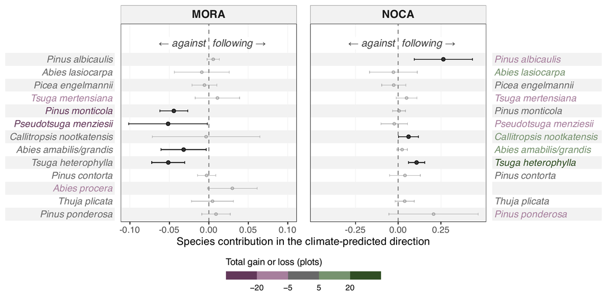

**Fig. 7. Species contributions in the climate-predicted direction in the Anthropocene.** Each species’ vector is its change in share between the legacy survey and the resurvey of a plot, times its fixed position in the CCA plane. The vectors are projected on the direction in which the climate-predicted position moved. Labels at the top of each panel give the meaning of each side of zero: a species moved the community against or following the climate-predicted direction. Plot pairs whose observed or climate-predicted position did not move are left out. Values are per century of the interval between the two vegetation samples. Circles are means over the plot pairs (burned and unburned together), each with its 95% t-interval. Means whose interval excludes zero are large and dark, and means whose interval includes zero are small and faded, with faded intervals. Each park has its own x scale, symmetric around zero. Species are ordered by the maximum elevation of the plots where they occur (the 605 plot pairs, both surveys, both parks), the highest at the top. The names stand on the left of the MORA panel and on the right of the NOCA panel. Each name is coloured by the total gain or loss of the species in that park: the number of plot pairs in which it occurred at the resurvey minus the number in which it occurred at the legacy survey. Dark plum, a loss of more than 20 plots; light plum, a loss of 5 to 20; grey, a gain or loss of fewer than 5; light green, a gain of 5 to 20; dark green, a gain of more than 20 (key below the figure). *Abies procera* does not occur in the NOCA plot pairs. The Holocene species contributions are drawn in Fig. S19A. The Anthropocene plot pairs span 27.5 to 32.5 years between the midpoints of their two climate windows (about 29 years). Contributions are in CCA distance per century.

**Species contributions not divided by time.** Per century, the species contributions of the Holocene are small partly because the lake-periods are long, and those of the Anthropocene are large partly because the time between the two surveys is short. To test whether this explains the difference between the two eras, we also calculated the species contributions without dividing by time (Fig. S19B, Table S23).

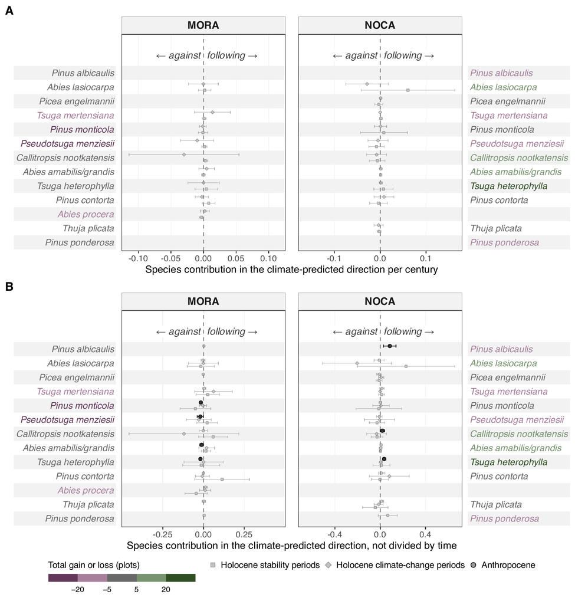

Not divided by time, the Holocene species contributions were at least as large as those of the Anthropocene (mean size 0.034 against 0.008 at MORA, and 0.039 against 0.023 at NOCA, in CCA distance). However, they varied so much among the few lake-periods that none of the 37 Holocene means had a confidence interval that excluded zero, not divided by time or per century. In the Anthropocene, the same seven means excluded zero either way.

**Fig. S19. Species contributions in the climate-predicted direction in the Holocene per century (A) and in all period types not divided by time (B).** How far each species moved the community in the climate-predicted direction (positive values) or against it (negative values), as in Fig. 7 of the main text. (A) The Holocene means per century, which Fig. 7 leaves out. (B) The contribution of each species between t1 and t2, not per century, in the three period types. Squares, Holocene stability periods; diamonds, Holocene climate-change periods; circles, Anthropocene plot pairs (burned and unburned together). Means with 95% confidence intervals (t-intervals). Means whose interval excludes zero are large and dark, and means whose interval includes zero are small and faded, with faded intervals. A species with no Holocene symbols in a park is absent from that park’s Holocene record. Species are ordered as in Fig. 7, by the maximum elevation of the plots where they occur, the highest at the top. As in Fig. 7, the names stand on the left of the MORA panels and on the right of the NOCA panels, and each is coloured by the total gain or loss of the species in that park: the number of plot pairs in which it occurred at the resurvey minus the number in which it occurred at the legacy survey, in five steps from a loss of more than 20 plots (dark plum) to a gain of more than 20 (dark green; key below the figure). Each park has its own x scale, symmetric around zero. The lake-periods of the Holocene climate-change periods span 300 to 900 years, and those of the stability periods 300 to 2600 years, between t1 and t2. The Anthropocene plot pairs span 27.5 to 32.5 years between the midpoints of their two climate windows (about 29 years). Contributions are in CCA distance per century (A) and in CCA distance (B).

**Table S23. Species contributions in the climate-predicted direction not divided by time.** Mean and 95% confidence interval (t-interval) in CCA distance, for each species, park, and period type. Columns as in Table S22.

| Species | Park | Holocene-S | Holocene-C | Anthropocene |
| --- | --- | --- | --- | --- |
| Abies amabilis/grandis | MORA | +0.015 (-0.014 to 0.043) | +0.019 (-0.029 to 0.067) | -0.012 (-0.023 to -0.001) |
| Abies amabilis/grandis | NOCA | +0.003 (-0.007 to 0.012) | +0.004 (-0.009 to 0.017) | +0.007 (-0.003 to 0.017) |
| Abies lasiocarpa | MORA | -0.017 (-0.100 to 0.066) | -0.001 (-0.092 to 0.091) | -0.003 (-0.016 to 0.010) |
| Abies lasiocarpa | NOCA | +0.228 (-0.202 to 0.658) | -0.205 (-0.510 to 0.101) | -0.009 (-0.054 to 0.035) |
| Abies procera | MORA | -0.045 (-0.114 to 0.023) | +0.010 (-0.024 to 0.044) | +0.012 (-0.000 to 0.024) |
| Abies procera | NOCA | absent | absent | absent |
| Callitropsis nootkatensis | MORA | +0.059 (-0.030 to 0.148) | -0.120 (-0.458 to 0.217) | -0.001 (-0.027 to 0.024) |
| Callitropsis nootkatensis | NOCA | -0.028 (-0.080 to 0.024) | -0.031 (-0.119 to 0.056) | +0.019 (0.001 to 0.038) |
| Picea engelmannii | MORA | absent | absent | -0.002 (-0.008 to 0.004) |
| Picea engelmannii | NOCA | -0.010 (-0.036 to 0.017) | +0.008 (-0.015 to 0.031) | -0.008 (-0.031 to 0.014) |
| Pinus albicaulis | MORA | absent | absent | +0.002 (-0.001 to 0.005) |
| Pinus albicaulis | NOCA | absent | absent | +0.085 (0.030 to 0.139) |
| Pinus contorta | MORA | +0.114 (-0.054 to 0.282) | -0.008 (-0.050 to 0.035) | -0.001 (-0.006 to 0.003) |
| Pinus contorta | NOCA | -0.002 (-0.077 to 0.073) | +0.080 (-0.096 to 0.257) | +0.013 (-0.016 to 0.041) |
| Pinus monticola | MORA | -0.050 (-0.144 to 0.044) | -0.004 (-0.026 to 0.019) | -0.017 (-0.023 to -0.010) |
| Pinus monticola | NOCA | -0.012 (-0.214 to 0.190) | +0.006 (-0.067 to 0.078) | +0.002 (-0.010 to 0.013) |
| Pinus ponderosa | MORA | absent | absent | +0.004 (-0.003 to 0.010) |
| Pinus ponderosa | NOCA | absent | absent | +0.066 (-0.017 to 0.150) |
| Pseudotsuga menziesii | MORA | +0.022 (-0.042 to 0.085) | -0.029 (-0.106 to 0.047) | -0.020 (-0.039 to -0.000) |
| Pseudotsuga menziesii | NOCA | -0.028 (-0.095 to 0.039) | -0.006 (-0.139 to 0.127) | -0.008 (-0.032 to 0.017) |
| Thuja plicata | MORA | absent | absent | +0.002 (-0.008 to 0.012) |
| Thuja plicata | NOCA | -0.043 (-0.155 to 0.069) | -0.014 (-0.054 to 0.025) | +0.012 (-0.006 to 0.030) |
| Tsuga heterophylla | MORA | -0.014 (-0.128 to 0.100) | -0.000 (-0.120 to 0.120) | -0.019 (-0.027 to -0.011) |
| Tsuga heterophylla | NOCA | +0.011 (-0.064 to 0.087) | +0.005 (-0.008 to 0.017) | +0.034 (0.019 to 0.050) |
| Tsuga mertensiana | MORA | +0.026 (-0.046 to 0.098) | +0.062 (-0.054 to 0.177) | +0.004 (-0.007 to 0.015) |
| Tsuga mertensiana | NOCA | +0.013 (-0.013 to 0.039) | absent | +0.016 (-0.004 to 0.035) |

<sub>Table file: step6_species_means_total.csv</sub>

Stages and helpers: `R/pipeline/16_contributions.R`, `R/helpers/cca_transition_contributions.R`, `R/figures/main_fig7_species.R`.

# Appendix S4. Sensitivity of the results to the correction of the Holocene climate

To test how much the results depend on the correction of the Holocene climate (Appendix S2), we repeated all analyses without correction, i.e., with CHELSA-TraCE21k as published. The correction changes only the Holocene climate. Between the two analyses, only the Holocene climate change, the climate periods, and the climate-predicted positions of the Holocene communities can therefore differ, whereas the observed positions, community turnover, and all quantities of the Anthropocene stay the same. `R/sensitivity_paleoclimate.R` reruns stages 08 to 16 into `output_paleoclimate_sensitivity/` and leaves the main outputs untouched. It also runs the one-step correction (step 2 alone), which stays in its tables but is not reported (Bills, 25 Nov 2026). The raw TraCE21k was the paleoclimate of the analysis until 11 November 2026. Each run draws its climate periods from its own series, so the lake-periods are compared where both runs have the same lake, period type and ends. The counts below are read from the tables that the script writes to `output_paleoclimate_sensitivity/comparison/`.

**Climate periods and lake-periods.** The two analyses gave the same 10 climate periods and the same 23 lake-periods. To assess whether the sign of the lag and of the two contributions depends on the correction of the Holocene climate, we counted the lake-periods in which they kept their sign without correction (Table S24). The lag kept its sign in 5 of 13 lake-periods at MORA and in 8 of 10 at NOCA.

**Table S24. Lake-periods in which the lag, the pace contribution, and the direction contribution kept their sign without correction of the Holocene climate.** The quantities are not divided by time. A pace or direction contribution is undefined when the observed or the climate-predicted position did not move.

| Quantity | Park | Lake-periods | Defined in both analyses | Kept their sign | Changed sign |
| --- | --- | --- | --- | --- | --- |
| Lag | MORA | 13 | 13 | 5 | 8 |
| Lag | NOCA | 10 | 10 | 8 | 2 |
| Pace contribution | MORA | 13 | 10 | 5 | 5 |
| Pace contribution | NOCA | 10 | 10 | 7 | 3 |
| Direction contribution | MORA | 13 | 10 | 6 | 4 |
| Direction contribution | NOCA | 10 | 10 | 7 | 3 |

<sub>Table file: paleoclimate_sensitivity_sign_counts.csv</sub>

**Differences between the Anthropocene and the Holocene.** Of the 17 differences between the Anthropocene and the Holocene that were significant in the main analysis, 12 stayed significant with the same sign without correction (Table S16 and Fig. S20, without community turnover, which the correction does not change). Without correction, the lag not divided by time at MORA (Anthropocene against both Holocene period types), the pace contribution per century at MORA (Anthropocene against Holocene stability periods), and the direction contribution per century at NOCA (Anthropocene against Holocene stability periods) kept their sign but were no longer significant. The pace contribution not divided by time at MORA (Anthropocene against Holocene stability periods) changed sign but was not significant. No other difference between the Anthropocene and the Holocene was significant without correction.

**Differences within the Holocene.** None of the three differences between the climate-change and the stability periods that were significant in the main analysis (the pace contribution per century and not divided by time at MORA, and the direction contribution per century at NOCA) stayed significant without correction (Table S16 and Fig. S20). Without correction, the pace contribution per century at MORA and the direction contribution per century at NOCA kept their sign but were no longer significant. The pace contribution not divided by time at MORA changed sign but was not significant. No other difference between the climate-change and the stability periods was significant without correction.

**Associations with climate change and fire.** The one Holocene coefficient of climate change or fire activity whose 95% confidence interval excluded zero in the main analysis (fire activity on the direction contribution per century) no longer excluded zero with the same sign without correction (Fig. S21). Without correction, fire activity on the direction contribution per century (−0.11 in the main analysis, +0.28 without correction) changed sign, with an interval that excluded zero in the opposite direction. Without correction, fire activity on the lag per century (−0.10 in the main analysis, +0.35 without correction) and fire activity on the direction contribution not divided by time (−0.39 in the main analysis, +0.86 without correction) had intervals that excluded zero with the opposite sign, unlike in the main analysis. Without correction, the climate change rate on the lag per century (−0.04 in the main analysis, +0.02 without correction), the climate change rate on the direction contribution per century (−0.32 in the main analysis, +0.68 without correction), climate change on the pace contribution not divided by time (+0.11 in the main analysis, −0.23 without correction), climate change on the direction contribution not divided by time (−0.22 in the main analysis, +0.20 without correction), fire activity on the lag not divided by time (−0.34 in the main analysis, +0.35 without correction), and fire activity on the pace contribution not divided by time (−0.32 in the main analysis, +0.03 without correction) changed sign, with intervals that included zero in both analyses. The coefficients of the Anthropocene are the same in both analyses.

**Species contributions.** None of the 37 Holocene species means had a 95% confidence interval that excluded zero in the main analysis (Fig. S22). No Holocene species mean had a 95% confidence interval that excluded zero without correction. Of the Holocene species means, whose intervals included zero in both analyses, none changed sign without correction. The species means of the Anthropocene are the same in both analyses.

**Results that hold.** Significant with the same sign in both analyses: climate change per century and not divided by time at MORA and NOCA (Anthropocene against both Holocene period types); the lag per century at MORA (Anthropocene against both Holocene period types); the direction contribution per century at MORA (Anthropocene against both Holocene period types). Holocene coefficients of climate change and fire activity whose interval excluded zero with the same sign in both analyses: none.

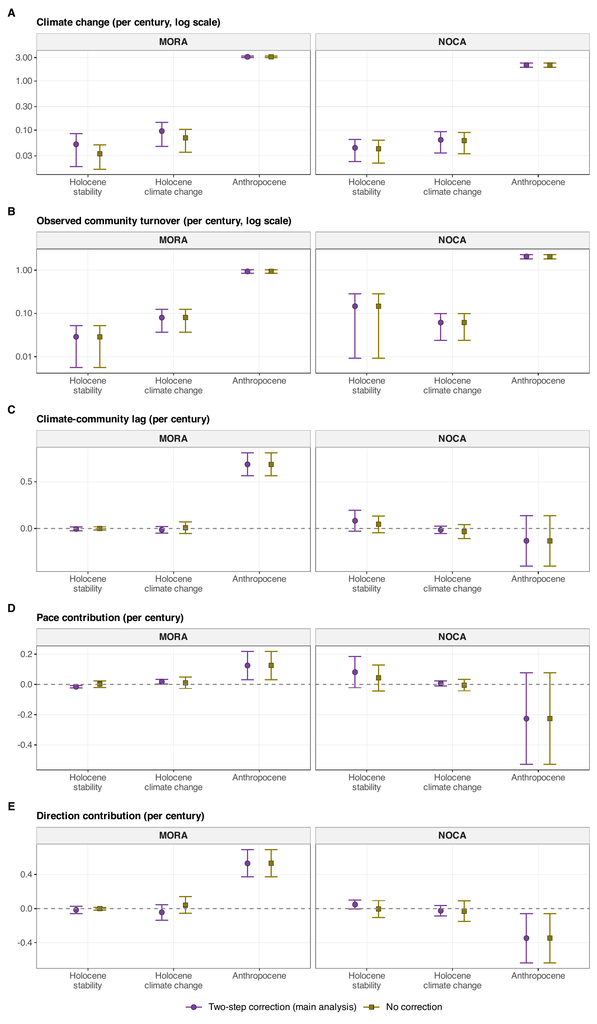

**Fig. S20. Rates of climate change, community turnover, the climate–community lag, and the pace and direction contributions by period type, with and without correction of the Holocene climate.** Estimated means with 95% confidence intervals for the Holocene stability periods, the Holocene climate-change periods and the Anthropocene plot pairs of each park, from the models of Fig. 5 fitted with each version of the Holocene climate: (A) the climate change rate (SD of the legacy plots per century) and (B) the observed community turnover rate (CCA distance per century), both on log axes, where an interval that reaches zero or below is cut at the lower edge of the panel; (C) the lag rate, (D) the pace contribution and (E) the direction contribution, in CCA distance per century. Community turnover and every quantity of the Anthropocene are the same in the two analyses. Purple circles: two-step correction (main analysis). Olive squares: no correction. Script: `R/figures/supp_paleoclimate_sensitivity.R`.

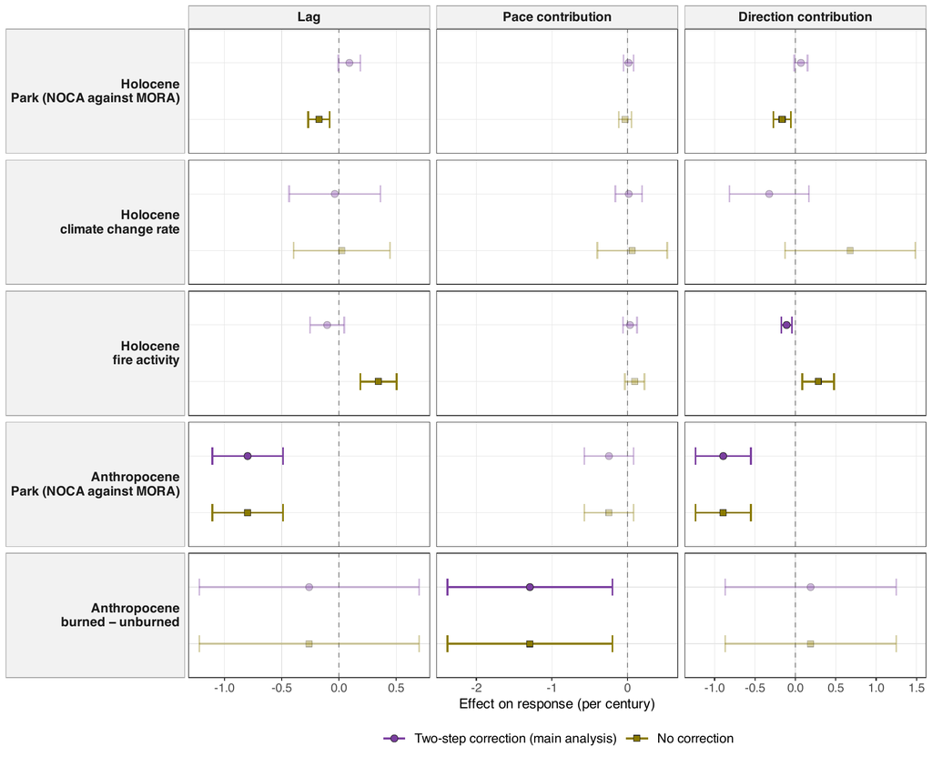

**Fig. S21. Associations with climate change and fire, with and without correction of the Holocene climate.** Coefficients of Fig. 6 with their 95% confidence intervals, from the models fitted with each version of the Holocene climate. Rows: the terms of the Holocene models of the lake-periods (park, climate change rate, fire activity) and of the Anthropocene models of the plot pairs (park, burned between the surveys), which are the same in the two analyses. Columns: the lag, the pace contribution and the direction contribution, per century. Coefficients whose interval includes zero are faded. The dashed vertical line marks zero. Purple circles: two-step correction (main analysis). Olive squares: no correction. Script: `R/figures/supp_paleoclimate_sensitivity.R`.

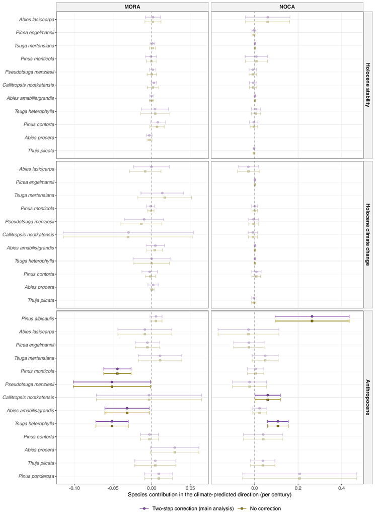

**Fig. S22. Species contributions in the climate-predicted direction, with and without correction of the Holocene climate.** Mean contribution per century of each species to the community change in the climate-predicted direction, with its 95% confidence interval, as in Fig. 7, for each park (columns) and period type (rows). Species are ordered by elevation as in Fig. 7, and species absent from a park and period type are left out. Means whose interval includes zero are faded. The dashed vertical line marks zero. The means of the Anthropocene are the same in the two analyses. Purple circles: two-step correction (main analysis). Olive squares: no correction. Script: `R/figures/supp_paleoclimate_sensitivity.R`.

# Appendix S5. Sensitivity of the results to the Anthropocene climate product

Three climate products could describe the Anthropocene climate at the forest plots, each with its advantages and disadvantages: CHELSA V2.1 (1 km), the PRISM long-term series (LT81m, 800 m; Daly et al., 2008), which uses stations with long records to keep its time series consistent, and nClimGrid (1/24°, about 5 km; Vose et al., 2014). PRISM and nClimGrid are interpolated from weather station observations, but they do not cover the Holocene. We used CHELSA V2.1 in the main analysis, because the Holocene climate comes from the same product line (CHELSA-TraCE21k), so that the climates of the two eras are more comparable. To be fully transparent, we nevertheless repeated all analyses with each of the other two products as the Anthropocene climate. Each product replaced V2.1 at the same plots, survey windows and months. The Holocene climate is corrected to the level of each product in the same two steps as in the main analysis (Appendix S2): step 1, from CHELSA-TraCE21k to CHELSAcruts, is the same for all products, and step 2 goes from CHELSAcruts to the product, over the same grid cells within 5 km of the lakes and the same years (1979 to 2016). For PRISM, we used its monthly mean temperature, which PRISM calculates as the mean of the minimum and maximum temperature, as in the main analysis. The climate–community space is fitted on the climate of the legacy plots, so the climate product can change every result: the CCA, the positions of all communities, the climate periods, the lags and the two contributions, the differences between period types, the associations with climate change and fire, and the species contributions. `R/sensitivity_climate_products.R` reruns stages 08 to 16 for each product into `output_climate_sensitivity/` and leaves the main outputs untouched. The numbers below are read from the tables that the script writes to `output_climate_sensitivity/comparison/`.

**Table S25. Climate of the Anthropocene plot pairs with the three climate products.** Median over the plot pairs of each park (interquartile range in brackets) of the climate at the legacy survey (1979 to 1989), at the resurvey (the six years up to the resurvey of each plot), and of the change at each plot pair (the legacy value subtracted from the resurvey value). The change in percent is the median of the change of each plot pair relative to its legacy value. The median change is not the difference of the two medians.

| Park | Variable | Product | Legacy survey | Resurvey | Change at the plot pairs | Change (%) |
| --- | --- | --- | --- | --- | --- | --- |
| MORA | Spring temperature (°C) | CHELSA V2.1 | 3.32 (1.88 to 4.87) | 3.77 (2.45 to 5.36) | 0.37 (0.23 to 0.81) |  |
| MORA | Spring temperature (°C) | PRISM | 4.06 (2.79 to 5.29) | 4.15 (3.08 to 5.53) | 0.08 (−0.14 to 0.45) |  |
| MORA | Spring temperature (°C) | nClimGrid | 3.79 (2.98 to 4.82) | 3.52 (2.60 to 4.68) | −0.41 (−0.46 to 0.05) |  |
| MORA | Summer precipitation (mm) | CHELSA V2.1 | 204 (173 to 258) | 150 (132 to 187) | −52 (−63 to −37) | −23.3 |
| MORA | Summer precipitation (mm) | PRISM | 173 (138 to 212) | 154 (117 to 184) | −21 (−27 to −15) | −12.8 |
| MORA | Summer precipitation (mm) | nClimGrid | 181 (137 to 227) | 170 (130 to 211) | −8 (−11 to −5) | −5.5 |
| NOCA | Spring temperature (°C) | CHELSA V2.1 | 3.61 (0.77 to 5.84) | 3.94 (0.86 to 6.02) | 0.22 (−0.24 to 0.52) |  |
| NOCA | Spring temperature (°C) | PRISM | 4.73 (2.48 to 7.02) | 4.00 (1.98 to 6.50) | −0.54 (−0.89 to −0.35) |  |
| NOCA | Spring temperature (°C) | nClimGrid | 5.38 (3.37 to 7.49) | 5.07 (3.04 to 7.10) | −0.13 (−0.22 to −0.05) |  |
| NOCA | Summer precipitation (mm) | CHELSA V2.1 | 126 (109 to 166) | 163 (139 to 205) | 16 (5 to 58) | 13.5 |
| NOCA | Summer precipitation (mm) | PRISM | 139 (114 to 174) | 129 (113 to 157) | −10 (−17 to 3) | −5.9 |
| NOCA | Summer precipitation (mm) | nClimGrid | 133 (113 to 151) | 132 (120 to 151) | 5 (−4 to 11) | 3.3 |

<sub>Table file: appendix_s5_plot_climate.csv</sub>

**Table S26. Step 2 of the bias correction with the climate products.** The correction from CHELSAcruts to each product, to whose level the Holocene climate was corrected, over 1979 to 2016, on the grid cells within 5 km of the lakes, shown for the two climate variables of the climate–community space: the mean offset of the spring (March to May) mean temperature and the ratio of the summer (June to August) precipitation sums. Step 1, from CHELSA-TraCE21k to CHELSAcruts, is the same for all products (Table S5, Fig. S7).

| Park | Product | Spring temperature offset (°C) | Summer precipitation ratio |
| --- | --- | --- | --- |
| MORA | CHELSA V2.1 | −1.43 | 1.56 |
| MORA | PRISM | 0.04 | 1.20 |
| MORA | nClimGrid | −0.15 | 1.16 |
| NOCA | CHELSA V2.1 | −1.48 | 1.32 |
| NOCA | PRISM | −0.22 | 1.37 |
| NOCA | nClimGrid | 1.23 | 1.41 |

<sub>Table file: appendix_s5_step2.csv</sub>

**Climate of the plot pairs.** The median change of the spring mean temperature at the plot pairs was 0.37 °C at MORA and 0.22 °C at NOCA with CHELSA V2.1, 0.08 °C at MORA and −0.54 °C at NOCA with PRISM and −0.41 °C at MORA and −0.13 °C at NOCA with nClimGrid. The median change of the summer precipitation was −23.3% at MORA and 13.5% at NOCA with CHELSA V2.1, −12.8% at MORA and −5.9% at NOCA with PRISM and −5.5% at MORA and 3.3% at NOCA with nClimGrid (Table S25, Fig. S23).

**Climate periods and lake-periods.** All three products gave the same 10 climate periods (Fig. S24) and the same 23 lake-periods.

**Climate–community space.** The two climate variables explained 13.8% of the inertia of the legacy communities with CHELSA V2.1, and 11.2% with PRISM and 6.8% with nClimGrid (Fig. S25).

**Differences between the Anthropocene and the Holocene.** Of the 22 differences between the Anthropocene and the Holocene that were significant in the main analysis, 16 stayed significant with the same sign with PRISM and 12 with nClimGrid (Tables S16 and S27, Fig. S26). With PRISM, climate change not divided by time at MORA (Anthropocene against Holocene climate-change periods), the lag not divided by time at MORA (Anthropocene against both Holocene period types), and the direction contribution per century at MORA (Anthropocene against both Holocene period types) kept their sign but were no longer significant. Climate change not divided by time at NOCA (Anthropocene against Holocene climate-change periods) changed sign but was not significant. With nClimGrid, the lag not divided by time at MORA (Anthropocene against both Holocene period types), the pace contribution per century and not divided by time at MORA (Anthropocene against Holocene stability periods), and the direction contribution per century at MORA (Anthropocene against both Holocene period types) kept their sign but were no longer significant. Climate change not divided by time at MORA and NOCA (Anthropocene against both Holocene period types) changed sign but were not significant. With PRISM, the pace contribution per century at MORA (Anthropocene against Holocene climate-change periods), the direction contribution per century at NOCA (Anthropocene against Holocene climate-change periods), and the direction contribution not divided by time at NOCA (Anthropocene against Holocene stability periods) were significant, unlike in the main analysis. With nClimGrid, the pace contribution per century at NOCA (Anthropocene against Holocene stability periods) and the direction contribution per century at NOCA (Anthropocene against Holocene climate-change periods) were significant, unlike in the main analysis.

**Differences within the Holocene.** Of the three differences between the climate-change and the stability periods that were significant in the main analysis (the pace contribution per century and not divided by time at MORA, and the direction contribution per century at NOCA), all three stayed significant with the same sign with PRISM and one with nClimGrid (Tables S16 and S27, Fig. S26). With nClimGrid, the pace contribution not divided by time at MORA and the direction contribution per century at NOCA kept their sign but were no longer significant. No other difference between the climate-change and the stability periods was significant with PRISM or with nClimGrid.

**Associations with climate change and fire.** Of the three coefficients of climate change, fire activity, and burning whose 95% confidence intervals excluded zero in the main analysis (fire activity on the direction contribution per century, and burning between the surveys on the pace contribution per century and not divided by time), two still excluded zero with the same sign with PRISM and two with nClimGrid (Fig. S27). With PRISM, fire activity on the direction contribution per century (−0.11 in the main analysis, −0.08 with PRISM) kept its sign but its interval no longer excluded zero. With nClimGrid, fire activity on the direction contribution per century (−0.11 in the main analysis, +0.001 with nClimGrid) changed sign, with an interval that included zero. With PRISM, fire activity on the pace contribution per century (+0.03 in the main analysis, +0.10 with PRISM), burning between the surveys on the lag per century (−0.26 in the main analysis, −1.40 with PRISM), and burning between the surveys on the lag not divided by time (−0.07 in the main analysis, −0.40 with PRISM) had intervals that excluded zero, unlike in the main analysis. With nClimGrid, burning between the surveys on the lag per century (−0.26 in the main analysis, −1.47 with nClimGrid) and burning between the surveys on the lag not divided by time (−0.07 in the main analysis, −0.42 with nClimGrid) had intervals that excluded zero, unlike in the main analysis. With PRISM, the climate change rate on the pace contribution per century (+0.02 in the main analysis, −0.07 with PRISM), climate change on the pace contribution not divided by time (+0.11 in the main analysis, −0.09 with PRISM), burning between the surveys on the direction contribution per century (+0.19 in the main analysis, −0.62 with PRISM), and burning between the surveys on the direction contribution not divided by time (+0.05 in the main analysis, −0.18 with PRISM) changed sign, with intervals that included zero in both analyses. With nClimGrid, the climate change rate on the lag per century (−0.04 in the main analysis, +0.07 with nClimGrid), the climate change rate on the direction contribution per century (−0.32 in the main analysis, +0.03 with nClimGrid), climate change on the pace contribution not divided by time (+0.11 in the main analysis, −0.10 with nClimGrid), fire activity on the lag per century (−0.10 in the main analysis, +0.06 with nClimGrid), fire activity on the lag not divided by time (−0.34 in the main analysis, +0.05 with nClimGrid), fire activity on the direction contribution not divided by time (−0.39 in the main analysis, +0.16 with nClimGrid), burning between the surveys on the direction contribution per century (+0.19 in the main analysis, −0.68 with nClimGrid), and burning between the surveys on the direction contribution not divided by time (+0.05 in the main analysis, −0.19 with nClimGrid) changed sign, with intervals that included zero in both analyses.

**Species contributions.** Of the seven species means whose 95% confidence intervals excluded zero in the main analysis, three still excluded zero with the same sign with PRISM and four with nClimGrid (Fig. S28). With PRISM, *Pseudotsuga menziesii* at MORA in the Anthropocene (−0.05 in the main analysis, −0.04 with PRISM) kept its sign but its interval no longer excluded zero. *Callitropsis nootkatensis* at NOCA in the Anthropocene (+0.06 in the main analysis, −0.004 with PRISM) changed sign, with an interval that included zero. *Pinus albicaulis* at NOCA in the Anthropocene (+0.26 in the main analysis, −0.13 with PRISM) and *Tsuga heterophylla* at NOCA in the Anthropocene (+0.11 in the main analysis, −0.09 with PRISM) changed sign, with intervals that excluded zero in the opposite direction. With nClimGrid, *Tsuga heterophylla* at NOCA in the Anthropocene (+0.11 in the main analysis, +0.002 with nClimGrid) kept its sign but its interval no longer excluded zero. *Abies amabilis/grandis* at MORA in the Anthropocene (−0.03 in the main analysis, +0.002 with nClimGrid) and *Pseudotsuga menziesii* at MORA in the Anthropocene (−0.05 in the main analysis, +0.04 with nClimGrid) changed sign, with intervals that included zero. With PRISM, *Abies procera* at MORA in the Anthropocene (+0.03 in the main analysis, +0.02 with PRISM) had an interval that excluded zero, unlike in the main analysis. With nClimGrid, *Picea engelmannii* at NOCA in the Anthropocene (−0.03 in the main analysis, −0.13 with nClimGrid) had an interval that excluded zero and *Tsuga mertensiana* at NOCA in the Anthropocene (+0.05 in the main analysis, −0.05 with nClimGrid) had an interval that excluded zero with the opposite sign, unlike in the main analysis. Of the other species means, whose intervals included zero in both analyses, 7 changed sign with PRISM and 10 with nClimGrid.

**Results that hold.** Significant with the same sign with all three products: climate change per century at MORA and NOCA (Anthropocene against both Holocene period types); community turnover per century at MORA and NOCA (Anthropocene against both Holocene period types); community turnover not divided by time at NOCA (Anthropocene against Holocene climate-change periods); the lag per century at MORA (Anthropocene against both Holocene period types); the pace contribution per century at MORA (Holocene climate-change against stability periods); the direction contribution per century at NOCA (Anthropocene against Holocene stability periods). Coefficients of climate change, fire activity, and burning whose interval excluded zero with the same sign with all three products: burning between the surveys on the pace contribution per century and not divided by time. Species means whose interval excluded zero with the same sign with all three products: *Pinus monticola* at MORA in the Anthropocene; *Tsuga heterophylla* at MORA in the Anthropocene.

**Table S27. Differences between period types whose significance differs between the climate products.** The difference between the estimated means of two period types within a park (Table S16 for the main analysis) with its Holm-adjusted p in brackets, for each difference that was significant (p < 0.05) with one product and not with another, or that changed sign. Climate change is in SD of the legacy plots, the other quantities in CCA distance or in CCA distance per century.

[output not shown]

<sub>Table file: appendix_s5_era_contrasts.csv</sub>

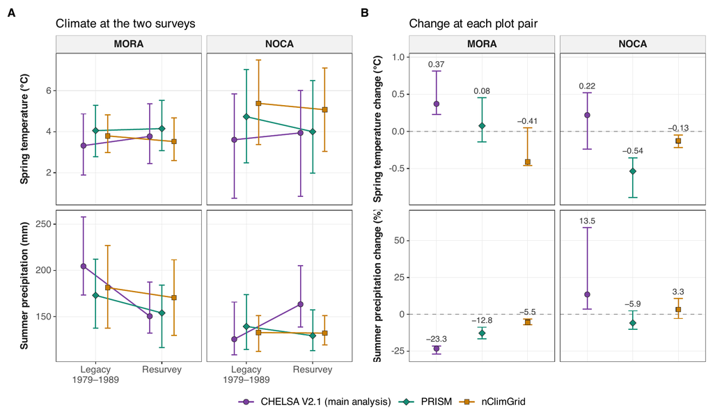

**Fig. S23. Climate of the Anthropocene plot pairs with the three climate products.** (A) Median over the plot pairs of each park of the spring mean temperature (°C) and the summer precipitation (mm) at the legacy survey (1979 to 1989) and at the resurvey (the six years up to the resurvey of each plot), with the interquartile range. (B) Median over the plot pairs of the change at each plot pair (the legacy value subtracted from the resurvey value; precipitation in percent of the legacy value), with the interquartile range and the median printed above. Purple circles: CHELSA V2.1 (main analysis). Green diamonds: PRISM. Orange squares: nClimGrid. Script: `R/figures/supp_climate_product_sensitivity.R`.

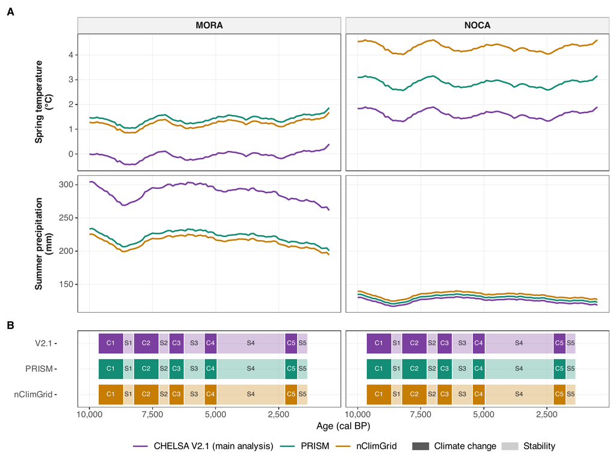

**Fig. S24. Holocene climate and climate periods with the three climate products.** (A) Spring mean temperature (°C) and summer precipitation (mm) of CHELSA-TraCE21k at the lakes of each park (MORA: mean of its three lakes), corrected to the level of each product in two steps, as the centred 1,000-year running mean of the centennial time steps, from 10,500 to 500 cal BP. (B) The climate periods drawn with each product from the regional series of Fig. 3: climate-change periods (C) in full colour and stability periods (S) in light colour. The periods are the same for both parks and are repeated under each. Purple: CHELSA V2.1 (main analysis). Green: PRISM. Orange: nClimGrid. Script: `R/figures/supp_climate_product_sensitivity.R`.

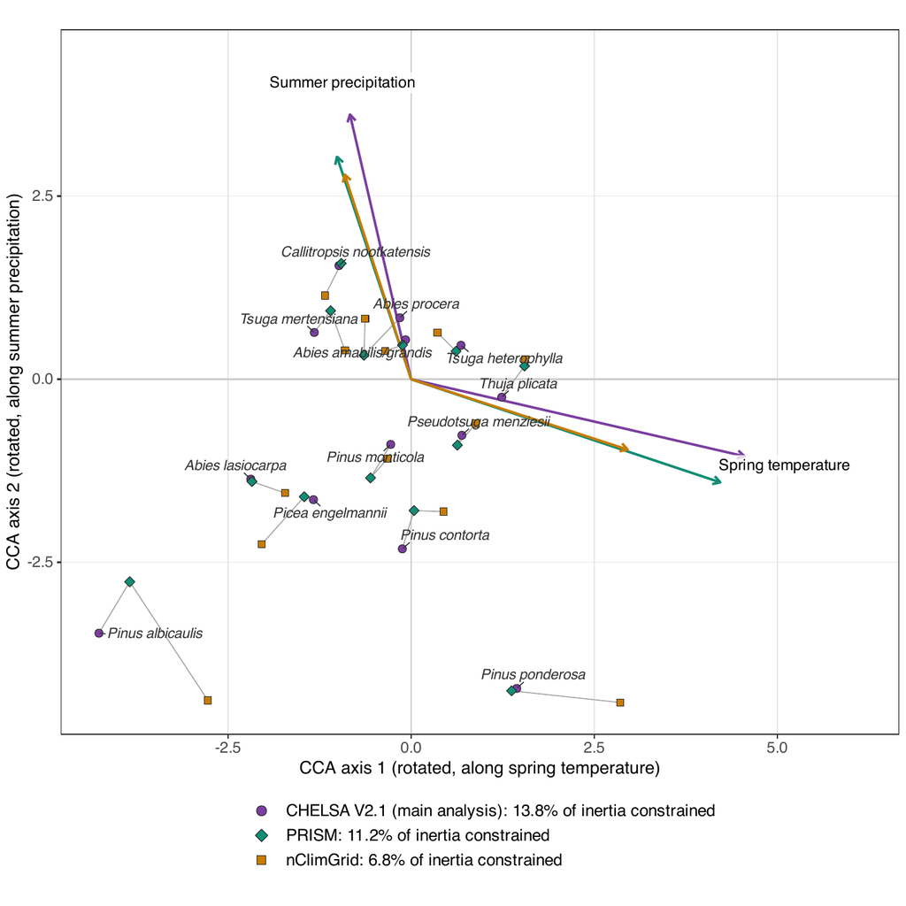

**Fig. S25. The climate–community space with the three climate products.** Scores of the tree species (points, scaling 1) and biplot arrows of spring temperature and summer precipitation in the CCA fitted with each product, each in its own display rotation, so that axis 1 runs along spring temperature and axis 2 along summer precipitation as in Fig. 4. Grey lines join the scores of one species in the analyses with the different products. Species names are placed at their scores with CHELSA V2.1. The arrows are scaled together, so that their lengths compare across the products. The legend gives the share of the total inertia that the two climate variables explain with each product. Purple circles: CHELSA V2.1 (main analysis). Green diamonds: PRISM. Orange squares: nClimGrid. Script: `R/figures/supp_climate_product_sensitivity.R`.